# SURVIVAL IN KIDNEY AND BLADDER CANCERS IN THE NORDIC COUNTRIES THROUGH A HALF CENTURY

Full R code

To see the code, click on the *Show the code*

# 1 Package upload

```r
rm(list = ls())
suppressWarnings(suppressMessages( {
  library(brms)
  library(stringr)
  library(dplyr)
  library(ggplot2)
  library(sessioninfo)
  } ) )
```

# 2 Incidence and mortality

## 2.1 Data upload and wrangling

```r
# setting parameters for smoothing
spar = 0.4
knot = 12

# colors ---------------------------------------------------------

cola <- c(
  rgb(1, 0.1, 0.1, alpha = 1),
  rgb(0.1, 0.1, 1, alpha = 1),
  rgb(0, 0.6, 0.3, alpha = 1),
  rgb(0.7, 0.7, 0.1, alpha = 1))

colb<-c(
  rgb(1, 0.1, 0.1, alpha = 0.2),
  rgb(0.1, 0.1, 1, alpha = 0.2),
  rgb(0, 0.6, 0.3, alpha = 0.2),
  rgb(0.7, 0.7, 0.1, alpha = 0.2))

colc<-c(
  rgb(1, 0.1, 0.1, alpha = 0.8),
  rgb(0.1, 0.1, 1, alpha = 0.8),
  rgb(0, 0.6, 0.3, alpha = 0.8),
  rgb(0.7, 0.7, 0.1, alpha = 0.8))


# kidney data
urlfile="https://raw.githubusercontent.com/filip-tichanek/nord_kidney/main/source/kidney_inc_mor.csv"
kidney_inc_mor <- read.csv(url(urlfile),sep=",")
colnam<-kidney_inc_mor[,1]
kidney_inc_mor<-data.frame(t(kidney_inc_mor))[-1, ]
colnames(kidney_inc_mor) <- colnam
kidney_inc_mor$year <- 1943:2020

### Subseting years 1961-2020
kidney_inc_mor <- kidney_inc_mor[kidney_inc_mor$year > 1960, ]
kidney_inc_mor[1:4, 1:4]
```

```
      Denmark, incidence, males Finland, incidence, males
X1961                       6.1                       3.5
X1962                       5.3                       3.6
X1963                       6.1                       4.0
X1964                       6.2                       4.7
      Norway, incidence, males Sweden, incidence, males
X1961                      5.4                      7.1
X1962                      4.8                      7.9
X1963                      5.0                      6.7
X1964                      5.1                      7.7
```

```r
### Removing space character and converting characters to numbers
for(x in 1:dim(kidney_inc_mor)[2]){
kidney_inc_mor[,x] <- str_trim(kidney_inc_mor[,x])
kidney_inc_mor[,x] <- as.numeric(kidney_inc_mor[,x]) }
summary(kidney_inc_mor)
```

```
 Denmark, incidence, males Finland, incidence, males Norway, incidence, males
 Min.   : 5.300            Min.   : 3.500            Min.   : 4.800
 1st Qu.: 7.200            1st Qu.: 7.200            1st Qu.: 6.600
 Median : 7.650            Median : 9.750            Median : 8.200
 Mean   : 8.408            Mean   : 8.972            Mean   : 8.665
 3rd Qu.: 8.925            3rd Qu.:10.925            3rd Qu.:10.025
 Max.   :13.200            Max.   :11.900            Max.   :13.700

 Sweden, incidence, males Denmark, incidence, females
 Min.   : 6.200           Min.   :3.400
 1st Qu.: 7.475           1st Qu.:4.400
 Median : 8.450           Median :4.800
 Mean   : 8.453           Mean   :4.777
 3rd Qu.: 9.300           3rd Qu.:5.200
 Max.   :10.400           Max.   :6.200

 Finland, incidence, females Norway, incidence, females
 Min.   :3.00                Min.   :2.700
 1st Qu.:4.20                1st Qu.:3.900
 Median :5.65                Median :4.350
 Mean   :5.28                Mean   :4.518
 3rd Qu.:6.10                3rd Qu.:5.125
 Max.   :6.80                Max.   :7.100

 Sweden, incidence, females Denmark, mortality, males Finland, mortality, males
 Min.   :3.400              Min.   :2.200             Min.   :2.500
 1st Qu.:4.500              1st Qu.:3.650             1st Qu.:3.500
 Median :5.150              Median :4.400             Median :4.150
 Mean   :5.083              Mean   :4.169             Mean   :4.123
 3rd Qu.:5.700              3rd Qu.:4.700             3rd Qu.:4.800
 Max.   :6.600              Max.   :5.500             Max.   :5.500
                            NA's   :1
 Norway, mortality, males Sweden, mortality, males Denmark, mortality, females
 Min.   :2.600            Min.   :2.300            Min.   :0.930
 1st Qu.:3.500            1st Qu.:3.700            1st Qu.:1.850
 Median :3.800            Median :4.650            Median :2.800
 Mean   :3.812            Mean   :4.448            Mean   :2.566
 3rd Qu.:4.200            3rd Qu.:5.425            3rd Qu.:3.100
 Max.   :5.200            Max.   :6.400            Max.   :4.200
                                                   NA's   :1
 Finland, mortality, females Norway, mortality, females
 Min.   :1.300               Min.   :1.000
 1st Qu.:1.900               1st Qu.:1.500
 Median :2.200               Median :2.000
 Mean   :2.157               Mean   :1.872
 3rd Qu.:2.400               3rd Qu.:2.200
 Max.   :2.900               Max.   :2.500

 Sweden, mortality, females      year
 Min.   :1.100              Min.   :1961
 1st Qu.:2.100              1st Qu.:1976
 Median :2.800              Median :1990
 Mean   :2.587              Mean   :1990
 3rd Qu.:3.300              3rd Qu.:2005
 Max.   :3.700              Max.   :2020
```

```r
# bladder data
urlfile="https://raw.githubusercontent.com/filip-tichanek/nord_kidney/main/source/bladder_inc_mor.csv"
bladder_inc_mor <- read.csv(url(urlfile),sep=",")
colnam <- bladder_inc_mor[,1]
bladder_inc_mor <- data.frame(t(bladder_inc_mor))[-1,]
colnames(bladder_inc_mor) <- colnam
bladder_inc_mor$year <- 1943:2020

## Subseting years 1961-2020
bladder_inc_mor <- bladder_inc_mor[bladder_inc_mor$year>1960,]
bladder_inc_mor[1:4, 1:4]
```

```
      Denmark, incidence, males Finland, incidence, males
X1961                     14.10                      7.00
X1962                     16.10                      6.60
X1963                      16.4                       8.5
X1964                      15.3                       9.1
      Norway, incidence, males Sweden, incidence, males
X1961                     9.10                     8.70
X1962                     9.90                     9.50
X1963                     10.6                     10.2
X1964                     12.1                      9.8
```

```r
## Removing space character and converting characters to numbers
for (x in 1:dim(kidney_inc_mor)[2]){
  bladder_inc_mor[,x] <- str_trim(bladder_inc_mor[,x])
  bladder_inc_mor[,x] <- as.numeric(bladder_inc_mor[,x]) }
summary(bladder_inc_mor)
```

```
 Denmark, incidence, males Finland, incidence, males Norway, incidence, males
 Min.   :14.10             Min.   : 6.60             Min.   : 9.10
 1st Qu.:24.50             1st Qu.:13.78             1st Qu.:17.15
 Median :27.70             Median :15.15             Median :20.20
 Mean   :26.37             Mean   :14.37             Mean   :18.68
 3rd Qu.:29.00             3rd Qu.:15.85             3rd Qu.:21.40
 Max.   :31.90             Max.   :18.30             Max.   :23.60

 Sweden, incidence, males Denmark, incidence, females
 Min.   : 8.70            Min.   :4.600
 1st Qu.:15.65            1st Qu.:6.975
 Median :18.20            Median :8.500
 Mean   :16.78            Mean   :7.943
 3rd Qu.:18.60            3rd Qu.:9.000
 Max.   :20.00            Max.   :9.800

 Finland, incidence, females Norway, incidence, females
 Min.   :1.300               Min.   :2.900
 1st Qu.:2.975               1st Qu.:4.950
 Median :3.450               Median :5.600
 Mean   :3.237               Mean   :5.458
 3rd Qu.:3.600               3rd Qu.:6.100
 Max.   :4.100               Max.   :6.900

 Sweden, incidence, females Denmark, mortality, males Finland, mortality, males
 Min.   :3.500              Min.   : 4.400            Min.   :2.900
 1st Qu.:4.700              1st Qu.: 6.900            1st Qu.:3.600
 Median :5.400              Median : 8.200            Median :4.500
 Mean   :5.212              Mean   : 8.198            Mean   :4.445
 3rd Qu.:5.725              3rd Qu.: 9.650            3rd Qu.:5.200
 Max.   :6.800              Max.   :11.400            Max.   :6.900
                            NA's   :1
 Norway, mortality, males Sweden, mortality, males Denmark, mortality, females
 Min.   :3.400            Min.   :3.600            Min.   :1.500
 1st Qu.:4.700            1st Qu.:4.300            1st Qu.:2.400
 Median :5.450            Median :4.600            Median :2.600
 Mean   :5.383            Mean   :4.587            Mean   :2.658
 3rd Qu.:6.100            3rd Qu.:4.800            3rd Qu.:3.000
 Max.   :7.000            Max.   :5.800            Max.   :3.600
                                                   NA's   :1
 Finland, mortality, females Norway, mortality, females
 Min.   :0.730               Min.   :1.200
 1st Qu.:0.920               1st Qu.:1.575
 Median :1.000               Median :1.900
 Mean   :1.073               Mean   :1.830
 3rd Qu.:1.200               3rd Qu.:2.000
 Max.   :1.900               Max.   :2.500

 Sweden, mortality, females      year
 Min.   :1.400              Min.   :1961
 1st Qu.:1.500              1st Qu.:1976
 Median :1.600              Median :1990
 Mean   :1.602              Mean   :1990
 3rd Qu.:1.700              3rd Qu.:2005
 Max.   :2.100              Max.   :2020
```

## 2.2 Plotting

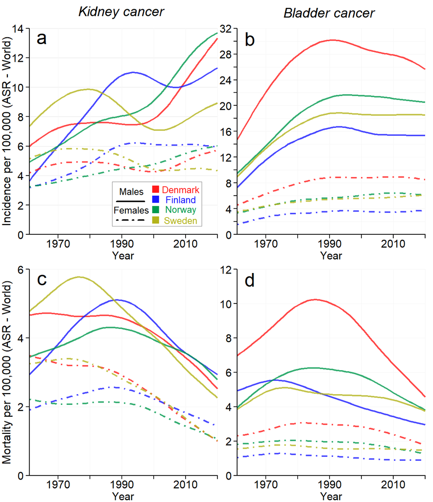

```r
## General setting and titles of plots

m <- matrix(c(9,1,2
             ,3,5,6
             ,4,7,8), nrow = 3, ncol =3 ,byrow = TRUE)
layout(mat = m,heights = c(0.04,0.96/2,0.96/2),widths = c(0.04,0.96/2,0.96/2))
par(mgp=c(1.6,0.8,0))
par(mar=c(0,0,0,0))

plot(NULL, axes = FALSE,xlab = "", ylab = "", xlim=c(-1,1), ylim = c(-0.85, 0.85))
text(0, -0.2, "Kidney cancer", cex = 1.8, font = 3, xpd=TRUE)
plot(NULL, axes=FALSE, xlab = "", ylab="", xlim = c(-1,1),ylim=c(-0.85,0.85))
text(0, -0.2, "Bladder cancer", cex = 1.8, font = 3, xpd = TRUE)

par(mar=c(2, 0, 0, 0))
plot(NULL, axes = FALSE, xlab = "", ylab = "", xlim = c(-1,1), ylim=c(0,1))
text(-0.2, 0.5, "Incidence per 100,000 (ASR - World)", cex = 1.5, srt=90)

par(mar = c(2, 0, 0, 0))
plot(NULL, axes = FALSE, xlab = "", ylab = "", xlim = c(-1, 1), ylim = c(0, 1))
text(-0.2, 0.5, "Mortality per 100,000 (ASR - World)", cex = 1.5, srt = 90)

# Kidney incidence plot

data = kidney_inc_mor
par(mgp = c(1.4, 0.6, 0))
par(mar = c(2, 0.5, 0, 0))
tckk = -0.017

range <- c(0, 14); scal <- range[2]-range[1]
xrange <- c(1961, 2020)
plot(NULL, xlim = xrange, ylim = c(range[1], range[2]), xlab="", ylab="" ,las=1, axes=FALSE)
rect(xrange[1],range[2],xrange[2],range[1],col="white", border=NA)
x <- range[1]
repeat{
  lines(c(xrange[1], xrange[2]), c(x, x),col = "grey90", lwd = 0.7)
  x=x+2;if(x>range[2]){break}}

x<- round(xrange[1]+5,-1)
repeat{
  lines(c(x,x), c(range[1],  range[2]),col= "grey96", lwd = 0.7)
  x=x+10; if(x>2020){break}}

data = kidney_inc_mor

for (xx in 1:4){
smoothingSpline = smooth.spline(data$year, data[,xx], spar=spar, nknots=knot)
lines(smoothingSpline, col= colc[xx], lty = 1, lwd = 2, lend = 1)}

for (xx in 5:8){
  smoothingSpline = smooth.spline(data$year, data[,xx], spar=spar, nknots=knot)
  lines(smoothingSpline, col = colc[xx-4], lty=4, lwd=2, lend=1) }

axis(2, las = 2, cex.axis = 1.4, at = seq(range[1], range[2], by=2),
     labels = c(rep("", length(seq(range[1], range[2], by = 2)))),
     pos = xrange[1], tck = tckk)

axis(2,las=2,cex.axis=1.4,at=seq(range[1],range[2],by=2),
     pos=xrange[1],tck=tckk)

axis(side=1,las=1,cex.axis=1.4,at=c(seq(round(xrange[1]+5,-1),2020,by=10)),pos=range[1],
     labels=c(rep("",length(c(seq(round(xrange[1]+5,-1),2020,by=10))))),tck=tckk)
lines(c(xrange[1],xrange[2]),c(range[1],range[1]))
axis(side=1,las=1,cex.axis=1.4,at=c(seq(round(xrange[1]+5,-1),2020,by=20)),
     pos=range[1],tck=tckk)
title(xlab="Year", line=1, cex.lab=1.4,xpd=TRUE)
text(1965,range[2]-0.05*scal,"a",cex=2.5)

xx=1;yy=range[1]+scal*0.22
rect(1987,yy+0.035*scal,2015,yy-0.18*scal,col="white",border="grey50",lwd=0.8)
repeat{
  lines(c(1999.5,2001.7),c(yy,yy),lwd=10,col=cola[xx],lend=1)
  xx<-xx+1;yy=yy-(scal*0.05);if(xx>4){break}}

text(1993,0.21*scal,"Males",cex=1.25)
lines(c(1988.3,1997.1),c(0.16*scal,0.16*scal),lwd=2)

text(1993,0.12*scal,"Females",cex=1.25)
lines(c(1988.3,1997.1),c(0.07*scal,0.07*scal),lwd=2,lty=4)

xx=1;yy=range[1]+scal*0.22
text(2008.5,yy,"Denmark",col=cola[xx],cex=1.25);xx=xx+1;yy=yy-(scal*0.05)
text(2008.5,yy,"Finland",col=cola[xx],cex=1.25);xx=xx+1;yy=yy-(scal*0.05)
text(2008.5,yy,"Norway",col=cola[xx],cex=1.25);xx=xx+1;yy=yy-(scal*0.05)
text(2008.5,yy,"Sweden",col=cola[xx],cex=1.25);xx=xx+1;yy=yy-(scal*0.05)

# Bladder incidence plot

data=bladder_inc_mor

range<-c(0,32);scal<-range[2]-range[1]
xrange<-c(1961,2020)

plot(NULL,xlim=xrange,ylim=c(range[1],range[2]),xlab="",ylab=""
     ,las=1, axes=FALSE)
rect(xrange[1],range[2],xrange[2],range[1],col="white",border=NA)
x<-range[1]
repeat{
  lines(c(xrange[1],xrange[2]),c(x,x),col="grey96",lwd=0.7)
  x=x+2;if(x>range[2]){break}}

x<- round(xrange[1]+5,-1)
repeat{
  lines(c(x,x),c(range[1],range[2]),col="grey96",lwd=0.7)
  x=x+10;if(x>2020){break}}

data=bladder_inc_mor
for (xx in 1:4){
  smoothingSpline = smooth.spline(data$year, data[,xx], spar=spar, nknots=knot)
  lines(smoothingSpline,col=colc[xx],lty=1,lwd=2,lend=1) }

for (xx in 5:8){
  smoothingSpline = smooth.spline(data$year, data[,xx], spar=spar, nknots=knot)
  lines(smoothingSpline,col=colc[xx-4],lty=4,lwd=2,lend=1) }

axis(2,las=2,cex.axis=1.4,at=seq(range[1],range[2],by=2),
     labels=c(rep("",length(seq(range[1],range[2],by=2)))),
     pos=xrange[1],tck=tckk)

axis(2,las=2,cex.axis=1.4,at=seq(range[1],range[2],by=4),
     pos=xrange[1],tck=tckk)

axis(side=1,las=1,cex.axis=1.4,at=c(seq(round(xrange[1]+5,-1),2020,by=10)),pos=range[1],
     labels=c(rep("",length(c(seq(round(xrange[1]+5,-1),2020,by=10))))),tck=tckk)
lines(c(xrange[1],xrange[2]),c(range[1],range[1]))
axis(side=1,las=1,cex.axis=1.4,at=c(seq(round(xrange[1]+5,-1),2020,by=20)),
     pos=range[1],tck=tckk)
title(xlab="Year", line=1, cex.lab=1.4,xpd=TRUE)

text(1965,range[2]-0.05*scal,"b",cex=2.5)


# kidney mortality

### WARNING! Due to a bug in NORDCAN database (Denmark mortality data in 1969),
### some data were removed from table (these evidently incorrect).
### The bug was reported to NORDCAN secretary on 7th of November, 2022

data=kidney_inc_mor

  range<-c(0,6);scal<-range[2]-range[1]
  xrange<-c(1961,2020)

  plot(NULL,xlim=xrange,ylim=c(range[1],range[2]),xlab="",ylab=""
       ,las=1, axes=FALSE)
  rect(xrange[1],range[2],xrange[2],range[1],col="white",border=NA)
  x<-range[1]
  repeat{
    lines(c(xrange[1],xrange[2]),c(x,x),col="grey96",lwd=0.7)
    x=x+2;if(x>range[2]){break}}

  x<- round(xrange[1]+5,-1)
  repeat{
    lines(c(x,x),c(range[1],range[2]),col="grey96",lwd=0.7)
    x=x+10;if(x>2020){break}}

for (xx in 9:12){
    data = na.omit(kidney_inc_mor[,c(xx,17)] )
    smoothingSpline = smooth.spline(data[,2], data[,1], spar=spar, nknots=knot)
    lines(smoothingSpline,col=colc[xx-8],lty=1,lwd=2,lend=1) }

for (xx in 13:16){
    data = na.omit(kidney_inc_mor[,c(xx,17)] )
    smoothingSpline = smooth.spline(data[,2], data[,1], spar=spar, nknots=knot)
      lines(smoothingSpline,col=colc[xx-12],lty=4,lwd=2,lend=1) }


  axis(2,las=2,cex.axis=1.4,at=seq(range[1],range[2],by=2),
       labels=c(rep("",length(seq(range[1],range[2],by=2)))),
       pos=xrange[1],tck=tckk)
  axis(2,las=2,cex.axis=1.4,at=seq(range[1],range[2],by=2),
       pos=xrange[1],tck=tckk)
  axis(side=1,las=1,cex.axis=1.4,at=c(seq(round(xrange[1]+5,-1),2020,by=10)),pos=range[1],
       labels=c(rep("",length(c(seq(round(xrange[1]+5,-1),2020,by=10))))),tck=tckk)
  lines(c(xrange[1],xrange[2]),c(range[1],range[1]))
  axis(side=1,las=1,cex.axis=1.4,at=c(seq(round(xrange[1]+5,-1),2020,by=20)),
       pos=range[1],tck=tckk)
  title(xlab="Year", line=1, cex.lab=1.4,xpd=TRUE)
  text(1965,range[2]-0.05*scal,"c",cex=2.5)



# bladder mortality

### WARNING! Due to a bug in NORDCAN database (Denmark mortality data in 1969),
### some data were removed from table (these evidently incorrect).
### The bug was reported to NORDCAN secretary on 7th of November, 2022

  data=bladder_inc_mor
  range<-c(0,12);scal<-range[2]-range[1]
  xrange<-c(1961,2020)

  plot(NULL,xlim=xrange,ylim=c(range[1],range[2]),xlab="",ylab=""
       ,las=1, axes=FALSE)
  rect(xrange[1],range[2],xrange[2],range[1],col="white",border=NA)
  x<-range[1]
  repeat{
    lines(c(xrange[1],xrange[2]),c(x,x),col="grey96",lwd=0.7)
    x=x+2;if(x>range[2]){break}}

x<- round(xrange[1]+5,-1)
  repeat{
    lines(c(x,x),c(range[1],range[2]),col="grey96",lwd=0.7)
    x=x+10;if(x>2020){break}}

 for (xx in 9:12){
    data= na.omit(bladder_inc_mor[,c(xx,17)] )
    smoothingSpline = smooth.spline(data[,2], data[,1], spar=spar, nknots=knot)
    lines(smoothingSpline, col=colc[xx-8],lty=1,lwd=2,lend=1) }

 for (xx in 13:16){
    data = na.omit(bladder_inc_mor[,c(xx,17)] )
    smoothingSpline = smooth.spline(data[,2], data[,1], spar=spar, nknots=knot)
    lines(smoothingSpline, col=colc[xx-12],lty=4,lwd=2,lend=1)}

  axis(2,las=2,cex.axis=1.4,at=seq(range[1],range[2],by=2),
       labels=c(rep("",length(seq(range[1],range[2],by=2)))),
       pos=xrange[1],tck=tckk)

  axis(2,las=2,cex.axis=1.4,at=seq(range[1],range[2],by=2),
       pos=xrange[1],tck=tckk)

  axis(side=1,las=1,cex.axis=1.4,at=c(seq(round(xrange[1]+5,-1),2020,by=10)),pos=range[1],
       labels=c(rep("",length(c(seq(round(xrange[1]+5,-1),2020,by=10))))),tck=tckk)
  lines(c(xrange[1],xrange[2]),c(range[1],range[1]))
  axis(side=1,las=1,cex.axis=1.4,at=c(seq(round(xrange[1]+5,-1),2020,by=20)),
       pos=range[1],tck=tckk)
  title(xlab="Year", line=1, cex.lab=1.4,xpd=TRUE)

  text(1965,range[2]-0.05*scal,"d",cex=2.5)
```

# 3 Survival trends

This code aim to time trends in the survival of kidney and bladder cancers, using Bayesian Generalized Additive Models. Data were downloaded from [NORDCAN](https://nordcan.iarc.fr/en/dataviz/survival?sexes=2&cancers=180_230_190_200_220&populations=752&mode=cancer&multiple_populations=0&multiple_cancers=1&survival=1) website.

```r
cola<-c(
  rgb(1, 0, 0, alpha=1),
  rgb(0.2,0.2,1,alpha=1),
  rgb(0, 0.7, 0,alpha=1),
  rgb(0.7,0.7,0.1,alpha=1))

alp=0.18;colb<-c(
  rgb(1, 0, 0, alpha=alp),
  rgb(0.2, 0.2, 1, alpha=alp),
  rgb(0, 0.9, 0,alpha=alp),
  rgb(0.7,0.7,0.1,alpha=alp))

colc<-c(
  rgb(1,0,0,alpha=0.8),
  rgb(0.2,0.2,1,alpha=0.8),
  rgb(0, 0.9, 0,alpha=0.8),
  rgb(0.7,0.7,0.1,alpha=0.8))
```

### 3.0.1 Data upload

```r
# Kidney data upload
urlfile <- "https://raw.githubusercontent.com/filip-tichanek/nord_kidney/main/source/kidney_1y.csv"
kidney_1y <- read.csv(url(urlfile),sep=";")

urlfile <- "https://raw.githubusercontent.com/filip-tichanek/nord_kidney/main/source/kidney_5y.csv"
kidney_5y <- read.csv(url(urlfile),sep=";")

# Bladder data upload
urlfile <- "https://raw.githubusercontent.com/filip-tichanek/nord_kidney/main/source/bladder_1y.csv"
bladder_1y <- read.csv(url(urlfile),sep=";")

urlfile <- "https://raw.githubusercontent.com/filip-tichanek/nord_kidney/main/source/bladder_5y.csv"
bladder_5y <- read.csv(url(urlfile),sep=";")
```

### 3.0.2 Kidney data wrangling

```r
kidney_1y_est<-data.frame(kidney_1y[, 1])
for (x in 2:9){
  kidney_1y_est[,x] <- str_sub(kidney_1y[, x], 1, 4) }

for (x in 10:17){
  kidney_1y_est[,x]<-str_sub(kidney_1y[, x-8], 6, 9) }

kidney_5y_est<-data.frame(kidney_5y[,1])
for (x in 2:9){kidney_5y_est[,x] <- str_sub(kidney_5y[,x], 1, 4) }
for (x in 10:17){kidney_5y_est[,x] <- str_sub(kidney_5y[,x-8], 6, 9) }

kidney<-(data.frame(unlist(kidney_1y_est[,2:9])));colnames(kidney)<-"surv_1y"
kidney$cil_1y<-as.numeric(unlist(kidney_1y_est[,10:17]))
kidney$surv_5y<-as.numeric(unlist(kidney_5y_est[,2:9]))
kidney$cil_5y<-as.numeric(unlist(kidney_5y_est[,10:17]))
kidney$year<-rep(seq(1973,2018,by=5),8)
kidney$sex<-c(rep("Males",40),rep("Females",40))
kidney$country<-c(rep(c(rep("Denmark",10), rep("Finland",10), rep("Norway",10),
                        rep("Sweden",10)),2))
kidney$shou<-c(rep(c(rep("den_mal_",10), rep("fin_mal_",10), rep("nor_mal_",10),
                     rep("swe_mal_",10), rep("den_fem_",10), rep("fin_fem_",10),
                     rep("nor_fem_",10), rep("swe_fem_",10)),1))
kidney$group<-interaction(kidney$country,kidney$sex)
kidney$years10cen<-(kidney$year-1995.5)/10
kidney$surv_1y<-as.numeric(kidney$surv_1y)
kidney$surv_5y<-as.numeric(kidney$surv_5y)
kidney$cil_1y<-as.numeric(kidney$cil_1y)
kidney$cil_5y<-as.numeric(kidney$cil_5y)
kidney$se_1y<-(kidney$surv_1y-kidney$cil_1y)/1.96
kidney$se_5y<-(kidney$surv_5y-kidney$cil_5y)/1.96
kidney$surv_cond<-(kidney$surv_5y/kidney$surv_1y)*100
summary(kidney)
```

```
    surv_1y          cil_1y         surv_5y          cil_5y           year
 Min.   :47.60   Min.   :44.30   Min.   :27.00   Min.   :23.50   Min.   :1973
 1st Qu.:59.10   1st Qu.:55.27   1st Qu.:38.42   1st Qu.:35.25   1st Qu.:1983
 Median :70.50   Median :67.60   Median :50.80   Median :47.80   Median :1996
 Mean   :69.72   Mean   :67.18   Mean   :52.05   Mean   :48.99   Mean   :1996
 3rd Qu.:80.00   3rd Qu.:78.17   3rd Qu.:64.20   3rd Qu.:61.58   3rd Qu.:2008
 Max.   :91.30   Max.   :90.20   Max.   :80.00   Max.   :77.10   Max.   :2018

     sex              country              shou                       group
 Length:80          Length:80          Length:80          Denmark.Females:10
 Class :character   Class :character   Class :character   Finland.Females:10
 Mode  :character   Mode  :character   Mode  :character   Norway.Females :10
                                                          Sweden.Females :10
                                                          Denmark.Males  :10
                                                          Finland.Males  :10
                                                          (Other)        :20
   years10cen        se_1y            se_5y          surv_cond
 Min.   :-2.25   Min.   :0.5612   Min.   :0.9694   Min.   :50.90
 1st Qu.:-1.25   1st Qu.:1.0077   1st Qu.:1.3138   1st Qu.:66.07
 Median : 0.00   Median :1.1990   Median :1.5306   Median :73.06
 Mean   : 0.00   Mean   :1.2959   Mean   :1.5593   Mean   :73.07
 3rd Qu.: 1.25   3rd Qu.:1.5816   3rd Qu.:1.7347   3rd Qu.:81.28
 Max.   : 2.25   Max.   :2.4490   Max.   :2.5000   Max.   :89.15
```

### 3.0.3 Bladder data wrangling

```r
x<-2;bladder_1y_est<-data.frame(bladder_1y[,1])
for(x in 2:9){bladder_1y_est[,x] <- str_sub(bladder_1y[,x], 1, 4) }
for(x in 10:17){bladder_1y_est[,x] <- str_sub(bladder_1y[,x-8], 6, 9) }
bladder_5y_est<-data.frame(bladder_5y[,1])
for(x in 2:9){bladder_5y_est[,x] <- str_sub(bladder_5y[,x], 1, 4) }
for(x in 10:17){bladder_5y_est[,x] <- str_sub(bladder_5y[,x-8], 6, 9) }

bladder<-(data.frame(unlist(bladder_1y_est[,2:9])));colnames(bladder)<-"surv_1y"
bladder$cil_1y<-as.numeric(unlist(bladder_1y_est[,10:17]))
bladder$surv_5y<-as.numeric(unlist(bladder_5y_est[,2:9]))
bladder$cil_5y<-as.numeric(unlist(bladder_5y_est[,10:17]))
bladder$year<-rep(seq(1973,2018,by=5),8)
bladder$sex<-c(rep("Males",40),rep("Females",40))
bladder$country<-c(rep(c(rep("Denmark",10),rep("Finland",10),rep("Norway",10),
                         rep("Sweden",10)),2))
bladder$shou<-c(rep(c(rep("den_mal_",10),rep("fin_mal_",10),rep("nor_mal_",10),
                      rep("swe_mal_",10),rep("den_fem_",10),rep("fin_fem_",10),
                      rep("nor_fem_",10),rep("swe_fem_",10)),1))
bladder$group<-interaction(bladder$country,bladder$sex)
bladder$years10cen<-(bladder$year-1995.5)/10
bladder$surv_1y<-as.numeric(bladder$surv_1y)
bladder$surv_5y<-as.numeric(bladder$surv_5y)
bladder$cil_1y<-as.numeric(bladder$cil_1y)
bladder$cil_5y<-as.numeric(bladder$cil_5y)
bladder$se_1y<-(bladder$surv_1y-bladder$cil_1y)/1.96
bladder$se_5y<-(bladder$surv_5y-bladder$cil_5y)/1.96
bladder$surv_cond<-(bladder$surv_5y/bladder$surv_1y)*100
summary(bladder)
```

```
    surv_1y          cil_1y         surv_5y          cil_5y           year
 Min.   :71.30   Min.   :68.70   Min.   :48.60   Min.   :43.60   Min.   :1973
 1st Qu.:80.45   1st Qu.:78.53   1st Qu.:63.92   1st Qu.:61.02   1st Qu.:1983
 Median :84.75   Median :83.10   Median :69.90   Median :67.80   Median :1996
 Mean   :83.75   Mean   :82.14   Mean   :68.45   Mean   :66.11   Mean   :1996
 3rd Qu.:87.90   3rd Qu.:86.65   3rd Qu.:74.58   3rd Qu.:72.33   3rd Qu.:2008
 Max.   :92.40   Max.   :91.80   Max.   :81.60   Max.   :80.60   Max.   :2018

     sex              country              shou                       group
 Length:80          Length:80          Length:80          Denmark.Females:10
 Class :character   Class :character   Class :character   Finland.Females:10
 Mode  :character   Mode  :character   Mode  :character   Norway.Females :10
                                                          Sweden.Females :10
                                                          Denmark.Males  :10
                                                          Finland.Males  :10
                                                          (Other)        :20
   years10cen        se_1y            se_5y          surv_cond
 Min.   :-2.25   Min.   :0.3061   Min.   :0.5102   Min.   :64.86
 1st Qu.:-1.25   1st Qu.:0.5612   1st Qu.:0.8673   1st Qu.:78.75
 Median : 0.00   Median :0.7653   Median :1.1224   Median :82.82
 Mean   : 0.00   Mean   :0.8202   Mean   :1.1926   Mean   :81.48
 3rd Qu.: 1.25   3rd Qu.:1.0204   3rd Qu.:1.4286   3rd Qu.:85.23
 Max.   : 2.25   Max.   :2.0408   Max.   :2.5510   Max.   :88.91
```

## 3.1 Modelling of survival trends

### 3.1.1 Prior probabilities specification

```r
prior_group <- c(
set_prior("normal(0,30)", class = "b", coef = "groupFinland.Males"),
set_prior("normal(0,30)", class = "b", coef = "groupNorway.Males"),
set_prior("normal(0,30)", class = "b", coef = "groupSweden.Males"),
set_prior("normal(0,30)", class = "b", coef = "groupDenmark.Males"),
set_prior("normal(0,30)", class = "b", coef = "groupNorway.Females"),
set_prior("normal(0,30)", class = "b", coef = "groupFinland.Females"),
set_prior("normal(0,30)", class = "b", coef = "groupSweden.Females"))
```

### 3.1.2 Fitting models of kidney survival

```r
set.seed(17)
kidney_1y_model <- brm(surv_1y|se(se_1y) ~ group + s(years10cen, by=group, k=5),
                       family="Gaussian",
                       prior = prior_group,
                       data = kidney, seed = 17,
                       iter = 7000, warmup = 2000, chains = 2, cores = 1,
                       control = list(adapt_delta = 0.98),
                       save_pars = save_pars(all = TRUE))

kidney_5y_model <- brm(surv_5y|se(se_5y) ~ group + s(years10cen, by=group, k=5),
                       family="Gaussian",
                       prior = prior_group,
                       data = kidney, seed = 17,
                       iter = 7000, warmup = 2000, chains = 2, cores = 1,
                       control = list(adapt_delta = 0.98),
                       save_pars = save_pars(all = TRUE))
```

### 3.1.3 Fitting models of bladder cancer

```r
set.seed(17)
bladder_1y_model <- brm(surv_1y|se(se_1y) ~ group + s(years10cen, by=group,k=5),
                       family="Gaussian",
                       prior = prior_group,
                       data = bladder, seed = 17,
                       iter = 7000, warmup = 2000, chains = 2, cores = 1,
                       control = list(adapt_delta = 0.98),
                       save_pars = save_pars(all = TRUE))

bladder_5y_model <- brm(surv_5y|se(se_5y) ~ group + s(years10cen, by=group,k=5),
                       family="Gaussian",
                       prior = prior_group,
                       data = bladder, seed = 17,
                       iter = 7000, warmup = 2000, chains = 2, cores = 1,
                       control = list(adapt_delta = 0.98),
                       save_pars = save_pars(all = TRUE))
```

### 3.1.4 Diagnostics

Checking effective sample size of posterior samples, convergence of the models and posterior predictive check (PPC)

In general, diagnostics uses:

(i) *summary(model)*: the columns of intereste are *Rhat* (when = 1, model converged well), and columns *Tail_ESS* and *Bulk_ESS* which should never go under 1,000 and should be mostly above 2,000.

[2] *pp_check* : graphical tools to explore how well the model predicts real data, as thoroughly described by Gelman [here](http://www.stat.columbia.edu/~gelman/book/). Ideally, there should not be strong discrepancy between the model prediction and the distribution of the real dataset.

You can use also *plot(model)* to see convergence of chains graphically and to explore posterior distribution of parameters, estimated via the models

Finally, we will also use a function *prior_summary* to explore the prior probabilities set

#### 3.1.4.1 Kidney 1y model

```r
summary(kidney_1y_model)
```

```
 Family: gaussian
  Links: mu = identity; sigma = identity
Formula: surv_1y | se(se_1y) ~ group + s(years10cen, by = group, k = 5)
   Data: kidney (Number of observations: 80)
  Draws: 2 chains, each with iter = 7000; warmup = 2000; thin = 1;
         total post-warmup draws = 10000

Smooth Terms:
                                       Estimate Est.Error l-95% CI u-95% CI
sds(syears10cengroupDenmark.Females_1)    23.71     10.95    10.23    50.26
sds(syears10cengroupFinland.Females_1)    10.96      6.53     2.99    28.12
sds(syears10cengroupNorway.Females_1)     11.11      7.32     1.58    29.40
sds(syears10cengroupSweden.Females_1)      8.03      7.95     0.20    28.21
sds(syears10cengroupDenmark.Males_1)      18.94      8.99     8.14    41.57
sds(syears10cengroupFinland.Males_1)      32.99     15.28    12.36    69.80
sds(syears10cengroupNorway.Males_1)       12.19      7.25     3.42    30.45
sds(syears10cengroupSweden.Males_1)       25.99     13.20     9.12    56.59
                                       Rhat Bulk_ESS Tail_ESS
sds(syears10cengroupDenmark.Females_1) 1.00     6190     7588
sds(syears10cengroupFinland.Females_1) 1.00     6205     5677
sds(syears10cengroupNorway.Females_1)  1.00     4691     4504
sds(syears10cengroupSweden.Females_1)  1.00     2479     4234
sds(syears10cengroupDenmark.Males_1)   1.00     6506     6806
sds(syears10cengroupFinland.Males_1)   1.00     4000     4125
sds(syears10cengroupNorway.Males_1)    1.00     5482     5823
sds(syears10cengroupSweden.Males_1)    1.00     3653     3810

Population-Level Effects:
                                   Estimate Est.Error l-95% CI u-95% CI Rhat
Intercept                             62.92      0.47    62.00    63.84 1.00
groupFinland.Females                   9.77      0.65     8.49    11.04 1.00
groupNorway.Females                   10.02      0.70     8.65    11.39 1.00
groupSweden.Females                   11.01      0.57     9.91    12.13 1.00
groupDenmark.Males                     0.94      0.63    -0.30     2.19 1.00
groupFinland.Males                     6.66      0.66     5.37     7.95 1.00
groupNorway.Males                      6.82      0.64     5.56     8.10 1.00
groupSweden.Males                      9.52      0.55     8.44    10.58 1.00
syears10cen:groupDenmark.Females_1    86.35     12.51    61.59   111.15 1.00
syears10cen:groupFinland.Females_1    56.82      9.98    37.17    76.46 1.00
syears10cen:groupNorway.Females_1     61.14     11.18    37.13    80.48 1.00
```

[output cut: 15 more lines]

```
syears10cen:groupFinland.Females_1     7987     7156
syears10cen:groupNorway.Females_1      6651     7230
syears10cen:groupSweden.Females_1      6624     6403
syears10cen:groupDenmark.Males_1       9074     8022
syears10cen:groupFinland.Males_1       8211     7452
syears10cen:groupNorway.Males_1        8188     8038
syears10cen:groupSweden.Males_1        7497     4940

Family Specific Parameters:
      Estimate Est.Error l-95% CI u-95% CI Rhat Bulk_ESS Tail_ESS
sigma     0.00      0.00     0.00     0.00   NA       NA       NA

Draws were sampled using sampling(NUTS). For each parameter, Bulk_ESS
and Tail_ESS are effective sample size measures, and Rhat is the potential
scale reduction factor on split chains (at convergence, Rhat = 1).
```

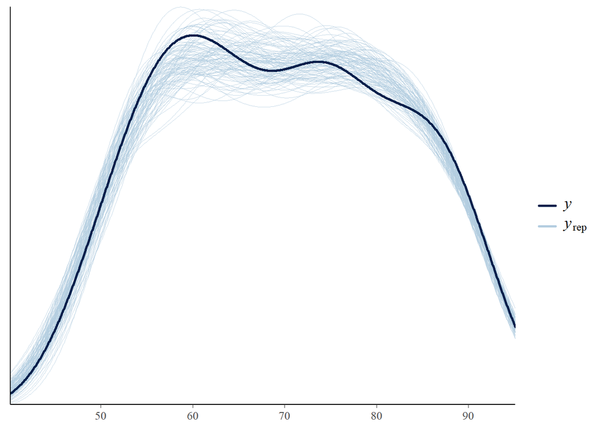

```r
pp_check(kidney_1y_model, type='dens_overlay', ndraws = 100)
```

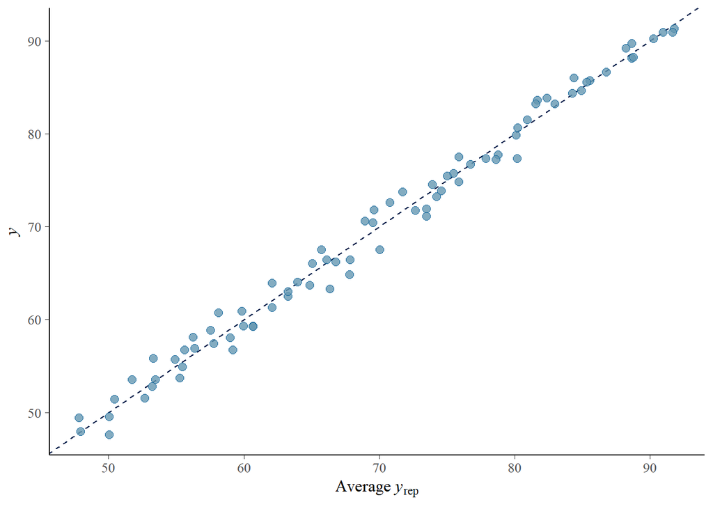

```r
pp_check(kidney_1y_model, type='scatter_avg')
```

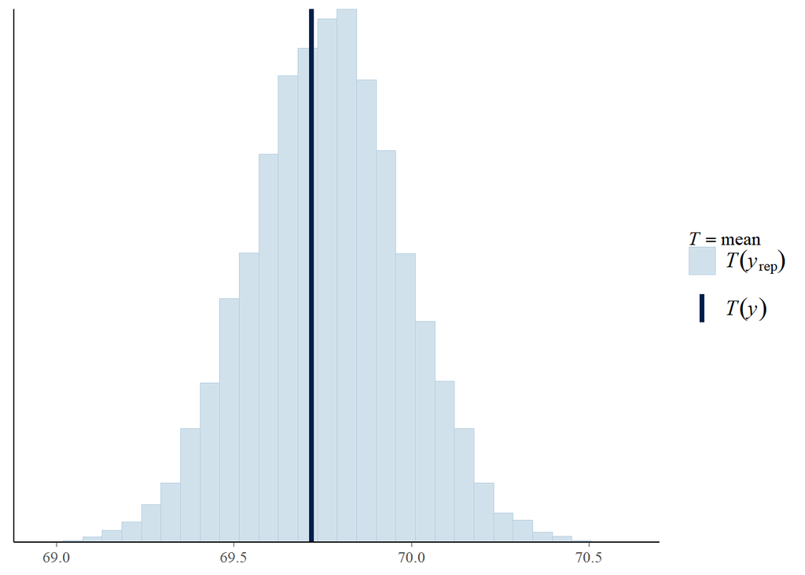

```r
pp_check(kidney_1y_model, type = "stat", stat = "mean")
```

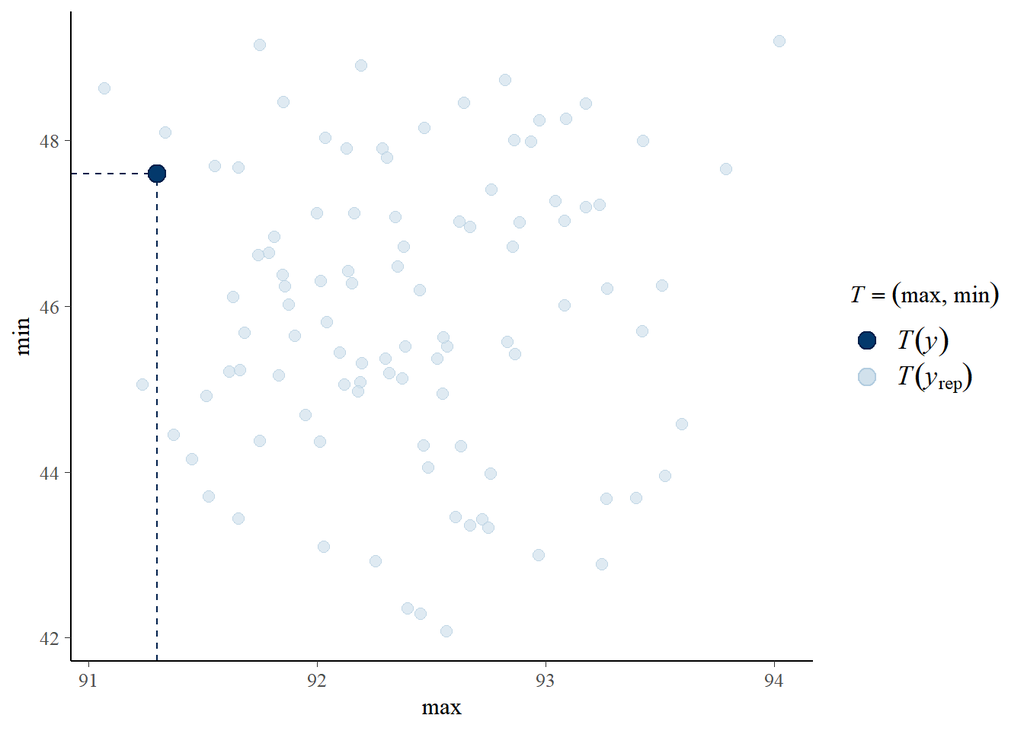

```r
pp_check(kidney_1y_model, type="stat_2d", stat = c("max", "min"), ndraws=100)
```

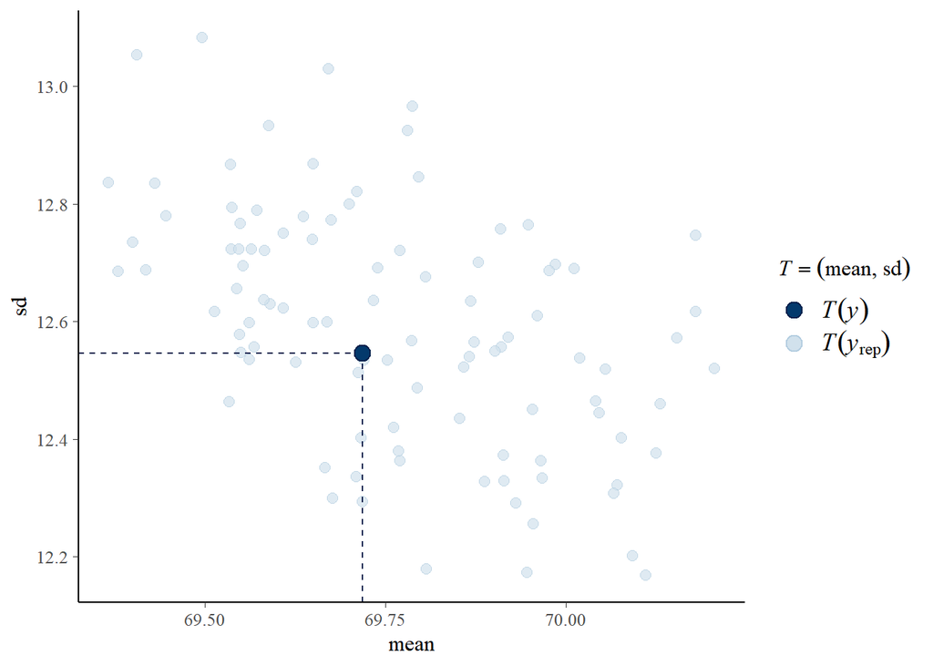

```r
pp_check(kidney_1y_model, type="stat_2d", stat = c("mean", "sd"), ndraws=100)
```

```r
prior_summary(kidney_1y_model)
```

```
                    prior     class                               coef group
                   (flat)         b
             normal(0,30)         b                 groupDenmark.Males
             normal(0,30)         b               groupFinland.Females
             normal(0,30)         b                 groupFinland.Males
             normal(0,30)         b                groupNorway.Females
             normal(0,30)         b                  groupNorway.Males
             normal(0,30)         b                groupSweden.Females
             normal(0,30)         b                  groupSweden.Males
                   (flat)         b syears10cen:groupDenmark.Females_1
                   (flat)         b   syears10cen:groupDenmark.Males_1
                   (flat)         b syears10cen:groupFinland.Females_1
                   (flat)         b   syears10cen:groupFinland.Males_1
                   (flat)         b  syears10cen:groupNorway.Females_1
                   (flat)         b    syears10cen:groupNorway.Males_1
                   (flat)         b  syears10cen:groupSweden.Females_1
                   (flat)         b    syears10cen:groupSweden.Males_1
 student_t(3, 70.5, 16.6) Intercept
    student_t(3, 0, 16.6)       sds
    student_t(3, 0, 16.6)       sds   s(years10cen, by = group, k = 5)
 resp dpar nlpar lb ub       source
                            default
                               user
                               user
                               user
                               user
                               user
                               user
                               user
                       (vectorized)
                       (vectorized)
                       (vectorized)
                       (vectorized)
                       (vectorized)
                       (vectorized)
                       (vectorized)
                       (vectorized)
                            default
                  0         default
                  0    (vectorized)
```

>> Everything seems to be fine: For all parameters, *Rhat* = 1, *ESS* is above 2000 and PPC show relatively good correspondence between the predicted and the real data.

#### 3.1.4.2 Kidney 5y model

```r
summary(kidney_5y_model)
```

```
 Family: gaussian
  Links: mu = identity; sigma = identity
Formula: surv_5y | se(se_5y) ~ group + s(years10cen, by = group, k = 5)
   Data: kidney (Number of observations: 80)
  Draws: 2 chains, each with iter = 7000; warmup = 2000; thin = 1;
         total post-warmup draws = 10000

Smooth Terms:
                                       Estimate Est.Error l-95% CI u-95% CI
sds(syears10cengroupDenmark.Females_1)    29.24     13.13    13.09    61.98
sds(syears10cengroupFinland.Females_1)    17.20     10.08     5.17    42.63
sds(syears10cengroupNorway.Females_1)     14.35      9.83     2.22    39.38
sds(syears10cengroupSweden.Females_1)     14.81      8.61     4.15    37.32
sds(syears10cengroupDenmark.Males_1)      26.80     11.94    12.02    56.52
sds(syears10cengroupFinland.Males_1)      38.04     18.09    12.94    81.89
sds(syears10cengroupNorway.Males_1)       19.74     10.11     7.53    46.15
sds(syears10cengroupSweden.Males_1)       21.30     12.10     5.73    51.29
                                       Rhat Bulk_ESS Tail_ESS
sds(syears10cengroupDenmark.Females_1) 1.00     6047     7160
sds(syears10cengroupFinland.Females_1) 1.00     5862     5866
sds(syears10cengroupNorway.Females_1)  1.00     4103     3002
sds(syears10cengroupSweden.Females_1)  1.00     6327     6650
sds(syears10cengroupDenmark.Males_1)   1.00     6253     6465
sds(syears10cengroupFinland.Males_1)   1.00     4669     4404
sds(syears10cengroupNorway.Males_1)    1.00     6874     6804
sds(syears10cengroupSweden.Males_1)    1.00     4437     4944

Population-Level Effects:
                                   Estimate Est.Error l-95% CI u-95% CI Rhat
Intercept                             45.41      0.52    44.37    46.42 1.00
groupFinland.Females                  10.41      0.73     8.98    11.87 1.00
groupNorway.Females                   11.40      0.79     9.86    12.95 1.00
groupSweden.Females                   11.40      0.66    10.08    12.71 1.00
groupDenmark.Males                    -0.63      0.72    -2.00     0.78 1.00
groupFinland.Males                     5.02      0.75     3.57     6.48 1.00
groupNorway.Males                      6.91      0.74     5.46     8.37 1.00
groupSweden.Males                      8.54      0.64     7.27     9.79 1.00
syears10cen:groupDenmark.Females_1   109.42     14.47    81.65   138.68 1.00
syears10cen:groupFinland.Females_1    86.53     13.01    60.98   112.31 1.00
syears10cen:groupNorway.Females_1     86.25     13.28    58.12   111.00 1.00
```

[output cut: 15 more lines]

```
syears10cen:groupFinland.Females_1     9008     7055
syears10cen:groupNorway.Females_1      8225     6538
syears10cen:groupSweden.Females_1      8626     7279
syears10cen:groupDenmark.Males_1      10949     8077
syears10cen:groupFinland.Males_1       8238     7788
syears10cen:groupNorway.Males_1        9912     8219
syears10cen:groupSweden.Males_1       10233     7809

Family Specific Parameters:
      Estimate Est.Error l-95% CI u-95% CI Rhat Bulk_ESS Tail_ESS
sigma     0.00      0.00     0.00     0.00   NA       NA       NA

Draws were sampled using sampling(NUTS). For each parameter, Bulk_ESS
and Tail_ESS are effective sample size measures, and Rhat is the potential
scale reduction factor on split chains (at convergence, Rhat = 1).
```

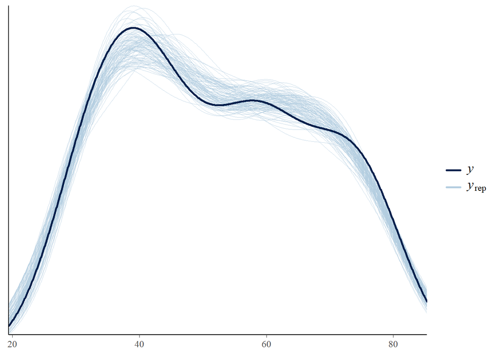

```r
pp_check(kidney_5y_model, type='dens_overlay', ndraws = 100)
```

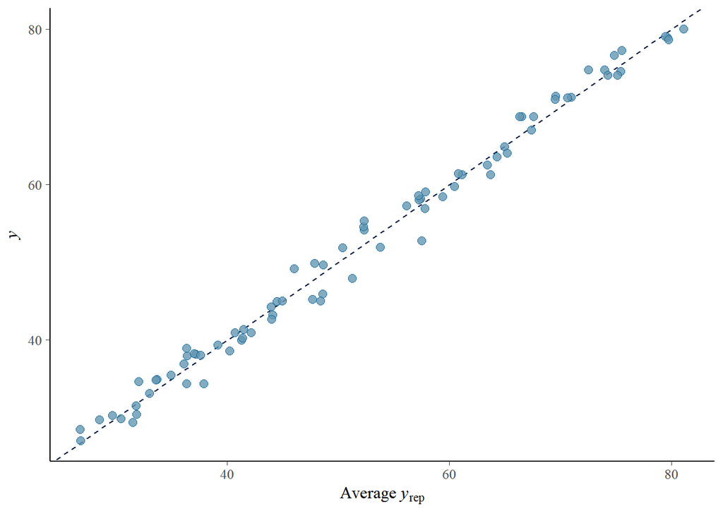

```r
pp_check(kidney_5y_model, type='scatter_avg')
```

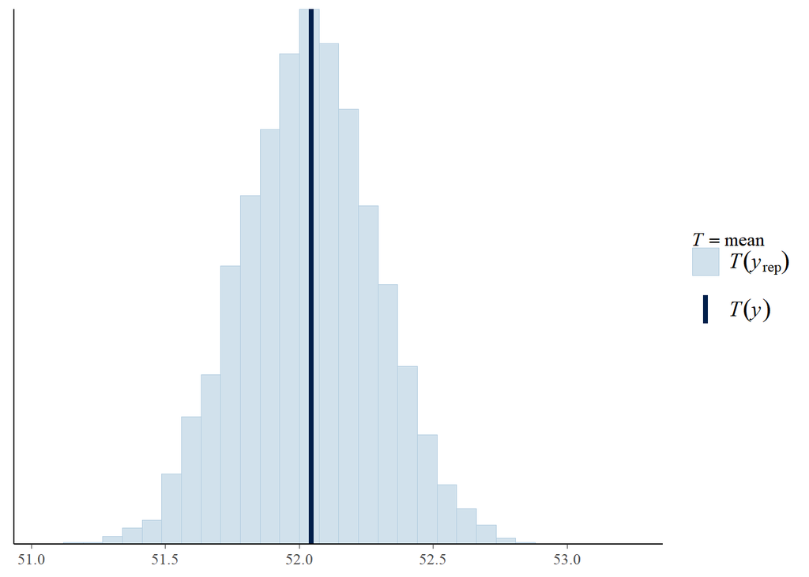

```r
pp_check(kidney_5y_model, type = "stat", stat = "mean")
```

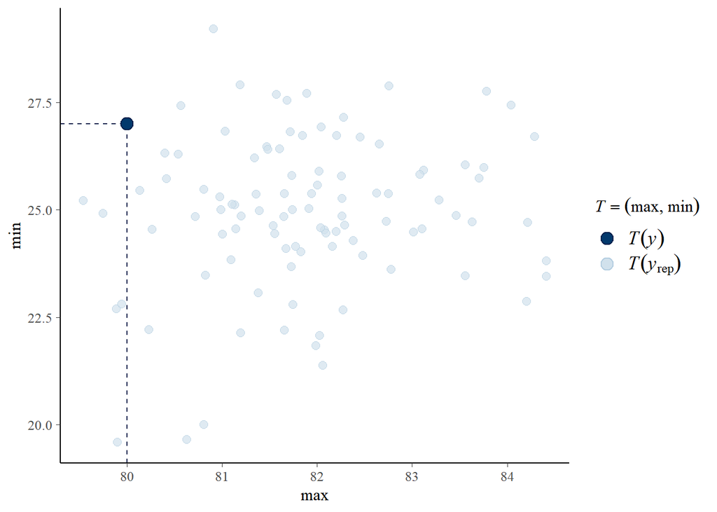

```r
pp_check(kidney_5y_model, type="stat_2d", stat = c("max", "min"), ndraws=100)
```

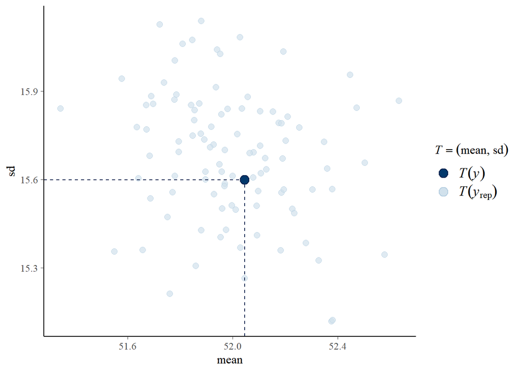

```r
pp_check(kidney_5y_model, type="stat_2d", stat = c("mean", "sd"), ndraws=100)
```

```r
prior_summary(kidney_5y_model)
```

```
                    prior     class                               coef group
                   (flat)         b
             normal(0,30)         b                 groupDenmark.Males
             normal(0,30)         b               groupFinland.Females
             normal(0,30)         b                 groupFinland.Males
             normal(0,30)         b                groupNorway.Females
             normal(0,30)         b                  groupNorway.Males
             normal(0,30)         b                groupSweden.Females
             normal(0,30)         b                  groupSweden.Males
                   (flat)         b syears10cen:groupDenmark.Females_1
                   (flat)         b   syears10cen:groupDenmark.Males_1
                   (flat)         b syears10cen:groupFinland.Females_1
                   (flat)         b   syears10cen:groupFinland.Males_1
                   (flat)         b  syears10cen:groupNorway.Females_1
                   (flat)         b    syears10cen:groupNorway.Males_1
                   (flat)         b  syears10cen:groupSweden.Females_1
                   (flat)         b    syears10cen:groupSweden.Males_1
 student_t(3, 50.8, 18.8) Intercept
    student_t(3, 0, 18.8)       sds
    student_t(3, 0, 18.8)       sds   s(years10cen, by = group, k = 5)
 resp dpar nlpar lb ub       source
                            default
                               user
                               user
                               user
                               user
                               user
                               user
                               user
                       (vectorized)
                       (vectorized)
                       (vectorized)
                       (vectorized)
                       (vectorized)
                       (vectorized)
                       (vectorized)
                       (vectorized)
                            default
                  0         default
                  0    (vectorized)
```

>> Everything seems fine.

#### 3.1.4.3 Bladder 1y model

```r
summary(bladder_1y_model)
```

```
 Family: gaussian
  Links: mu = identity; sigma = identity
Formula: surv_1y | se(se_1y) ~ group + s(years10cen, by = group, k = 5)
   Data: bladder (Number of observations: 80)
  Draws: 2 chains, each with iter = 7000; warmup = 2000; thin = 1;
         total post-warmup draws = 10000

Smooth Terms:
                                       Estimate Est.Error l-95% CI u-95% CI
sds(syears10cengroupDenmark.Females_1)     4.36      3.40     0.22    13.02
sds(syears10cengroupFinland.Females_1)     7.01      3.90     1.63    16.68
sds(syears10cengroupNorway.Females_1)      6.29      5.02     0.27    18.71
sds(syears10cengroupSweden.Females_1)      5.37      3.50     0.65    14.03
sds(syears10cengroupDenmark.Males_1)       4.95      3.01     0.98    12.48
sds(syears10cengroupFinland.Males_1)       8.63      4.13     3.55    19.23
sds(syears10cengroupNorway.Males_1)        8.47      4.13     3.17    18.78
sds(syears10cengroupSweden.Males_1)       12.22      4.73     6.23    24.01
                                       Rhat Bulk_ESS Tail_ESS
sds(syears10cengroupDenmark.Females_1) 1.00     4353     4032
sds(syears10cengroupFinland.Females_1) 1.00     6208     4173
sds(syears10cengroupNorway.Females_1)  1.00     3296     4742
sds(syears10cengroupSweden.Females_1)  1.00     4158     3418
sds(syears10cengroupDenmark.Males_1)   1.00     4452     4172
sds(syears10cengroupFinland.Males_1)   1.00     6703     7236
sds(syears10cengroupNorway.Males_1)    1.00     5812     6295
sds(syears10cengroupSweden.Males_1)    1.00     5614     6506

Population-Level Effects:
                                   Estimate Est.Error l-95% CI u-95% CI Rhat
Intercept                             78.07      0.30    77.48    78.66 1.00
groupFinland.Females                   4.37      0.52     3.33     5.40 1.00
groupNorway.Females                    2.62      0.47     1.70     3.54 1.00
groupSweden.Females                    4.95      0.39     4.19     5.72 1.00
groupDenmark.Males                     6.87      0.35     6.19     7.54 1.00
groupFinland.Males                     8.68      0.39     7.92     9.43 1.00
groupNorway.Males                      9.21      0.36     8.49     9.91 1.00
groupSweden.Males                      9.19      0.33     8.53     9.85 1.00
syears10cen:groupDenmark.Females_1    35.57      6.23    25.92    50.34 1.00
syears10cen:groupFinland.Females_1    20.36      8.39     4.24    37.93 1.00
syears10cen:groupNorway.Females_1     37.37     10.92    22.44    61.39 1.00
```

[output cut: 15 more lines]

```
syears10cen:groupFinland.Females_1     8751     6784
syears10cen:groupNorway.Females_1      3752     6918
syears10cen:groupSweden.Females_1      5904     7196
syears10cen:groupDenmark.Males_1       5843     6771
syears10cen:groupFinland.Males_1       8587     7083
syears10cen:groupNorway.Males_1        7837     6145
syears10cen:groupSweden.Males_1       11911     7381

Family Specific Parameters:
      Estimate Est.Error l-95% CI u-95% CI Rhat Bulk_ESS Tail_ESS
sigma     0.00      0.00     0.00     0.00   NA       NA       NA

Draws were sampled using sampling(NUTS). For each parameter, Bulk_ESS
and Tail_ESS are effective sample size measures, and Rhat is the potential
scale reduction factor on split chains (at convergence, Rhat = 1).
```

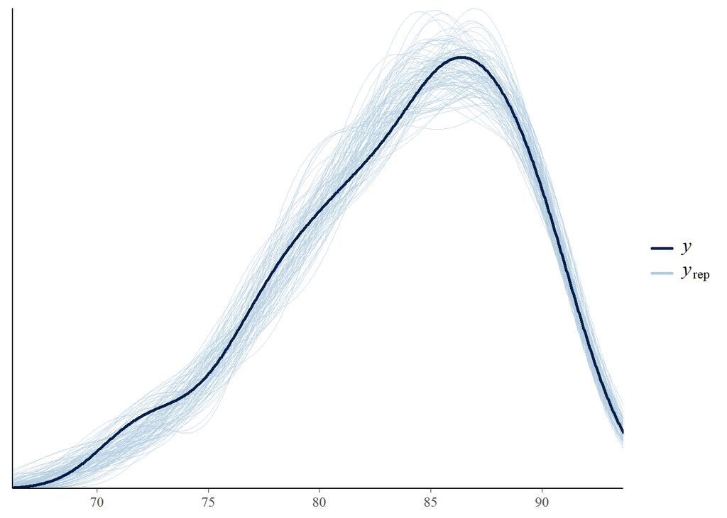

```r
pp_check(bladder_1y_model, type='dens_overlay', ndraws = 100)
```

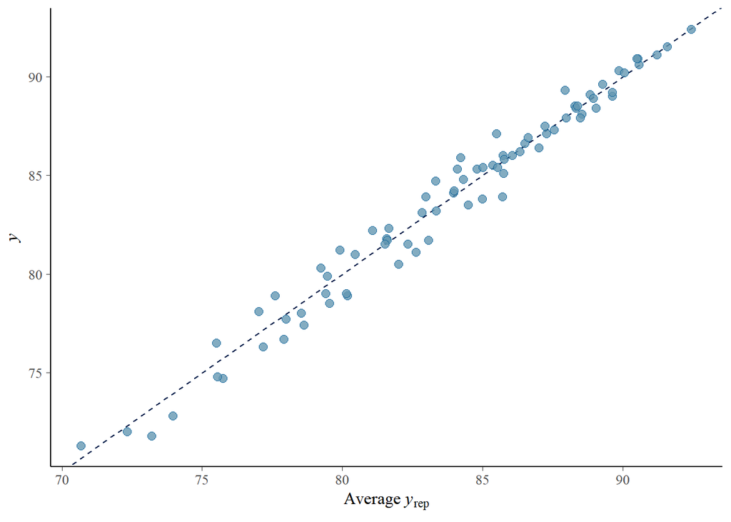

```r
pp_check(bladder_1y_model, type='scatter_avg')
```

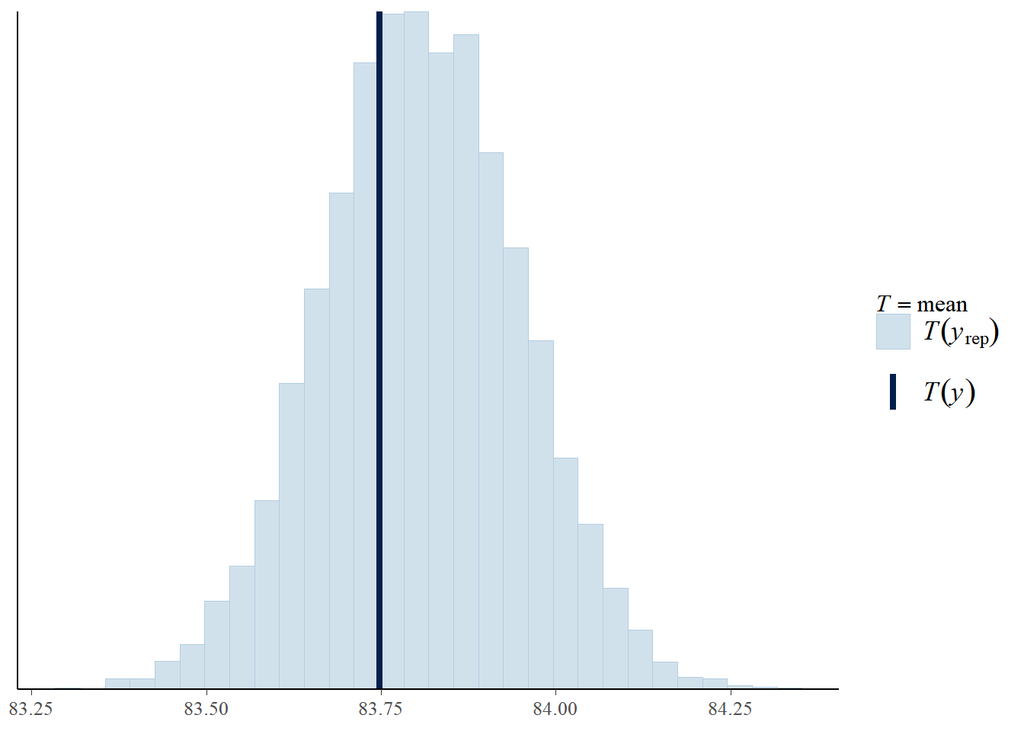

```r
pp_check(bladder_1y_model, type = "stat", stat = "mean")
```

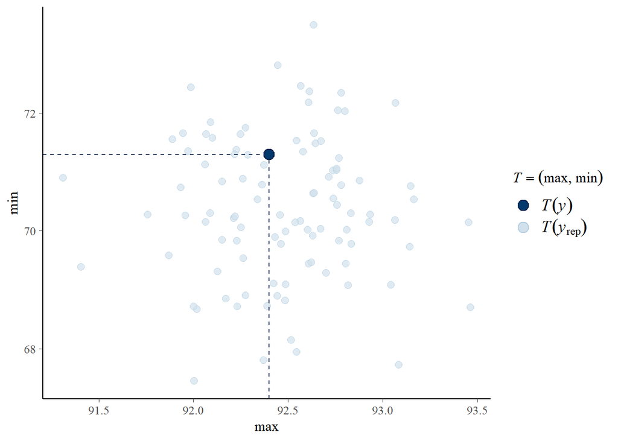

```r
pp_check(bladder_1y_model, type="stat_2d", stat = c("max", "min"), ndraws=100)
```

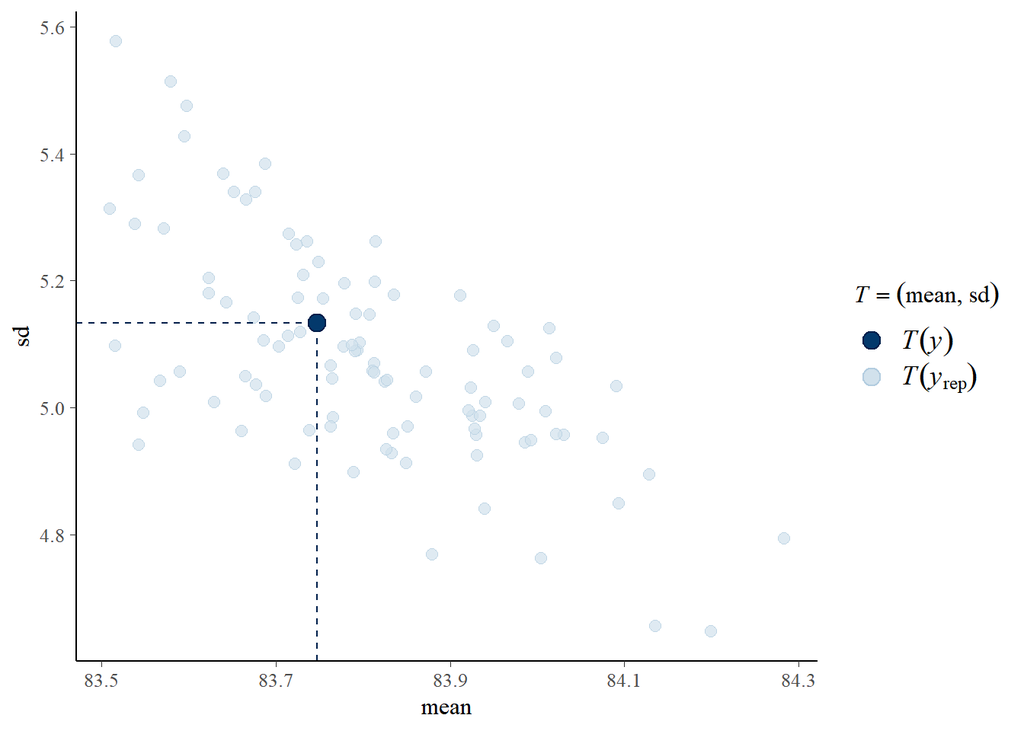

```r
pp_check(bladder_1y_model, type="stat_2d", stat = c("mean", "sd"), ndraws=100)
```

```r
prior_summary(bladder_1y_model)
```

```
                   prior     class                               coef group
                  (flat)         b
            normal(0,30)         b                 groupDenmark.Males
            normal(0,30)         b               groupFinland.Females
            normal(0,30)         b                 groupFinland.Males
            normal(0,30)         b                groupNorway.Females
            normal(0,30)         b                  groupNorway.Males
            normal(0,30)         b                groupSweden.Females
            normal(0,30)         b                  groupSweden.Males
                  (flat)         b syears10cen:groupDenmark.Females_1
                  (flat)         b   syears10cen:groupDenmark.Males_1
                  (flat)         b syears10cen:groupFinland.Females_1
                  (flat)         b   syears10cen:groupFinland.Males_1
                  (flat)         b  syears10cen:groupNorway.Females_1
                  (flat)         b    syears10cen:groupNorway.Males_1
                  (flat)         b  syears10cen:groupSweden.Females_1
                  (flat)         b    syears10cen:groupSweden.Males_1
 student_t(3, 84.8, 5.4) Intercept
    student_t(3, 0, 5.4)       sds
    student_t(3, 0, 5.4)       sds   s(years10cen, by = group, k = 5)
 resp dpar nlpar lb ub       source
                            default
                               user
                               user
                               user
                               user
                               user
                               user
                               user
                       (vectorized)
                       (vectorized)
                       (vectorized)
                       (vectorized)
                       (vectorized)
                       (vectorized)
                       (vectorized)
                       (vectorized)
                            default
                  0         default
                  0    (vectorized)
```

>> Everything seems fine.

#### 3.1.4.4 Bladder 5y model

```r
summary(bladder_5y_model)
```

```
 Family: gaussian
  Links: mu = identity; sigma = identity
Formula: surv_5y | se(se_5y) ~ group + s(years10cen, by = group, k = 5)
   Data: bladder (Number of observations: 80)
  Draws: 2 chains, each with iter = 7000; warmup = 2000; thin = 1;
         total post-warmup draws = 10000

Smooth Terms:
                                       Estimate Est.Error l-95% CI u-95% CI
sds(syears10cengroupDenmark.Females_1)     5.92      5.05     0.17    18.46
sds(syears10cengroupFinland.Females_1)    12.85      6.35     4.77    28.96
sds(syears10cengroupNorway.Females_1)      8.69      6.30     0.54    23.68
sds(syears10cengroupSweden.Females_1)      4.81      4.56     0.14    16.25
sds(syears10cengroupDenmark.Males_1)       4.39      3.60     0.24    13.22
sds(syears10cengroupFinland.Males_1)      19.15      7.84     9.31    38.26
sds(syears10cengroupNorway.Males_1)        9.06      5.48     1.67    22.46
sds(syears10cengroupSweden.Males_1)       13.11      5.66     5.64    27.45
                                       Rhat Bulk_ESS Tail_ESS
sds(syears10cengroupDenmark.Females_1) 1.00     3319     4080
sds(syears10cengroupFinland.Females_1) 1.00     6654     6815
sds(syears10cengroupNorway.Females_1)  1.00     3698     3708
sds(syears10cengroupSweden.Females_1)  1.00     3827     5218
sds(syears10cengroupDenmark.Males_1)   1.00     4132     4563
sds(syears10cengroupFinland.Males_1)   1.00     5173     6298
sds(syears10cengroupNorway.Males_1)    1.00     4031     3777
sds(syears10cengroupSweden.Males_1)    1.00     5189     6103

Population-Level Effects:
                                   Estimate Est.Error l-95% CI u-95% CI Rhat
Intercept                             62.00      0.40    61.21    62.77 1.00
groupFinland.Females                   4.96      0.70     3.59     6.34 1.00
groupNorway.Females                    3.31      0.64     2.08     4.57 1.00
groupSweden.Females                    6.88      0.53     5.86     7.92 1.00
groupDenmark.Males                     7.07      0.48     6.14     8.03 1.00
groupFinland.Males                     8.25      0.56     7.13     9.34 1.00
groupNorway.Males                     10.00      0.52     8.99    11.02 1.00
groupSweden.Males                     11.42      0.46    10.53    12.34 1.00
syears10cen:groupDenmark.Females_1    54.49      9.72    41.12    77.42 1.00
syears10cen:groupFinland.Females_1    47.85     12.98    23.60    75.74 1.00
syears10cen:groupNorway.Females_1     53.94     12.94    34.92    83.27 1.00
```

[output cut: 15 more lines]

```
syears10cen:groupFinland.Females_1     6609     6339
syears10cen:groupNorway.Females_1      4228     7133
syears10cen:groupSweden.Females_1      4257     6052
syears10cen:groupDenmark.Males_1       5506     5981
syears10cen:groupFinland.Males_1       8109     6790
syears10cen:groupNorway.Males_1        4466     5798
syears10cen:groupSweden.Males_1        9431     7209

Family Specific Parameters:
      Estimate Est.Error l-95% CI u-95% CI Rhat Bulk_ESS Tail_ESS
sigma     0.00      0.00     0.00     0.00   NA       NA       NA

Draws were sampled using sampling(NUTS). For each parameter, Bulk_ESS
and Tail_ESS are effective sample size measures, and Rhat is the potential
scale reduction factor on split chains (at convergence, Rhat = 1).
```

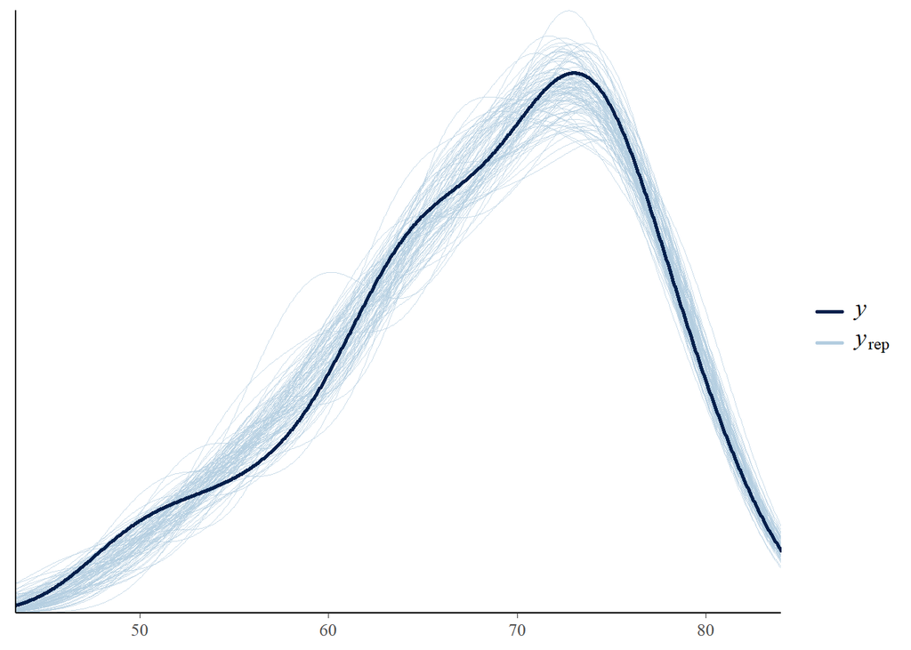

```r
pp_check(bladder_5y_model, type='dens_overlay', ndraws = 100)
```

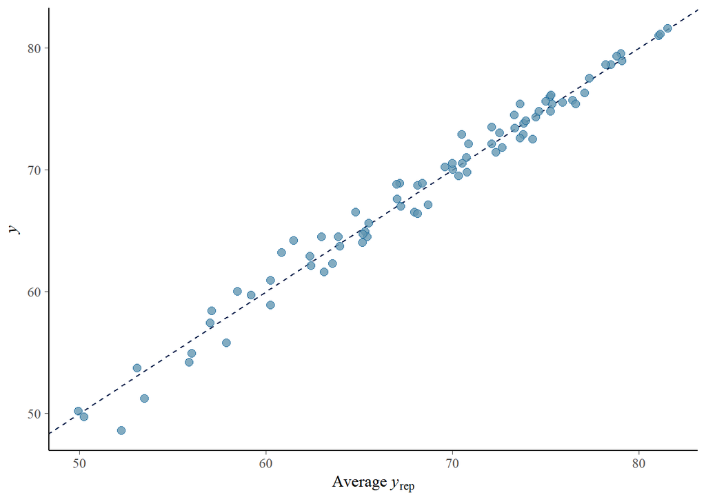

```r
pp_check(bladder_5y_model, type='scatter_avg')
```

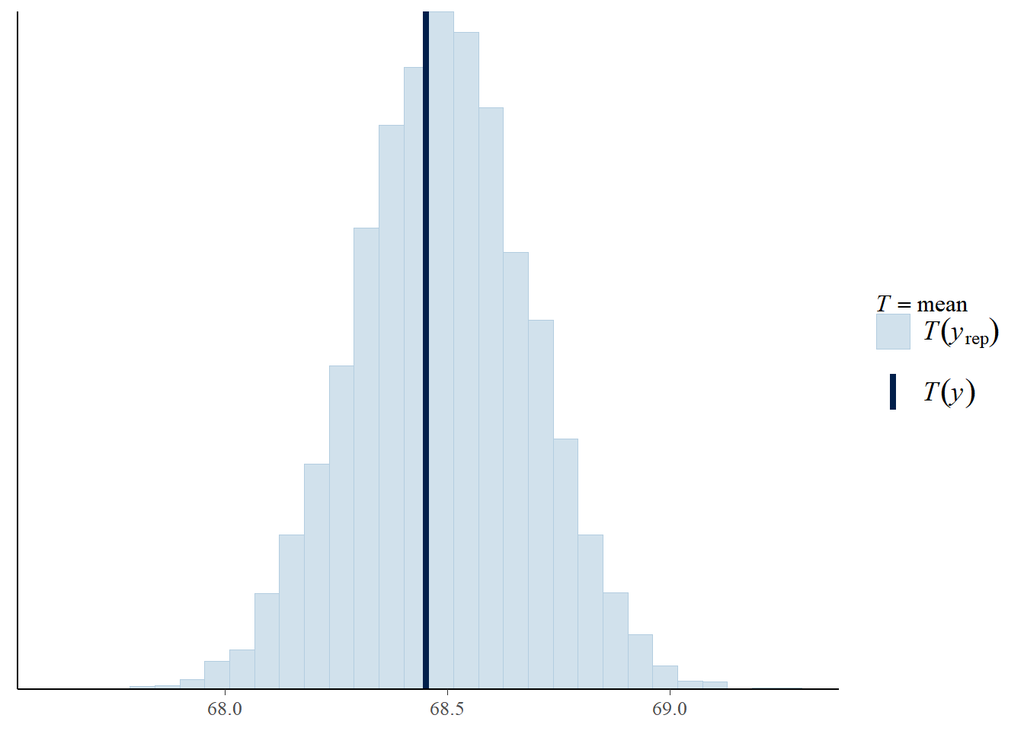

```r
pp_check(bladder_5y_model, type = "stat", stat = "mean")
```

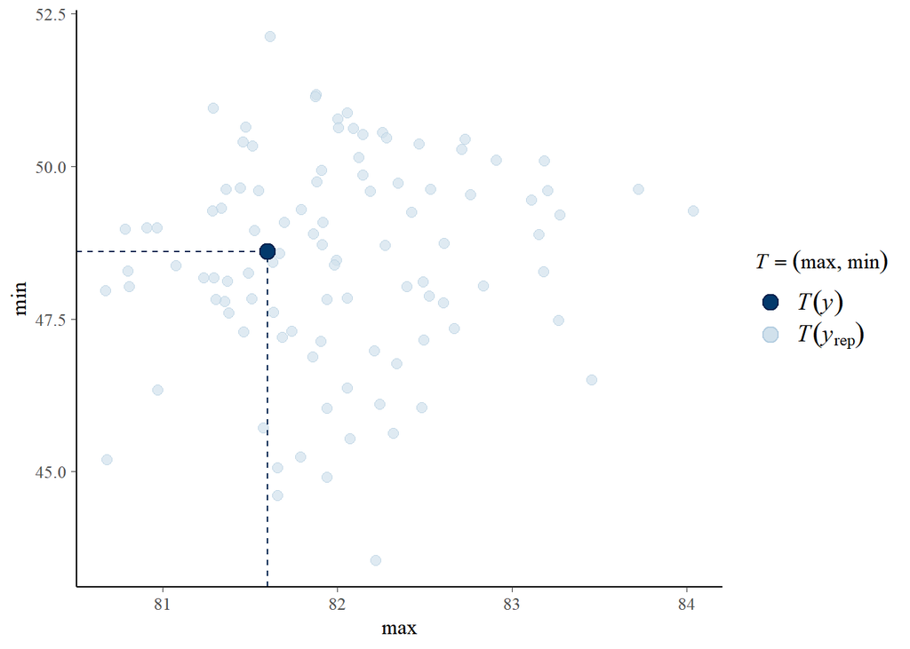

```r
pp_check(bladder_5y_model, type="stat_2d", stat = c("max", "min"), ndraws=100)
```

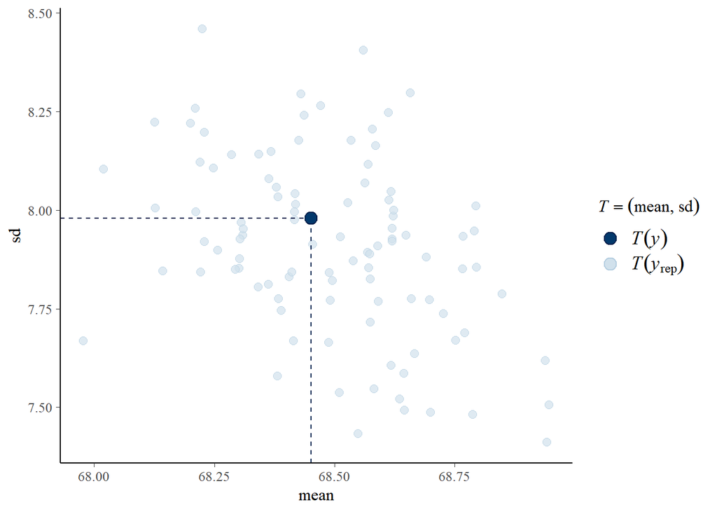

```r
pp_check(bladder_5y_model, type="stat_2d", stat = c("mean", "sd"), ndraws=100)
```

```r
prior_summary(bladder_5y_model)
```

```
                   prior     class                               coef group
                  (flat)         b
            normal(0,30)         b                 groupDenmark.Males
            normal(0,30)         b               groupFinland.Females
            normal(0,30)         b                 groupFinland.Males
            normal(0,30)         b                groupNorway.Females
            normal(0,30)         b                  groupNorway.Males
            normal(0,30)         b                groupSweden.Females
            normal(0,30)         b                  groupSweden.Males
                  (flat)         b syears10cen:groupDenmark.Females_1
                  (flat)         b   syears10cen:groupDenmark.Males_1
                  (flat)         b syears10cen:groupFinland.Females_1
                  (flat)         b   syears10cen:groupFinland.Males_1
                  (flat)         b  syears10cen:groupNorway.Females_1
                  (flat)         b    syears10cen:groupNorway.Males_1
                  (flat)         b  syears10cen:groupSweden.Females_1
                  (flat)         b    syears10cen:groupSweden.Males_1
 student_t(3, 69.9, 8.1) Intercept
    student_t(3, 0, 8.1)       sds
    student_t(3, 0, 8.1)       sds   s(years10cen, by = group, k = 5)
 resp dpar nlpar lb ub       source
                            default
                               user
                               user
                               user
                               user
                               user
                               user
                               user
                       (vectorized)
                       (vectorized)
                       (vectorized)
                       (vectorized)
                       (vectorized)
                       (vectorized)
                       (vectorized)
                       (vectorized)
                            default
                  0         default
                  0    (vectorized)
```

>> Everything seems fine.

## 3.2 Custom functions

All the functions below serve for plotting of nonlinear trends in survival and related uncertainty. All the functions below use extracted posterior samples as an input **data**. The samples represent estimation of survival over the 50 years (1971 to 2020) for specific country, cancer, and type of survival (1-year, 5-years, conditional [5y/1y]. The time period of 50 years must be divided to sequence of 500 numbers (1/10 of a year).

### 3.2.1 *breakpo*

This function serves to identify *breaking points*, i.e. times when the annual change of survival changed with at least 95% plausibility. This was assessed by calculation of the 2nd derivation of the given survival measure and its 95% credible interval (CI); the ‘*breaking point*’ was defined as a peak value within at least a 3-year interval where 95% CI for the 2nd derivation did not cross zero. If the 2nd derivation is plausibly non-zero for at least 3 years, the function takes the peak in the 2nd derivation (within the identified time interval) as the *breaking point* (must be between the years 1976 and 2016).

Function also returns table of potential *brekaing points*, if they were identified.

There is one additional argument *arb* which should be zero except for the situation when the multiple breaking points overlap. The argument only move the breaking points by given value to avoid overlapping.

```r
breakpo<-function(data,arb){
 data<-data.frame((data[,-1] - data[,-ncol(data)])*10)
  data<-data.frame(data[,-1] - data[,-ncol(data)])
  data=sapply(data, function(p) quantile(p, probs = c(0.025,0.975,0.5)))
  cbinl<-c()
  x=1
  repeat{
    cbinl[x]<-
      if(data[1,x]>0|data[2,x]<0){cbinl[x]=1}else{cbinl[x]=0}
    x<-x+1
    if(x>length(data[1,])){break}}
  cbin=1;x<-1
  repeat{
    cbin[x+1]<-abs(cbinl[x]-cbinl[x+1])
    x=x+1
    if(x>(length(cbinl)-1)){break}}
  data<-data.frame(rbind(data,cbin));data[5,]<-yreal[c(2:499)]-0.049
  data[6,]<-1:498;data[4,51]<-1;data[4,449]<-1
  row.names(data)<-c("cil","ciu","est","stat_change","year","timepoint")
  data2=t(data[,data[4,]==1])
  data2<-data.frame(data2)
  tr<-subset(data2,data2$timepoint>50&data2$timepoint<450)
  y=1
  bp<-c()
  bx<-1
  repeat{
    if( (tr[y,1]<0) & (tr[y,2]<0) & (  (tr$year[y+1]-tr$year[y])>3   )  ) {
      tr2<-data[,tr[y,6]:(tr[y+1,6]-2)]
      bp[bx]<- tr2[,order(tr2[3,],decreasing=F)[1]][5]
      bx=bx+1
    }
    if( (tr[y,1]>0) & (tr[y,2]>0) & (  (tr$year[y+1]-tr$year[y])>3   )) {
      tr2<-data[,tr[y,6]:(tr[y+1,6]-2)]
      bp[bx]<- tr2[,order(tr2[3,],decreasing=T)[1]][5]
      bx=bx+1
    }
    y=y+1;if(y>(dim(tr)[1]-1)){break}}
  y<-1
  try(repeat{
    lines(c(bp[y]+arb,bp[y]+arb),c(range[1],range[1]+0.025*scal),col=cola[xx],lwd=3.5,lend=1)
    lines(c(bp[y]+arb,bp[y]+arb),c(range[2],range[2]-0.025*scal),col=cola[xx],lwd=3.5,lend=1)
    lines(c(bp[y]+arb,bp[y]+arb),c(range[1],range[1]+0.999*scal),col=colc[xx],lwd=1,lend=1,lty=2)
    y=y+1;if(y>length(bp)){break}},silent=TRUE)
 print(bp)
 print(tr)
  }
```

### 3.2.2 *polyg_surv*

for drawing 95% credible interval for survival indicators

```r
polyg_surv<-function(data){
  data<-data.frame(data)
  data<-sapply(data, function(p) quantile(p, probs = c(0.025,0.975,0.5)))
  cis<-c(data[1,],rev(data[2,]))
  x<-c(yreal[1:500],yreal[500:1])
  cis[cis<range[1]]<-range[1]
  cis[cis>range[2]]<-range[2]
  polygon(x,cis,border=NA,col=colb[xx],xpd=F)}
```

### 3.2.3 *surv_fit*

Fit curve of survival trend over the 50 years. **Solid lines** imply that that the curve is increasing or decreasing with at least 95% plausibility (95% credible interval for 1st derivation of estimated survival does not cross zero) for at least 5 years. Dashed lines show otherwise (no detectable change in the survival)

```r
surv_fit<-function(dat2){
  dat2=data.frame(dat2)
  cis= data.frame((dat2[,-1] - dat2[,-ncol(dat2)])*10)
  cis=sapply(cis, function(p) quantile(p, probs = c(0.025,0.975)))
  est=sapply(dat2, function(p) quantile(p, probs = c(0.5)))
  data=cis
  cbinl<-c()
  x=1
  repeat{
    cbinl[x]<-
      if(data[1,x]>0|data[2,x]<0){cbinl[x]=1}else{cbinl[x]=0}
    x<-x+1
    if(x>length(data[1,])){break}}
  cbin=1;x<-1
  repeat{
    cbin[x+1]<-abs(cbinl[x]-cbinl[x+1])
    x=x+1
    if(x>(length(cbinl)-1)){break}}
  data<-data.frame(rbind(data,cbin));data[4,]<-yreal[c(2:500)]-0.049;data[5,]<-1:499
  row.names(data)<-c("cil","ciu","stat_change","year","timepoint");data[3,499]<-1
  data2=t(data[,data[3,]==1])
  data2<-data.frame(data2)
  tr<-data2;y=1
  yreal=seq(1971,2020,length=500)
  repeat{
    if((((tr[y,1]<0)&(tr[y,2])<0))|(((tr[y,1]>0)&(tr[y,2])>0))&(tr[y+1,4]-tr[y,4])>5)
    {lines(yreal[tr[y,5]:tr[y+1,5]],
           est[tr[y,5]:tr[y+1,5]],lwd=1.9,col=cola[xx],lend=1)}
    y<-y+1;if(y>dim(tr)[1]-1){break}}
  lines(yreal[1:500],est,lwd=1,col=cola[xx],lty=2,lend=1)}
```

### 3.2.4 *polyg_slope*

Draws 95% credible interval for slope of the survival trend (1st derivation of the estimated survival trend)

```r
polyg_slope<-function(data){
  x<-c(yreal[1:499],yreal[499:1])
  data<-data.frame((data[,-1] - data[,-ncol(data)]))*10
  data=sapply(data, function(p) quantile(p, probs = c(0.025,0.975,0.5)))
  cis<-c(data[1,],rev(data[2,]))
  cis[cis<range[1]]<-range[1]
  cis[cis>range[2]]<-range[2]
  polygon(x,cis,border=NA,col=colb[xx])}
```

### 3.2.5 *slope_fit*

Fit curve of **slope** (i.e., the **magnitude of the change**) of the survival trend over the 50 years. Solid lines imply that that the curve is increasing or decreasing with at least 95% plausibility (95% credible interval for 2st derivation of estimated survival does not cross zero) for at least 3 years. Dashed lines show otherwise (no detectable change in the slope of the survival trend)

```r
slope_fit<-function(data){
  data = data.frame((data[,-1] - data[,-ncol(data)])*10)
  dar2<-sapply(data, function(p) quantile(p, probs = c(0.5)))
  data<-data.frame(data[,-1] - data[,-ncol(data)])
  data=sapply(data, function(p) quantile(p, probs = c(0.025,0.975,0.5)))
  cbinl<-c()
  x=1
  repeat{
    cbinl[x]<-
      if(data[1,x]>0|data[2,x]<0){cbinl[x]=1}else{cbinl[x]=0}
    x<-x+1
    if(x>length(data[1,])){break}}
  cbin=1;x<-1
  repeat{
    cbin[x+1]<-abs(cbinl[x]-cbinl[x+1])
    x=x+1
    if(x>(length(cbinl)-1)){break}}
  data<-data.frame(rbind(data,cbin));data[5,]<-yreal[c(2:499)]-0.049;data[6,]<-1:498
  row.names(data)<-c("cil","ciu","est","stat_change","year","timepoint")
  data[4,450]<-1
  data[4,50]<-1
  data=data[,50:450]
  lines(yreal[1:499],dar2,lwd=1,col=cola[xx],lty=2,lend=1)
  data2=(t(data[,data[4,]==1]))
  data2<-data.frame(data2)
  tr<-data2;y=1
  yreal=seq(1971,2020,length=498)
  repeat{
    if(((((tr[y,1]<0)&(tr[y,2])<0))|(((tr[y,1]>0)&(tr[y,2])>0)))&(tr[y+1,5]-tr[y,5])>3)
    {lines(yreal[tr[y,6]:tr[y+1,6]],
           dar2[tr[y,6]:tr[y+1,6]]
           ,lwd=1.9,col=cola[xx],lend=1)}
    y<-y+1;if(y>dim(tr)[1]-1){break}}
  }
```

## 3.3 Extraction of posterior samples

It will be used to visualize the predictions of the models jointly with showing uncertainty of model estimations

```r
## kidney posterior extraction ---------------------------------------------------
yreal <- seq(1971,2020,length=500)
first <- expand.grid(years10cen = ((yreal-1995.5)/10),
                     group = c('Denmark.Females','Finland.Females',
                               'Norway.Females','Sweden.Females',
                               'Denmark.Males','Finland.Males',
                               'Norway.Males','Sweden.Males'), y = 0)

ms_1y<-posterior_smooths(kidney_1y_model,smooth="s(years10cen,by=group,k=5)",
                         newdata = first)
post_fix<-as.data.frame(kidney_1y_model,
                        variable = c("b_Intercept","b_groupFinland.Females",
                                     "b_groupNorway.Females","b_groupSweden.Females",
                                     "b_groupDenmark.Males","b_groupFinland.Males",
                                     "b_groupNorway.Males","b_groupSweden.Males"))
fixef(kidney_1y_model)
```

```
                                     Estimate  Est.Error       Q2.5      Q97.5
Intercept                          62.9166996  0.4709803 61.9954644  63.839548
groupFinland.Females                9.7655183  0.6530530  8.4916694  11.040989
groupNorway.Females                10.0188568  0.6964579  8.6469979  11.394085
groupSweden.Females                11.0094471  0.5701680  9.9074180  12.134812
groupDenmark.Males                  0.9435266  0.6344587 -0.2988091   2.190200
groupFinland.Males                  6.6635108  0.6649952  5.3692967   7.954739
groupNorway.Males                   6.8247517  0.6442763  5.5550339   8.104949
groupSweden.Males                   9.5161475  0.5526470  8.4447934  10.584108
syears10cen:groupDenmark.Females_1 86.3473688 12.5076618 61.5859579 111.151206
syears10cen:groupFinland.Females_1 56.8184276  9.9847611 37.1651317  76.455252
syears10cen:groupNorway.Females_1  61.1418284 11.1802440 37.1255036  80.479086
syears10cen:groupSweden.Females_1  71.5460160  6.5272287 57.0198197  84.185931
syears10cen:groupDenmark.Males_1   87.1326393 10.8652189 65.9255187 108.822570
syears10cen:groupFinland.Males_1   67.9242131 13.9451916 40.1899647  94.032154
syears10cen:groupNorway.Males_1    69.7867667 10.2921134 48.2788787  88.589281
syears10cen:groupSweden.Males_1    97.8064227  8.4635548 81.1901711 114.576654
```

```r
post_kidney_den_fem_1y<-ms_1y[,1:500]     +post_fix[,1]
post_kidney_fin_fem_1y<-ms_1y[,501:1000]  +post_fix[,1]+post_fix[,2]
post_kidney_nor_fem_1y<-ms_1y[,1001:1500] +post_fix[,1]+post_fix[,3]
post_kidney_swe_fem_1y<-ms_1y[,1501:2000] +post_fix[,1]+post_fix[,4]
post_kidney_den_mal_1y<-ms_1y[,2001:2500] +post_fix[,1]+post_fix[,5]
post_kidney_fin_mal_1y<-ms_1y[,2501:3000] +post_fix[,1]+post_fix[,6]
post_kidney_nor_mal_1y<-ms_1y[,3001:3500] +post_fix[,1]+post_fix[,7]
post_kidney_swe_mal_1y<-ms_1y[,3501:4000] +post_fix[,1]+post_fix[,8]

post_fix<-as.data.frame(kidney_5y_model,
                        variable = c("b_Intercept","b_groupFinland.Females",
                                     "b_groupNorway.Females","b_groupSweden.Females",
                                     "b_groupDenmark.Males","b_groupFinland.Males",
                                     "b_groupNorway.Males","b_groupSweden.Males"))

ms_5y<-posterior_smooths(kidney_5y_model,smooth="s(years10cen,by=group,k=5)",
                         newdata = first)
post_kidney_den_fem_5y<-ms_5y[,1:500]     +post_fix[,1]
post_kidney_fin_fem_5y<-ms_5y[,501:1000]  +post_fix[,1]+post_fix[,2]
post_kidney_nor_fem_5y<-ms_5y[,1001:1500] +post_fix[,1]+post_fix[,3]
post_kidney_swe_fem_5y<-ms_5y[,1501:2000] +post_fix[,1]+post_fix[,4]
post_kidney_den_mal_5y<-ms_5y[,2001:2500] +post_fix[,1]+post_fix[,5]
post_kidney_fin_mal_5y<-ms_5y[,2501:3000] +post_fix[,1]+post_fix[,6]
post_kidney_nor_mal_5y<-ms_5y[,3001:3500] +post_fix[,1]+post_fix[,7]
post_kidney_swe_mal_5y<-ms_5y[,3501:4000] +post_fix[,1]+post_fix[,8]

post_kidney_den_fem_cond<-(post_kidney_den_fem_5y/post_kidney_den_fem_1y)*100
post_kidney_den_mal_cond<-(post_kidney_den_mal_5y/post_kidney_den_mal_1y)*100
post_kidney_fin_fem_cond<-(post_kidney_fin_fem_5y/post_kidney_fin_fem_1y)*100
post_kidney_fin_mal_cond<-(post_kidney_fin_mal_5y/post_kidney_fin_mal_1y)*100
post_kidney_nor_fem_cond<-(post_kidney_nor_fem_5y/post_kidney_nor_fem_1y)*100
post_kidney_nor_mal_cond<-(post_kidney_nor_mal_5y/post_kidney_nor_mal_1y)*100
post_kidney_swe_fem_cond<-(post_kidney_swe_fem_5y/post_kidney_swe_fem_1y)*100
post_kidney_swe_mal_cond<-(post_kidney_swe_mal_5y/post_kidney_swe_mal_1y)*100


## bladder posterior extraction ---------------------------------------------------
ms_1y<-posterior_smooths(bladder_1y_model,smooth="s(years10cen,by=group,k=5)",
                         newdata = first)
post_fix<-as.data.frame(bladder_1y_model,
                        variable = c("b_Intercept","b_groupFinland.Females",
                                     "b_groupNorway.Females","b_groupSweden.Females",
                                     "b_groupDenmark.Males","b_groupFinland.Males",
                                     "b_groupNorway.Males","b_groupSweden.Males"))

post_bladder_den_fem_1y<-ms_1y[,1:500]     +post_fix[,1]
post_bladder_fin_fem_1y<-ms_1y[,501:1000]  +post_fix[,1]+post_fix[,2]
post_bladder_nor_fem_1y<-ms_1y[,1001:1500] +post_fix[,1]+post_fix[,3]
post_bladder_swe_fem_1y<-ms_1y[,1501:2000] +post_fix[,1]+post_fix[,4]
post_bladder_den_mal_1y<-ms_1y[,2001:2500] +post_fix[,1]+post_fix[,5]
post_bladder_fin_mal_1y<-ms_1y[,2501:3000] +post_fix[,1]+post_fix[,6]
post_bladder_nor_mal_1y<-ms_1y[,3001:3500] +post_fix[,1]+post_fix[,7]
post_bladder_swe_mal_1y<-ms_1y[,3501:4000] +post_fix[,1]+post_fix[,8]

post_fix<-as.data.frame(bladder_5y_model,
                        variable = c("b_Intercept","b_groupFinland.Females",
                                     "b_groupNorway.Females","b_groupSweden.Females",
                                     "b_groupDenmark.Males","b_groupFinland.Males",
                                     "b_groupNorway.Males","b_groupSweden.Males"))
ms_5y<-posterior_smooths(bladder_5y_model,smooth="s(years10cen,by=group,k=5)",
                         newdata = first)

post_bladder_den_fem_5y<-ms_5y[,1:500]     +post_fix[,1]
post_bladder_fin_fem_5y<-ms_5y[,501:1000]  +post_fix[,1]+post_fix[,2]
post_bladder_nor_fem_5y<-ms_5y[,1001:1500] +post_fix[,1]+post_fix[,3]
post_bladder_swe_fem_5y<-ms_5y[,1501:2000] +post_fix[,1]+post_fix[,4]
post_bladder_den_mal_5y<-ms_5y[,2001:2500] +post_fix[,1]+post_fix[,5]
post_bladder_fin_mal_5y<-ms_5y[,2501:3000] +post_fix[,1]+post_fix[,6]
post_bladder_nor_mal_5y<-ms_5y[,3001:3500] +post_fix[,1]+post_fix[,7]
post_bladder_swe_mal_5y<-ms_5y[,3501:4000] +post_fix[,1]+post_fix[,8]

post_bladder_den_fem_cond<-(post_bladder_den_fem_5y/post_bladder_den_fem_1y)*100
post_bladder_den_mal_cond<-(post_bladder_den_mal_5y/post_bladder_den_mal_1y)*100
post_bladder_fin_fem_cond<-(post_bladder_fin_fem_5y/post_bladder_fin_fem_1y)*100
post_bladder_fin_mal_cond<-(post_bladder_fin_mal_5y/post_bladder_fin_mal_1y)*100
post_bladder_nor_fem_cond<-(post_bladder_nor_fem_5y/post_bladder_nor_fem_1y)*100
post_bladder_nor_mal_cond<-(post_bladder_nor_mal_5y/post_bladder_nor_mal_1y)*100
post_bladder_swe_fem_cond<-(post_bladder_swe_fem_5y/post_bladder_swe_fem_1y)*100
post_bladder_swe_mal_cond<-(post_bladder_swe_mal_5y/post_bladder_swe_mal_1y)*100
```

## 3.4 Visualisations

### 3.4.1 Denmark

```r
## DEN figures
m <- matrix(c(15,1 ,2
              ,3,7 ,11
              ,4,8 ,12
              ,5,9 ,13
              ,6,10,14), nrow = 5, ncol =3 ,byrow = TRUE)
layout(mat = m,heights = c(0.03,0.6/2,0.37/2,0.6/2,0.37/2),
       widths = c(0.04,rep(0.96/2,2)))
par(mgp=c(1.6,0.62,0))
par(mar=c(0,0,0,0))


plot(NULL, axes=FALSE,xlab="",ylab="",xlim=c(-1,1),ylim=c(-0.85,0.85))
text(0,-0.2,"Kidney cancer",cex=1.6,font=3,xpd=TRUE)

plot(NULL, axes=FALSE,xlab="",ylab="",xlim=c(-1,1),ylim=c(-0.85,0.85))
text(0,-0.2,"Bladder cancer",cex=1.6,font=3,xpd=TRUE)


range_b<-c(20,100);scal_b<-range_b[2]-range_b[1]
range_c<-c(-0.5,2);scal_c<-range_c[2]-range_c[1]

range<-range_b;scal=scal_b
plot(NULL, axes=FALSE,xlab="",ylab="",xlim=c(-1,1),
     ylim=c(range_b[1],range_b[2]))
text(0,range_b[1]+scal_b*0.5,"Relative survival (%) in males", cex=1.4,srt=90)


range<-range_c;scal=scal_c
par(mar=c(2.5,0,0,0))
plot(NULL, axes=FALSE,xlab="",ylab="",xlim=c(-1,1),
     ylim=c(range_c[1],range_c[2]))
text(0,range_c[1]+scal_c*0.5,"Annual change",
     cex=1.4,srt=90)

range<-range_b;scal=scal_b
par(mar=c(0,0,0,0))
plot(NULL, axes=FALSE,xlab="",ylab="",xlim=c(-1,1),
     ylim=c(range_b[1],range_b[2]))
text(0,range_b[1]+scal_b*0.5,"Relative survival (%) in females", cex=1.4,srt=90)


range<-range_c;scal=scal_c
plot(NULL, axes=FALSE,xlab="",ylab="",xlim=c(-1,1),
     ylim=c(range_c[1],range_c[2]))
text(0,range_c[1]+scal_c*0.5,"Annual change",
     cex=1.4,srt=90)


### kidney  % ------------------------------------------------------
#### males --------------
range<-range_b;scal=scal_b
par(mgp=c(1.6,0.4,0))
par(mar=c(0,1.4,0,0))

plot(NULL,xlim=c(1971,2020),ylim=c(range[1],range[2]),xlab="",ylab=""
     ,las=1, axes=FALSE)
#rect(1971,range[2],2020,range[1],col="grey90",border=NA)
x<-10
repeat{
  lines(c(1971,2020),c(x,x),col="grey96",lwd=0.7)
  x=x+10;if(x>100){break}}
lines(c(1971,2020),c(50,50),col="grey96",lwd=1.7)


x<-1980
repeat{
  lines(c(x,x),c(range[1],range[2]),col="grey96",lwd=0.7)
  x=x+10;if(x>2020){break}}

# breaking points identification

  xx=1
  try(breakpo(post_kidney_den_mal_1y,-0.6), silent = TRUE )
```

```
[1] 1997.955
               cil         ciu           est stat_change     year timepoint
X52  -3.873317e-03 0.001863205 -0.0007229729           1 1975.959        51
X179  4.178942e-05 0.005739009  0.0029330679           1 1988.430       178
X349 -1.489082e-05 0.005330153  0.0026822322           1 2005.123       348
X450 -2.727270e-03 0.001887971 -0.0002670158           1 2015.041       449
```

```r
  xx=xx+1
  try(breakpo(post_kidney_den_mal_cond,0), silent = TRUE)
```

```
NULL
              cil          ciu          est stat_change     year timepoint
X52  -0.013819178 0.0059914644 -0.003699161           1 1975.959        51
X450 -0.006431086 0.0002440346 -0.003051680           1 2015.041       449
```

```r
  xx=xx+1
  try(breakpo(post_kidney_den_mal_5y,0.6),silent = TRUE)
```

```
[1] 1997.857
               cil         ciu           est stat_change     year timepoint
X52  -5.815408e-03 0.001523405 -0.0017542159           1 1975.959        51
X175  4.849922e-05 0.006937825  0.0035418924           1 1988.037       174
X348 -4.583173e-05 0.007551952  0.0038595643           1 2005.025       347
X450 -4.318863e-03 0.002081212 -0.0008290497           1 2015.041       449
```

```r
# 95% credible interval for survival
xx=1
polyg_surv(post_kidney_den_mal_1y);xx=xx+1
polyg_surv(post_kidney_den_mal_cond);xx=xx+1
polyg_surv(post_kidney_den_mal_5y)

# data points of estimated survival
xx=1
points(kidney[kidney$shou=="den_mal_",]$surv_1y~kidney[kidney$shou=="den_mal_",]$year
       ,pch=17,col=colc[xx],cex=1);xx=xx+1
points(kidney[kidney$shou=="den_mal_",]$surv_cond~kidney[kidney$shou=="den_mal_",]$year
       ,pch=17,col=colc[xx],cex=1);xx=xx+1
points(kidney[kidney$shou=="den_mal_",]$surv_5y~kidney[kidney$shou=="den_mal_",]$year
       ,pch=17,col=colc[xx],cex=1)

tckk=-0.016
# fitted lines for survival
xx=1
surv_fit(post_kidney_den_mal_1y);xx=xx+1
surv_fit(post_kidney_den_mal_cond);xx=xx+1
surv_fit(post_kidney_den_mal_5y);xx=xx+1

axis(2,las=2,cex.axis=1.4,at=seq(range[1],range[2],by=10),
     labels=c(rep("",length(seq(range[1],range[2],by=10)))),pos=1971,tck=tckk)

axis(2,las=2,cex.axis=1.4,at=c(seq(range[1],range[2],by=20)),pos=1971,tck=tckk)

axis(side=1,las=1,cex.axis=1.4,at=c(seq(1980,2020,by=10)),pos=range[1],
     labels = c(rep("",5)),tck=tckk)
lines(c(1971,2020),c(range[1],range[1]))

# legend
xpo=0
ypo=0.25
xx=1;yy=range[1]+scal*ypo
rect(2004.3+xpo,yy+0.035*scal,2019+xpo,yy-0.17*scal,col="grey97",border="grey50",lwd=0.8)
repeat{
  points(2007+xpo,yy,pch=17,col=cola[xx],cex=1.2)
  lines(c(2005+xpo,2009+xpo),c(yy,yy),lwd=1.6,col=cola[xx],lend=1)
  xx<-xx+1;yy=yy-(scal*0.063);if(xx>3){break}}
xx=1;yy=range[1]+scal*ypo
text(2014+xpo,yy,"1-year",col=cola[xx],cex=1.25);xx=xx+1;yy=yy-(scal*0.063)
text(2014+xpo,yy,"5/1-year",col=cola[xx],cex=1.25);xx=xx+1;yy=yy-(scal*0.063)
text(2014+xpo,yy,"5-year",col=cola[xx],cex=1.25);xx=xx+1;yy=yy-(scal*0.063)
text(1973,range[2]-0.05*scal,"a",cex=2.2)

##### slope plot --------------
range<-range_c;scal=scal_c
par(mar=c(2.5,1.4,0,0))

plot(NULL,xlim=c(1971,2020),ylim=c(range[1],range[2]),xlab="",ylab=""
     ,las=1, axes=FALSE)
#rect(1971,range[2],2020,range[1],col="grey90",border=NA)
x<-range[1]
repeat{
  lines(c(1971,2020),c(x,x),col="grey96",lwd=0.7)
  x=x+0.5;if(x>100){break}}

x<-1980
repeat{
  lines(c(x,x),c(range[1],range[2]),col="grey96",lwd=0.7)
  x=x+10;if(x>2020){break}}

xx=1
polyg_slope(post_kidney_den_mal_1y);xx=xx+1
polyg_slope(post_kidney_den_mal_cond);xx=xx+1
polyg_slope(post_kidney_den_mal_5y)

xx=1
slope_fit(post_kidney_den_mal_1y);xx=xx+1
slope_fit(post_kidney_den_mal_cond);xx=xx+1
slope_fit(post_kidney_den_mal_5y)

axis(2,las=2,cex.axis=1.4,at=c(seq(range[1],range[2],by=0.5)),
     labels=c(rep("",length(seq(range[1],range[2],by=0.5)))),pos=1971,tck=tckk*2)
axis(2,las=2,cex.axis=1.4,at=c(seq(-1,range[2],by=1)),pos=1971,tck=tckk*2)
lines(c(1971,2020),c(0,0),col="grey50")

axis(side=1,las=1,cex.axis=1.4,at=c(seq(1980,2020,by=10)),pos=range[1],labels=c(rep("",5)),tck=tckk*2)
text(c(1971, seq(1979,2020,by=10)),c(rep(range[1]-0.1*scal,6)),c(1971, seq(1980,2020,by=10)),xpd=TRUE,cex=1.4)
lines(c(1971,2020),c(range[1],range[1]))
title(xlab="Year", line=1.4, cex.lab=1.4,xpd=TRUE)



#### females --------------
range<-range_b;scal=scal_b
par(mgp=c(1.6,0.4,0))
par(mar=c(0,1.4,0,0))

plot(NULL,xlim=c(1971,2020),ylim=c(range[1],range[2]),xlab="",ylab=""
     ,las=1, axes=FALSE)
#rect(1971,range[2],2020,range[1],col="grey90",border=NA)
x<-10
repeat{
  lines(c(1971,2020),c(x,x),col="grey96",lwd=0.7)
  x=x+10;if(x>100){break}}
lines(c(1971,2020),c(50,50),col="grey96",lwd=1.7)


x<-1980
repeat{
  lines(c(x,x),c(range[1],range[2]),col="grey96",lwd=0.7)
  x=x+10;if(x>2020){break}}

# breaking points identification
xx=1
breakpo(post_kidney_den_fem_1y,-0.6)
```

```
[1] 1997.857
               cil         ciu          est stat_change     year timepoint
X52  -0.0052789864 0.001654776 -0.001480843           1 1975.959        51
X174  0.0001153345 0.006995794  0.003552194           1 1987.939       173
X343 -0.0001235785 0.006009009  0.003004209           1 2004.534       342
X450 -0.0042130922 0.001543517 -0.001110055           1 2015.041       449
```

```r
xx=xx+1
breakpo(post_kidney_den_fem_cond,0)
```

```
NULL
              cil         ciu          est stat_change     year timepoint
X52  -0.015198464 0.006421943 -0.004384122           1 1975.959        51
X450 -0.006029555 0.001469692 -0.002343034           1 2015.041       449
```

```r
xx=xx+1
breakpo(post_kidney_den_fem_5y,0.6)
```

```
[1] 1997.955
               cil          ciu          est stat_change     year timepoint
X52  -6.837474e-03 0.0009558243 -0.002632280           1 1975.959        51
X180  9.610381e-05 0.0068582026  0.003478303           1 1988.528       179
X349 -1.918705e-04 0.0085122869  0.004287182           1 2005.123       348
X450 -4.888168e-03 0.0022119400 -0.001040177           1 2015.041       449
```

```r
# 95% credible interval for survival
xx=1
polyg_surv(post_kidney_den_fem_1y);xx=xx+1
polyg_surv(post_kidney_den_fem_cond);xx=xx+1
polyg_surv(post_kidney_den_fem_5y)

# data points of estimated survival
xx=1
points(kidney[kidney$shou=="den_fem_",]$surv_1y~kidney[kidney$shou=="den_fem_",]$year
       ,pch=17,col=colc[xx],cex=1);xx=xx+1
points(kidney[kidney$shou=="den_fem_",]$surv_cond~kidney[kidney$shou=="den_fem_",]$year
       ,pch=17,col=colc[xx],cex=1);xx=xx+1
points(kidney[kidney$shou=="den_fem_",]$surv_5y~kidney[kidney$shou=="den_fem_",]$year
       ,pch=17,col=colc[xx],cex=1)

tckk=-0.016
# fitted lines for survival
xx=1
surv_fit(post_kidney_den_fem_1y);xx=xx+1
surv_fit(post_kidney_den_fem_cond);xx=xx+1
surv_fit(post_kidney_den_fem_5y);xx=xx+1

axis(2,las=2,cex.axis=1.4,at=seq(range[1],range[2],by=10),
     labels=c(rep("",length(seq(range[1],range[2],by=10)))),pos=1971,tck=tckk)

axis(2,las=2,cex.axis=1.4,at=c(seq(range[1],range[2],by=20)),pos=1971,tck=tckk)

axis(side=1,las=1,cex.axis=1.4,at=c(seq(1980,2020,by=10)),pos=range[1],
     labels = c(rep("",5)),tck=tckk)
lines(c(1971,2020),c(range[1],range[1]))
text(1973,range[2]-0.05*scal,"c",cex=2.2)

##### slope plot --------------
range<-range_c;scal=scal_c
par(mar=c(2.5,1.4,0,0))

plot(NULL,xlim=c(1971,2020),ylim=c(range[1],range[2]),xlab="",ylab=""
     ,las=1, axes=FALSE)
#rect(1971,range[2],2020,range[1],col="grey90",border=NA)
x<-range[1]
repeat{
  lines(c(1971,2020),c(x,x),col="grey96",lwd=0.7)
  x=x+0.5;if(x>100){break}}

x<-1980
repeat{
  lines(c(x,x),c(range[1],range[2]),col="grey96",lwd=0.7)
  x=x+10;if(x>2020){break}}

xx=1
polyg_slope(post_kidney_den_fem_1y);xx=xx+1
polyg_slope(post_kidney_den_fem_cond);xx=xx+1
polyg_slope(post_kidney_den_fem_5y)

xx=1
slope_fit(post_kidney_den_fem_1y);xx=xx+1
slope_fit(post_kidney_den_fem_cond);xx=xx+1
slope_fit(post_kidney_den_fem_5y)

axis(2,las=2,cex.axis=1.4,at=c(seq(range[1],range[2],by=0.5)),
     labels=c(rep("",length(seq(range[1],range[2],by=0.5)))),pos=1971,tck=tckk*2)
axis(2,las=2,cex.axis=1.4,at=c(seq(-1,range[2],by=1)),pos=1971,tck=tckk*2)
lines(c(1971,2020),c(0,0),col="grey50")

axis(side=1,las=1,cex.axis=1.4,at=c(seq(1980,2020,by=10)),pos=range[1],labels=c(rep("",5)),tck=tckk*2)
text(c(1971, seq(1979,2020,by=10)),c(rep(range[1]-0.1*scal,6)),c(1971, seq(1980,2020,by=10)),xpd=TRUE,cex=1.4)
lines(c(1971,2020),c(range[1],range[1]))
title(xlab="Year", line=1.4, cex.lab=1.4,xpd=TRUE)





### bladder
#### males
range<-range_b;scal=scal_b
par(mgp=c(1.6,0.4,0))
par(mar=c(0,1.4,0,0))

plot(NULL,xlim=c(1971,2020),ylim=c(range[1],range[2]),xlab="",ylab=""
     ,las=1, axes=FALSE)
#rect(1971,range[2],2020,range[1],col="grey90",border=NA)
x<-10
repeat{
  lines(c(1971,2020),c(x,x),col="grey96",lwd=0.7)
  x=x+10;if(x>100){break}}
lines(c(1971,2020),c(50,50),col="grey96",lwd=1.7)


x<-1980
repeat{
  lines(c(x,x),c(range[1],range[2]),col="grey96",lwd=0.7)
  x=x+10;if(x>2020){break}}

# breaking points identification
xx=1
breakpo(post_bladder_den_mal_1y,0)
```

```
[1] 1987.841
               cil           ciu           est stat_change     year timepoint
X52  -0.0016325052  3.241988e-04 -4.121825e-04           1 1975.959        51
X154 -0.0031127664 -3.997000e-06 -1.268754e-03           1 1985.975       153
X207 -0.0021125300  1.300559e-06 -9.225611e-04           1 1991.179       206
X450 -0.0007277584  8.557115e-04  4.909323e-05           1 2015.041       449
```

```r
xx=xx+1
breakpo(post_bladder_den_mal_cond,0)
```

```
NULL
              cil         ciu           est stat_change     year timepoint
X52  -0.002248261 0.001484830 -0.0001819162           1 1975.959        51
X450 -0.001373956 0.001030056 -0.0002153001           1 2015.041       449
```

```r
xx=xx+1
breakpo(post_bladder_den_mal_5y,0)
```

```
NULL
               cil          ciu           est stat_change     year timepoint
X52  -0.0014444910 0.0006698539 -1.129205e-04           1 1975.959        51
X450 -0.0008980794 0.0009752176  2.604385e-06           1 2015.041       449
```

```r
# 95% credible interval for survival
xx=1
polyg_surv(post_bladder_den_mal_1y);xx=xx+1
polyg_surv(post_bladder_den_mal_cond);xx=xx+1
polyg_surv(post_bladder_den_mal_5y)

# data points of estimated survival
xx=1
points(bladder[bladder$shou=="den_mal_",]$surv_1y~bladder[bladder$shou=="den_mal_",]$year
       ,pch=17,col=colc[xx],cex=1);xx=xx+1
points(bladder[bladder$shou=="den_mal_",]$surv_cond~bladder[bladder$shou=="den_mal_",]$year
       ,pch=17,col=colc[xx],cex=1);xx=xx+1
points(bladder[bladder$shou=="den_mal_",]$surv_5y~bladder[bladder$shou=="den_mal_",]$year
       ,pch=17,col=colc[xx],cex=1)

tckk=-0.016
# fitted lines for survival
xx=1
surv_fit(post_bladder_den_mal_1y);xx=xx+1
surv_fit(post_bladder_den_mal_cond);xx=xx+1
surv_fit(post_bladder_den_mal_5y);xx=xx+1

axis(2,las=2,cex.axis=1.4,at=seq(range[1],range[2],by=10),
     labels=c(rep("",length(seq(range[1],range[2],by=10)))),pos=1971,tck=tckk)

axis(2,las=2,cex.axis=1.4,at=c(seq(range[1],range[2],by=20)),pos=1971,tck=tckk)

axis(side=1,las=1,cex.axis=1.4,at=c(seq(1980,2020,by=10)),pos=range[1],
     labels = c(rep("",5)),tck=tckk)
lines(c(1971,2020),c(range[1],range[1]))
text(1973,range[2]-0.05*scal,"b",cex=2.2)

ypo=-55
xfl=50
rect(1958+xfl,range[1]+scal*0.965+ypo,1965+xfl,range[1]+scal*0.84+ypo,col="red2",border="grey50")
rect(1958+xfl,range[1]+scal*0.9135+ypo,1965+xfl,range[1]+scal*0.8865+ypo,col="grey96",border=NA)
rect(1960.5+xfl,range[1]+scal*0.965+ypo,1961.5+xfl,range[1]+scal*0.84+ypo,col="grey96",border=NA)

##### slope plot --------------
range<-range_c;scal=scal_c
par(mar=c(2.5,1.4,0,0))

plot(NULL,xlim=c(1971,2020),ylim=c(range[1],range[2]),xlab="",ylab=""
     ,las=1, axes=FALSE)
#rect(1971,range[2],2020,range[1],col="grey90",border=NA)
x<-range[1]
repeat{
  lines(c(1971,2020),c(x,x),col="grey96",lwd=0.7)
  x=x+0.5;if(x>100){break}}

x<-1980
repeat{
  lines(c(x,x),c(range[1],range[2]),col="grey96",lwd=0.7)
  x=x+10;if(x>2020){break}}

xx=1
polyg_slope(post_bladder_den_mal_1y);xx=xx+1
polyg_slope(post_bladder_den_mal_cond);xx=xx+1
polyg_slope(post_bladder_den_mal_5y)

xx=1
slope_fit(post_bladder_den_mal_1y);xx=xx+1
slope_fit(post_bladder_den_mal_cond);xx=xx+1
slope_fit(post_bladder_den_mal_5y)

axis(2,las=2,cex.axis=1.4,at=c(seq(range[1],range[2],by=0.5)),
     labels=c(rep("",length(seq(range[1],range[2],by=0.5)))),pos=1971,tck=tckk*2)
axis(2,las=2,cex.axis=1.4,at=c(seq(-1,range[2],by=1)),pos=1971,tck=tckk*2)
lines(c(1971,2020),c(0,0),col="grey50")

axis(side=1,las=1,cex.axis=1.4,at=c(seq(1980,2020,by=10)),pos=range[1],labels=c(rep("",5)),tck=tckk*2)
text(c(1971, seq(1979,2020,by=10)),c(rep(range[1]-0.1*scal,6)),c(1971, seq(1980,2020,by=10)),xpd=TRUE,cex=1.4)
lines(c(1971,2020),c(range[1],range[1]))
title(xlab="Year", line=1.4, cex.lab=1.4,xpd=TRUE)



#### females --------------
range<-range_b;scal=scal_b
par(mgp=c(1.6,0.4,0))
par(mar=c(0,1.4,0,0))

plot(NULL,xlim=c(1971,2020),ylim=c(range[1],range[2]),xlab="",ylab=""
     ,las=1, axes=FALSE)
#rect(1971,range[2],2020,range[1],col="grey90",border=NA)
x<-10
repeat{
  lines(c(1971,2020),c(x,x),col="grey96",lwd=0.7)
  x=x+10;if(x>100){break}}
lines(c(1971,2020),c(50,50),col="grey96",lwd=1.7)


x<-1980
repeat{
  lines(c(x,x),c(range[1],range[2]),col="grey96",lwd=0.7)
  x=x+10;if(x>2020){break}}

# breaking points identification
xx=1
breakpo(post_bladder_den_fem_1y,-0.6)
```

```
NULL
               cil         ciu           est stat_change     year timepoint
X52  -0.0011452316 0.001071765 -3.366792e-06           1 1975.959        51
X450 -0.0004188062 0.001736193  2.400756e-04           1 2015.041       449
```

```r
xx=xx+1
breakpo(post_bladder_den_fem_cond,0)
```

```
NULL
              cil         ciu           est stat_change     year timepoint
X52  -0.003381149 0.001845997 -0.0004804360           1 1975.959        51
X450 -0.001671954 0.002135210 -0.0001551614           1 2015.041       449
```

```r
xx=xx+1
breakpo(post_bladder_den_fem_5y,0.6)
```

```
NULL
               cil         ciu           est stat_change     year timepoint
X52  -0.0018305228 0.001232044 -5.583193e-05           1 1975.959        51
X450 -0.0005866847 0.002486484  2.787560e-04           1 2015.041       449
```

[figure not shown]

Relative 1- , 5/1- and 5-year survival in Danish men (a, b) and women (c, d) in kidney (a, c) and bladder (b, d) cancers. The vertical lines show significant breakpoints in survival trends and bottom curves show estimated annual changes in survival. The solid line in survival curves and annual change curve indicate a plausible trend (see methods) whereas dotted lines suggest otherwise. Shaded regions indicate 95% Bayesian credible intervals. All curves are color coded (see the insert).

```r
# 95% credible interval for survival
xx=1
polyg_surv(post_bladder_den_fem_1y);xx=xx+1
polyg_surv(post_bladder_den_fem_cond);xx=xx+1
polyg_surv(post_bladder_den_fem_5y)

# data points of estimated survival
xx=1
points(bladder[bladder$shou=="den_fem_",]$surv_1y~bladder[bladder$shou=="den_fem_",]$year
       ,pch=17,col=colc[xx],cex=1);xx=xx+1
points(bladder[bladder$shou=="den_fem_",]$surv_cond~bladder[bladder$shou=="den_fem_",]$year
       ,pch=17,col=colc[xx],cex=1);xx=xx+1
points(bladder[bladder$shou=="den_fem_",]$surv_5y~bladder[bladder$shou=="den_fem_",]$year
       ,pch=17,col=colc[xx],cex=1)

tckk=-0.016
# fitted lines for survival
xx=1
surv_fit(post_bladder_den_fem_1y);xx=xx+1
surv_fit(post_bladder_den_fem_cond);xx=xx+1
surv_fit(post_bladder_den_fem_5y);xx=xx+1

axis(2,las=2,cex.axis=1.4,at=seq(range[1],range[2],by=10),
     labels=c(rep("",length(seq(range[1],range[2],by=10)))),pos=1971,tck=tckk)

axis(2,las=2,cex.axis=1.4,at=c(seq(range[1],range[2],by=20)),pos=1971,tck=tckk)

axis(side=1,las=1,cex.axis=1.4,at=c(seq(1980,2020,by=10)),pos=range[1],
     labels = c(rep("",5)),tck=tckk)
lines(c(1971,2020),c(range[1],range[1]))
text(1973,range[2]-0.05*scal,"d",cex=2.2)

##### slope plot --------------
range<-range_c;scal=scal_c
par(mar=c(2.5,1.4,0,0))

plot(NULL,xlim=c(1971,2020),ylim=c(range[1],range[2]),xlab="",ylab=""
     ,las=1, axes=FALSE)
#rect(1971,range[2],2020,range[1],col="grey90",border=NA)
x<-range[1]
repeat{
  lines(c(1971,2020),c(x,x),col="grey96",lwd=0.7)
  x=x+0.5;if(x>100){break}}

x<-1980
repeat{
  lines(c(x,x),c(range[1],range[2]),col="grey96",lwd=0.7)
  x=x+10;if(x>2020){break}}

xx=1
polyg_slope(post_bladder_den_fem_1y);xx=xx+1
polyg_slope(post_bladder_den_fem_cond);xx=xx+1
polyg_slope(post_bladder_den_fem_5y)

xx=1
slope_fit(post_bladder_den_fem_1y);xx=xx+1
slope_fit(post_bladder_den_fem_cond);xx=xx+1
slope_fit(post_bladder_den_fem_5y)

axis(2,las=2,cex.axis=1.4,at=c(seq(range[1],range[2],by=0.5)),
     labels=c(rep("",length(seq(range[1],range[2],by=0.5)))),pos=1971,tck=tckk*2)
axis(2,las=2,cex.axis=1.4,at=c(seq(-1,range[2],by=1)),pos=1971,tck=tckk*2)
lines(c(1971,2020),c(0,0),col="grey50")

axis(side=1,las=1,cex.axis=1.4,at=c(seq(1980,2020,by=10)),pos=range[1],labels=c(rep("",5)),tck=tckk*2)
text(c(1971, seq(1979,2020,by=10)),c(rep(range[1]-0.1*scal,6)),c(1971, seq(1980,2020,by=10)),xpd=TRUE,cex=1.4)
lines(c(1971,2020),c(range[1],range[1]))
title(xlab="Year", line=1.4, cex.lab=1.4,xpd=TRUE)
```

### 3.4.2 Finland

```r
## FIN figures --------------------------- -----------------
m <- matrix(c(15,1 ,2
              ,3,7 ,11
              ,4,8 ,12
              ,5,9 ,13
              ,6,10,14), nrow = 5, ncol =3 ,byrow = TRUE)
layout(mat = m,heights = c(0.03,0.6/2,0.37/2,0.6/2,0.37/2),
       widths = c(0.04,rep(0.96/2,2)))
par(mgp=c(1.6,0.62,0))
par(mar=c(0,0,0,0))


plot(NULL, axes=FALSE,xlab="",ylab="",xlim=c(-1,1),ylim=c(-0.85,0.85))
text(0,-0.2,"Kidney cancer",cex=1.6,font=3,xpd=TRUE)

plot(NULL, axes=FALSE,xlab="",ylab="",xlim=c(-1,1),ylim=c(-0.85,0.85))
text(0,-0.2,"Bladder cancer",cex=1.6,font=3,xpd=TRUE)


range_b<-c(20,100);scal_b<-range_b[2]-range_b[1]
range_c<-c(-0.5,2);scal_c<-range_c[2]-range_c[1]

range<-range_b;scal=scal_b
plot(NULL, axes=FALSE,xlab="",ylab="",xlim=c(-1,1),
     ylim=c(range_b[1],range_b[2]))
text(0,range_b[1]+scal_b*0.5,"Relative survival (%) in males", cex=1.4,srt=90)


range<-range_c;scal=scal_c
par(mar=c(2.5,0,0,0))
plot(NULL, axes=FALSE,xlab="",ylab="",xlim=c(-1,1),
     ylim=c(range_c[1],range_c[2]))
text(0,range_c[1]+scal_c*0.5,"Annual change",
     cex=1.4,srt=90)

range<-range_b;scal=scal_b
par(mar=c(0,0,0,0))
plot(NULL, axes=FALSE,xlab="",ylab="",xlim=c(-1,1),
     ylim=c(range_b[1],range_b[2]))
text(0,range_b[1]+scal_b*0.5,"Relative survival (%) in females", cex=1.4,srt=90)


range<-range_c;scal=scal_c
par(mar=c(2.5,0,0.2,0))
plot(NULL, axes=FALSE,xlab="",ylab="",xlim=c(-1,1),
     ylim=c(range_c[1],range_c[2]))
text(0,range_c[1]+scal_c*0.5,"Annual change",
     cex=1.4,srt=90)


### kidney  % ------------------------------------------------------
#### males --------------
range<-range_b;scal=scal_b
par(mgp=c(1.6,0.4,0))
par(mar=c(0,1.4,0,0))

plot(NULL,xlim=c(1971,2020),ylim=c(range[1],range[2]),xlab="",ylab=""
     ,las=1, axes=FALSE)
#rect(1971,range[2],2020,range[1],col="grey90",border=NA)
x<-10
repeat{
  lines(c(1971,2020),c(x,x),col="grey96",lwd=0.7)
  x=x+10;if(x>100){break}}
lines(c(1971,2020),c(50,50),col="grey96",lwd=1.7)


x<-1980
repeat{
  lines(c(x,x),c(range[1],range[2]),col="grey96",lwd=0.7)
  x=x+10;if(x>2020){break}}

# breaking points identification
xx=1
breakpo(post_kidney_fin_mal_1y,0.6)
```

```
[1] 1982.735 1993.045 2008.069
               cil           ciu          est stat_change     year timepoint
X52   1.251906e-03  9.753600e-03  0.005448313           1 1975.959        51
X134 -6.107284e-05  1.464958e-02  0.007025578           1 1984.011       133
X187 -6.201703e-03 -5.875698e-05 -0.003164985           1 1989.216       186
X313 -5.704464e-03  9.231200e-05 -0.002703840           1 2001.588       312
X341  3.714935e-05  5.464883e-03  0.002764781           1 2004.338       340
X450  2.197299e-03  8.660425e-03  0.005550592           1 2015.041       449
```

```r
xx=xx+1
breakpo(post_kidney_fin_mal_cond,0)
```

```
NULL
              cil           ciu           est stat_change     year timepoint
X52  -0.006060207  1.725669e-02  0.0050589766           1 1975.959        51
X181 -0.013433300 -1.344481e-04 -0.0065741729           1 1988.626       180
X208 -0.017291350  1.056906e-05 -0.0087015625           1 1991.278       207
X450 -0.004027360  5.847445e-03  0.0007981049           1 2015.041       449
```

```r
xx=xx+1
breakpo(post_kidney_fin_mal_5y,-0.6)
```

```
[1] 1978.218 1997.759 2012.390
               cil           ciu          est stat_change     year timepoint
X52   1.091948e-03  1.146353e-02  0.006303498           1 1975.959        51
X128 -7.365122e-05  1.883627e-02  0.009302199           1 1983.422       127
X185 -7.314035e-03 -1.237461e-04 -0.003730906           1 1989.019       184
X320 -6.379535e-03  9.238486e-06 -0.003122838           1 2002.276       319
X357  4.222572e-05  1.058321e-02  0.005329692           1 2005.909       356
X450  1.593456e-03  1.016297e-02  0.005972762           1 2015.041       449
```

```r
# 95% credible interval for survival
xx=1
polyg_surv(post_kidney_fin_mal_1y);xx=xx+1
polyg_surv(post_kidney_fin_mal_cond);xx=xx+1
polyg_surv(post_kidney_fin_mal_5y)

# data points of estimated survival
xx=1
points(kidney[kidney$shou=="fin_mal_",]$surv_1y~kidney[kidney$shou=="fin_mal_",]$year
       ,pch=17,col=colc[xx],cex=1);xx=xx+1
points(kidney[kidney$shou=="fin_mal_",]$surv_cond~kidney[kidney$shou=="fin_mal_",]$year
       ,pch=17,col=colc[xx],cex=1);xx=xx+1
points(kidney[kidney$shou=="fin_mal_",]$surv_5y~kidney[kidney$shou=="fin_mal_",]$year
       ,pch=17,col=colc[xx],cex=1)

tckk=-0.016
# fitted lines for survival
xx=1
surv_fit(post_kidney_fin_mal_1y);xx=xx+1
surv_fit(post_kidney_fin_mal_cond);xx=xx+1
surv_fit(post_kidney_fin_mal_5y);xx=xx+1

axis(2,las=2,cex.axis=1.4,at=seq(range[1],range[2],by=10),
     labels=c(rep("",length(seq(range[1],range[2],by=10)))),pos=1971,tck=tckk)

axis(2,las=2,cex.axis=1.4,at=c(seq(range[1],range[2],by=20)),pos=1971,tck=tckk)

axis(side=1,las=1,cex.axis=1.4,at=c(seq(1980,2020,by=10)),pos=range[1],
     labels = c(rep("",5)),tck=tckk)
lines(c(1971,2020),c(range[1],range[1]))

# legend
xpo=0
ypo=0.25
xx=1;yy=range[1]+scal*ypo
rect(2004.3+xpo,yy+0.035*scal,2019+xpo,yy-0.17*scal,col="grey97",border="grey50",lwd=0.8)
repeat{
  points(2007+xpo,yy,pch=17,col=cola[xx],cex=1.2)
  lines(c(2005+xpo,2009+xpo),c(yy,yy),lwd=1.6,col=cola[xx],lend=1)
  xx<-xx+1;yy=yy-(scal*0.063);if(xx>3){break}}
xx=1;yy=range[1]+scal*ypo
text(2014+xpo,yy,"1-year",col=cola[xx],cex=1.25);xx=xx+1;yy=yy-(scal*0.063)
text(2014+xpo,yy,"5/1-year",col=cola[xx],cex=1.25);xx=xx+1;yy=yy-(scal*0.063)
text(2014+xpo,yy,"5-year",col=cola[xx],cex=1.25);xx=xx+1;yy=yy-(scal*0.063)
text(1973,range[2]-0.05*scal,"a",cex=2.2)

##### slope plot --------------
range<-range_c;scal=scal_c
par(mar=c(2.5,1.4,0,0))

plot(NULL,xlim=c(1971,2020),ylim=c(range[1],range[2]),xlab="",ylab=""
     ,las=1, axes=FALSE)
#rect(1971,range[2],2020,range[1],col="grey90",border=NA)
x<-range[1]
repeat{
  lines(c(1971,2020),c(x,x),col="grey96",lwd=0.7)
  x=x+0.5;if(x>100){break}}

x<-1980
repeat{
  lines(c(x,x),c(range[1],range[2]),col="grey96",lwd=0.7)
  x=x+10;if(x>2020){break}}

xx=1
polyg_slope(post_kidney_fin_mal_1y);xx=xx+1
polyg_slope(post_kidney_fin_mal_cond);xx=xx+1
polyg_slope(post_kidney_fin_mal_5y)

xx=1
slope_fit(post_kidney_fin_mal_1y);xx=xx+1
slope_fit(post_kidney_fin_mal_cond);xx=xx+1
slope_fit(post_kidney_fin_mal_5y)

axis(2,las=2,cex.axis=1.4,at=c(seq(range[1],range[2],by=0.5)),
     labels=c(rep("",length(seq(range[1],range[2],by=0.5)))),pos=1971,tck=tckk*2)
axis(2,las=2,cex.axis=1.4,at=c(seq(-1,range[2],by=1)),pos=1971,tck=tckk*2)
lines(c(1971,2020),c(0,0),col="grey50")

axis(side=1,las=1,cex.axis=1.4,at=c(seq(1980,2020,by=10)),pos=range[1],labels=c(rep("",5)),tck=tckk*2)
text(c(1971, seq(1979,2020,by=10)),c(rep(range[1]-0.1*scal,6)),c(1971, seq(1980,2020,by=10)),xpd=TRUE,cex=1.4)
lines(c(1971,2020),c(range[1],range[1]))
title(xlab="Year", line=1.4, cex.lab=1.4,xpd=TRUE)



#### females --------------
range<-range_b;scal=scal_b
par(mgp=c(1.6,0.4,0))
par(mar=c(0,1.4,0,0))

plot(NULL,xlim=c(1971,2020),ylim=c(range[1],range[2]),xlab="",ylab=""
     ,las=1, axes=FALSE)
#rect(1971,range[2],2020,range[1],col="grey90",border=NA)
x<-10
repeat{
  lines(c(1971,2020),c(x,x),col="grey96",lwd=0.7)
  x=x+10;if(x>100){break}}
lines(c(1971,2020),c(50,50),col="grey96",lwd=1.7)


x<-1980
repeat{
  lines(c(x,x),c(range[1],range[2]),col="grey96",lwd=0.7)
  x=x+10;if(x>2020){break}}

# breaking points identification
xx=1
breakpo(post_kidney_fin_fem_1y,0)
```

```
NULL
              cil         ciu           est stat_change     year timepoint
X52  -0.002285341 0.002193369 -0.0001186196           1 1975.959        51
X450 -0.001987692 0.001627751 -0.0002071178           1 2015.041       449
```

```r
xx=xx+1
breakpo(post_kidney_fin_fem_cond,0)
```

```
NULL
              cil         ciu           est stat_change     year timepoint
X52  -0.008069535 0.007711410 -0.0015922772           1 1975.959        51
X450 -0.002096686 0.004933333  0.0009450956           1 2015.041       449
```

```r
xx=xx+1
breakpo(post_kidney_fin_fem_5y,0)
```

```
[1] 1993.045
              cil           ciu           est stat_change     year timepoint
X52  -0.001727993  4.698612e-03  0.0007819920           1 1975.959        51
X188 -0.006123200 -1.693800e-05 -0.0028342725           1 1989.314       187
X315 -0.005415751  4.254021e-05 -0.0024907598           1 2001.785       314
X450 -0.001243796  4.191357e-03  0.0009054231           1 2015.041       449
```

```r
# 95% credible interval for survival
xx=1
polyg_surv(post_kidney_fin_fem_1y);xx=xx+1
polyg_surv(post_kidney_fin_fem_cond);xx=xx+1
polyg_surv(post_kidney_fin_fem_5y)

# data points of estimated survival
xx=1
points(kidney[kidney$shou=="fin_fem_",]$surv_1y~kidney[kidney$shou=="fin_fem_",]$year
       ,pch=17,col=colc[xx],cex=1);xx=xx+1
points(kidney[kidney$shou=="fin_fem_",]$surv_cond~kidney[kidney$shou=="fin_fem_",]$year
       ,pch=17,col=colc[xx],cex=1);xx=xx+1
points(kidney[kidney$shou=="fin_fem_",]$surv_5y~kidney[kidney$shou=="fin_fem_",]$year
       ,pch=17,col=colc[xx],cex=1)

tckk=-0.016
# fitted lines for survival
xx=1
surv_fit(post_kidney_fin_fem_1y);xx=xx+1
surv_fit(post_kidney_fin_fem_cond);xx=xx+1
surv_fit(post_kidney_fin_fem_5y);xx=xx+1

axis(2,las=2,cex.axis=1.4,at=seq(range[1],range[2],by=10),
     labels=c(rep("",length(seq(range[1],range[2],by=10)))),pos=1971,tck=tckk)

axis(2,las=2,cex.axis=1.4,at=c(seq(range[1],range[2],by=20)),pos=1971,tck=tckk)

axis(side=1,las=1,cex.axis=1.4,at=c(seq(1980,2020,by=10)),pos=range[1],
     labels = c(rep("",5)),tck=tckk)
lines(c(1971,2020),c(range[1],range[1]))
text(1973,range[2]-0.05*scal,"c",cex=2.2)

##### slope plot --------------
range<-range_c;scal=scal_c
par(mar=c(2.5,1.4,0,0))

plot(NULL,xlim=c(1971,2020),ylim=c(range[1],range[2]),xlab="",ylab=""
     ,las=1, axes=FALSE)
#rect(1971,range[2],2020,range[1],col="grey90",border=NA)
x<-range[1]
repeat{
  lines(c(1971,2020),c(x,x),col="grey96",lwd=0.7)
  x=x+0.5;if(x>100){break}}

x<-1980
repeat{
  lines(c(x,x),c(range[1],range[2]),col="grey96",lwd=0.7)
  x=x+10;if(x>2020){break}}

xx=1
polyg_slope(post_kidney_fin_fem_1y);xx=xx+1
polyg_slope(post_kidney_fin_fem_cond);xx=xx+1
polyg_slope(post_kidney_fin_fem_5y)

xx=1
slope_fit(post_kidney_fin_fem_1y);xx=xx+1
slope_fit(post_kidney_fin_fem_cond);xx=xx+1
slope_fit(post_kidney_fin_fem_5y)

axis(2,las=2,cex.axis=1.4,at=c(seq(range[1],range[2],by=0.5)),
     labels=c(rep("",length(seq(range[1],range[2],by=0.5)))),pos=1971,tck=tckk*2)
axis(2,las=2,cex.axis=1.4,at=c(seq(-1,range[2],by=1)),pos=1971,tck=tckk*2)
lines(c(1971,2020),c(0,0),col="grey50")

axis(side=1,las=1,cex.axis=1.4,at=c(seq(1980,2020,by=10)),pos=range[1],labels=c(rep("",5)),tck=tckk*2)
text(c(1971, seq(1979,2020,by=10)),c(rep(range[1]-0.1*scal,6)),c(1971, seq(1980,2020,by=10)),xpd=TRUE,cex=1.4)
lines(c(1971,2020),c(range[1],range[1]))
title(xlab="Year", line=1.4, cex.lab=1.4,xpd=TRUE)





### bladder  % ------------------------------------------------------
#### males --------------
range<-range_b;scal=scal_b
par(mgp=c(1.6,0.4,0))
par(mar=c(0,1.4,0,0))

plot(NULL,xlim=c(1971,2020),ylim=c(range[1],range[2]),xlab="",ylab=""
     ,las=1, axes=FALSE)
#rect(1971,range[2],2020,range[1],col="grey90",border=NA)
x<-10
repeat{
  lines(c(1971,2020),c(x,x),col="grey96",lwd=0.7)
  x=x+10;if(x>100){break}}
lines(c(1971,2020),c(50,50),col="grey96",lwd=1.7)


x<-1980
repeat{
  lines(c(x,x),c(range[1],range[2]),col="grey96",lwd=0.7)
  x=x+10;if(x>2020){break}}

# breaking points identification
xx=1
breakpo(post_bladder_fin_mal_1y,0.6)
```

```
[1] 1987.939
               cil           ciu           est stat_change     year timepoint
X52  -0.0022184592  8.334726e-04 -0.0005744193           1 1975.959        51
X143 -0.0052829927 -8.433043e-06 -0.0023406571           1 1984.895       142
X260 -0.0038975046  2.630815e-05 -0.0018591531           1 1996.384       259
X450 -0.0008248561  1.457973e-03  0.0002440824           1 2015.041       449
```

```r
xx=xx+1
breakpo(post_bladder_fin_mal_cond,0)
```

```
[1] 1982.931
              cil           ciu           est stat_change     year timepoint
X52  -0.009137727 -4.176241e-04 -0.0044953247           1 1975.959        51
X63  -0.011179563  1.129470e-05 -0.0052178164           1 1977.039        62
X95  -0.014262925 -1.118466e-05 -0.0066761268           1 1980.181        94
X221 -0.008391148  7.861122e-05 -0.0041919768           1 1992.554       220
X450 -0.002896776  2.308572e-03 -0.0002677898           1 2015.041       449
```

```r
xx=xx+1
breakpo(post_bladder_fin_mal_5y,-0.6)
```

```
[1] 1987.939
              cil           ciu           est stat_change     year timepoint
X52  -0.005405731  2.284214e-04 -2.384552e-03           1 1975.959        51
X82  -0.009838031 -9.428047e-06 -4.552786e-03           1 1978.905        81
X258 -0.007394420  4.352689e-05 -3.762503e-03           1 1996.187       257
X450 -0.002170042  2.166471e-03 -9.017668e-06           1 2015.041       449
```

```r
# 95% credible interval for survival
xx=1
polyg_surv(post_bladder_fin_mal_1y);xx=xx+1
polyg_surv(post_bladder_fin_mal_cond);xx=xx+1
polyg_surv(post_bladder_fin_mal_5y)

# data points of estimated survival
xx=1
points(bladder[bladder$shou=="fin_mal_",]$surv_1y~bladder[bladder$shou=="fin_mal_",]$year
       ,pch=17,col=colc[xx],cex=1);xx=xx+1
points(bladder[bladder$shou=="fin_mal_",]$surv_cond~bladder[bladder$shou=="fin_mal_",]$year
       ,pch=17,col=colc[xx],cex=1);xx=xx+1
points(bladder[bladder$shou=="fin_mal_",]$surv_5y~bladder[bladder$shou=="fin_mal_",]$year
       ,pch=17,col=colc[xx],cex=1)

tckk=-0.016
# fitted lines for survival
xx=1
surv_fit(post_bladder_fin_mal_1y);xx=xx+1
surv_fit(post_bladder_fin_mal_cond);xx=xx+1
surv_fit(post_bladder_fin_mal_5y);xx=xx+1

axis(2,las=2,cex.axis=1.4,at=seq(range[1],range[2],by=10),
     labels=c(rep("",length(seq(range[1],range[2],by=10)))),pos=1971,tck=tckk)

axis(2,las=2,cex.axis=1.4,at=c(seq(range[1],range[2],by=20)),pos=1971,tck=tckk)

axis(side=1,las=1,cex.axis=1.4,at=c(seq(1980,2020,by=10)),pos=range[1],
     labels = c(rep("",5)),tck=tckk)
lines(c(1971,2020),c(range[1],range[1]))
text(1973,range[2]-0.05*scal,"b",cex=2.2)

ypo=-55
xfl=50
rect(1958+xfl,range[1]+scal*0.965+ypo,1965+xfl,range[1]+scal*0.84+ypo,col="grey96",border="grey50")
rect(1958+xfl,range[1]+scal*0.9135+ypo,1965+xfl,range[1]+scal*0.8865+ypo,col="dodgerblue3",border=NA)
rect(1960.5+xfl,range[1]+scal*0.965+ypo,1961.5+xfl,range[1]+scal*0.84+ypo,col="dodgerblue3",border=NA)


##### slope plot --------------
range<-range_c;scal=scal_c
par(mar=c(2.5,1.4,0,0))

plot(NULL,xlim=c(1971,2020),ylim=c(range[1],range[2]),xlab="",ylab=""
     ,las=1, axes=FALSE)
#rect(1971,range[2],2020,range[1],col="grey90",border=NA)
x<-range[1]
repeat{
  lines(c(1971,2020),c(x,x),col="grey96",lwd=0.7)
  x=x+0.5;if(x>100){break}}

x<-1980
repeat{
  lines(c(x,x),c(range[1],range[2]),col="grey96",lwd=0.7)
  x=x+10;if(x>2020){break}}

xx=1
polyg_slope(post_bladder_fin_mal_1y);xx=xx+1
polyg_slope(post_bladder_fin_mal_cond);xx=xx+1
polyg_slope(post_bladder_fin_mal_5y)

xx=1
slope_fit(post_bladder_fin_mal_1y);xx=xx+1
slope_fit(post_bladder_fin_mal_cond);xx=xx+1
slope_fit(post_bladder_fin_mal_5y)

axis(2,las=2,cex.axis=1.4,at=c(seq(range[1],range[2],by=0.5)),
     labels=c(rep("",length(seq(range[1],range[2],by=0.5)))),pos=1971,tck=tckk*2)
axis(2,las=2,cex.axis=1.4,at=c(seq(-1,range[2],by=1)),pos=1971,tck=tckk*2)
lines(c(1971,2020),c(0,0),col="grey50")

axis(side=1,las=1,cex.axis=1.4,at=c(seq(1980,2020,by=10)),pos=range[1],labels=c(rep("",5)),tck=tckk*2)
text(c(1971, seq(1979,2020,by=10)),c(rep(range[1]-0.1*scal,6)),c(1971, seq(1980,2020,by=10)),xpd=TRUE,cex=1.4)
lines(c(1971,2020),c(range[1],range[1]))
title(xlab="Year", line=1.4, cex.lab=1.4,xpd=TRUE)



#### females --------------
range<-range_b;scal=scal_b
par(mgp=c(1.6,0.4,0))
par(mar=c(0,1.4,0,0))

plot(NULL,xlim=c(1971,2020),ylim=c(range[1],range[2]),xlab="",ylab=""
     ,las=1, axes=FALSE)
#rect(1971,range[2],2020,range[1],col="grey90",border=NA)
x<-10
repeat{
  lines(c(1971,2020),c(x,x),col="grey96",lwd=0.7)
  x=x+10;if(x>100){break}}
lines(c(1971,2020),c(50,50),col="grey96",lwd=1.7)


x<-1980
repeat{
  lines(c(x,x),c(range[1],range[2]),col="grey96",lwd=0.7)
  x=x+10;if(x>2020){break}}

# breaking points identification
xx=1
breakpo(post_bladder_fin_fem_1y,-0.6)
```

```
NULL
              cil          ciu           est stat_change     year timepoint
X52  -0.002183736 0.0011593996 -0.0002700772           1 1975.959        51
X450 -0.001854413 0.0009605772 -0.0002847451           1 2015.041       449
```

```r
xx=xx+1
breakpo(post_bladder_fin_fem_cond,0)
```

```
NULL
              cil         ciu          est stat_change     year timepoint
X52  -0.007180312 0.002104588 -0.001868214           1 1975.959        51
X450 -0.003987681 0.002338563 -0.000628803           1 2015.041       449
```

```r
xx=xx+1
breakpo(post_bladder_fin_fem_5y,0.6)
```

```
NULL
              cil         ciu           est stat_change     year timepoint
X52  -0.004447125 0.001342582 -0.0010097857           1 1975.959        51
X450 -0.003544778 0.001269272 -0.0007881489           1 2015.041       449
```

[figure not shown]

Relative 1- , 5/1- and 5-year survival in Finnish men (a, b) and women (c, d) in kidney (a, c) and bladder (b, d) cancers. The vertical lines show significant breakpoints in survival trends and bottom curves show estimated annual changes in survival. The solid line in survival curves and annual change curve indicate a plausible trend whereas dotted lines suggest otherwise. Shaded regions indicate 95% Bayesian credible intervals. All curves are color coded (see the insert).

```r
# 95% credible interval for survival
xx=1
polyg_surv(post_bladder_fin_fem_1y);xx=xx+1
polyg_surv(post_bladder_fin_fem_cond);xx=xx+1
polyg_surv(post_bladder_fin_fem_5y)

# data points of estimated survival
xx=1
points(bladder[bladder$shou=="fin_fem_",]$surv_1y~bladder[bladder$shou=="fin_fem_",]$year
       ,pch=17,col=colc[xx],cex=1);xx=xx+1
points(bladder[bladder$shou=="fin_fem_",]$surv_cond~bladder[bladder$shou=="fin_fem_",]$year
       ,pch=17,col=colc[xx],cex=1);xx=xx+1
points(bladder[bladder$shou=="fin_fem_",]$surv_5y~bladder[bladder$shou=="fin_fem_",]$year
       ,pch=17,col=colc[xx],cex=1)

tckk=-0.016
# fitted lines for survival
xx=1
surv_fit(post_bladder_fin_fem_1y);xx=xx+1
surv_fit(post_bladder_fin_fem_cond);xx=xx+1
surv_fit(post_bladder_fin_fem_5y);xx=xx+1

axis(2,las=2,cex.axis=1.4,at=seq(range[1],range[2],by=10),
     labels=c(rep("",length(seq(range[1],range[2],by=10)))),pos=1971,tck=tckk)

axis(2,las=2,cex.axis=1.4,at=c(seq(range[1],range[2],by=20)),pos=1971,tck=tckk)

axis(side=1,las=1,cex.axis=1.4,at=c(seq(1980,2020,by=10)),pos=range[1],
     labels = c(rep("",5)),tck=tckk)
lines(c(1971,2020),c(range[1],range[1]))
text(1973,range[2]-0.05*scal,"d",cex=2.2)

##### slope plot --------------
range<-range_c;scal=scal_c
par(mar=c(2.5,1.4,0,0))

plot(NULL,xlim=c(1971,2020),ylim=c(range[1],range[2]),xlab="",ylab=""
     ,las=1, axes=FALSE)
#rect(1971,range[2],2020,range[1],col="grey90",border=NA)
x<-range[1]
repeat{
  lines(c(1971,2020),c(x,x),col="grey96",lwd=0.7)
  x=x+0.5;if(x>100){break}}

x<-1980
repeat{
  lines(c(x,x),c(range[1],range[2]),col="grey96",lwd=0.7)
  x=x+10;if(x>2020){break}}

xx=1
polyg_slope(post_bladder_fin_fem_1y);xx=xx+1
polyg_slope(post_bladder_fin_fem_cond);xx=xx+1
polyg_slope(post_bladder_fin_fem_5y)

xx=1
slope_fit(post_bladder_fin_fem_1y);xx=xx+1
slope_fit(post_bladder_fin_fem_cond);xx=xx+1
slope_fit(post_bladder_fin_fem_5y)

axis(2,las=2,cex.axis=1.4,at=c(seq(range[1],range[2],by=0.5)),
     labels=c(rep("",length(seq(range[1],range[2],by=0.5)))),pos=1971,tck=tckk*2)
axis(2,las=2,cex.axis=1.4,at=c(seq(-1,range[2],by=1)),pos=1971,tck=tckk*2)
lines(c(1971,2020),c(0,0),col="grey50")

axis(side=1,las=1,cex.axis=1.4,at=c(seq(1980,2020,by=10)),pos=range[1],labels=c(rep("",5)),tck=tckk*2)
text(c(1971, seq(1979,2020,by=10)),c(rep(range[1]-0.1*scal,6)),c(1971, seq(1980,2020,by=10)),xpd=TRUE,cex=1.4)
lines(c(1971,2020),c(range[1],range[1]))
title(xlab="Year", line=1.4, cex.lab=1.4,xpd=TRUE)
```

### 3.4.3 Norway

```r
## NOR figures --------------------------- -----------------
m <- matrix(c(15,1 ,2
              ,3,7 ,11
              ,4,8 ,12
              ,5,9 ,13
              ,6,10,14), nrow = 5, ncol =3 ,byrow = TRUE)
layout(mat = m,heights = c(0.03,0.6/2,0.37/2,0.6/2,0.37/2),
       widths = c(0.04,rep(0.96/2,2)))
par(mgp=c(1.6,0.62,0))
par(mar=c(0,0,0,0))


plot(NULL, axes=FALSE,xlab="",ylab="",xlim=c(-1,1),ylim=c(-0.85,0.85))
text(0,-0.2,"Kidney cancer",cex=1.6,font=3,xpd=TRUE)

plot(NULL, axes=FALSE,xlab="",ylab="",xlim=c(-1,1),ylim=c(-0.85,0.85))
text(0,-0.2,"Bladder cancer",cex=1.6,font=3,xpd=TRUE)


range_b<-c(20,100);scal_b<-range_b[2]-range_b[1]
range_c<-c(-0.5,2);scal_c<-range_c[2]-range_c[1]

range<-range_b;scal=scal_b
plot(NULL, axes=FALSE,xlab="",ylab="",xlim=c(-1,1),
     ylim=c(range_b[1],range_b[2]))
text(0,range_b[1]+scal_b*0.5,"Relative survival (%) in males", cex=1.4,srt=90)


range<-range_c;scal=scal_c
par(mar=c(2.5,0,0,0))
plot(NULL, axes=FALSE,xlab="",ylab="",xlim=c(-1,1),
     ylim=c(range_c[1],range_c[2]))
text(0,range_c[1]+scal_c*0.5,"Annual change",
     cex=1.4,srt=90)

range<-range_b;scal=scal_b
par(mar=c(0,0,0,0))
plot(NULL, axes=FALSE,xlab="",ylab="",xlim=c(-1,1),
     ylim=c(range_b[1],range_b[2]))
text(0,range_b[1]+scal_b*0.5,"Relative survival (%) in females", cex=1.4,srt=90)


range<-range_c;scal=scal_c
par(mar=c(2.5,0,0.2,0))
plot(NULL, axes=FALSE,xlab="",ylab="",xlim=c(-1,1),
     ylim=c(range_c[1],range_c[2]))
text(0,range_c[1]+scal_c*0.5,"Annual change",
     cex=1.4,srt=90)


### kidney  % ------------------------------------------------------
#### males --------------
range<-range_b;scal=scal_b
par(mgp=c(1.6,0.4,0))
par(mar=c(0,1.4,0,0))

plot(NULL,xlim=c(1971,2020),ylim=c(range[1],range[2]),xlab="",ylab=""
     ,las=1, axes=FALSE)
#rect(1971,range[2],2020,range[1],col="grey90",border=NA)
x<-10
repeat{
  lines(c(1971,2020),c(x,x),col="grey96",lwd=0.7)
  x=x+10;if(x>100){break}}
lines(c(1971,2020),c(50,50),col="grey96",lwd=1.7)


x<-1980
repeat{
  lines(c(x,x),c(range[1],range[2]),col="grey96",lwd=0.7)
  x=x+10;if(x>2020){break}}

# breaking points identification
xx=1
breakpo(post_kidney_nor_mal_1y,-0.6)
```

```
[1] 1992.456
               cil         ciu           est stat_change     year timepoint
X52  -2.473597e-03 0.002347702  9.249719e-05           1 1975.959        51
X185  7.822615e-07 0.005261147  2.390624e-03           1 1989.019       184
X222 -7.426611e-07 0.006726897  2.854314e-03           1 1992.652       221
X450 -2.629401e-03 0.001281505 -3.554086e-04           1 2015.041       449
```

```r
xx=xx+1
breakpo(post_kidney_nor_mal_cond,0)
```

```
NULL
              cil         ciu          est stat_change     year timepoint
X52  -0.010394403 0.005458141 -0.002028596           1 1975.959        51
X450 -0.005127154 0.001302059 -0.001809260           1 2015.041       449
```

```r
xx=xx+1
breakpo(post_kidney_nor_mal_5y,0.6)
```

```
[1] 1993.045
               cil         ciu           est stat_change     year timepoint
X52  -4.300883e-03 0.002282348 -0.0005614128           1 1975.959        51
X178  5.637905e-05 0.006744308  0.0033192207           1 1988.332       177
X327 -4.662473e-05 0.005784457  0.0028257014           1 2002.963       326
X450 -3.980805e-03 0.001806214 -0.0006698603           1 2015.041       449
```

```r
# 95% credible interval for survival
xx=1
polyg_surv(post_kidney_nor_mal_1y);xx=xx+1
polyg_surv(post_kidney_nor_mal_cond);xx=xx+1
polyg_surv(post_kidney_nor_mal_5y)

# data points of estimated survival
xx=1
points(kidney[kidney$shou=="nor_mal_",]$surv_1y~kidney[kidney$shou=="nor_mal_",]$year
       ,pch=17,col=colc[xx],cex=1);xx=xx+1
points(kidney[kidney$shou=="nor_mal_",]$surv_cond~kidney[kidney$shou=="nor_mal_",]$year
       ,pch=17,col=colc[xx],cex=1);xx=xx+1
points(kidney[kidney$shou=="nor_mal_",]$surv_5y~kidney[kidney$shou=="nor_mal_",]$year
       ,pch=17,col=colc[xx],cex=1)

tckk=-0.016
# fitted lines for survival
xx=1
surv_fit(post_kidney_nor_mal_1y);xx=xx+1
surv_fit(post_kidney_nor_mal_cond);xx=xx+1
surv_fit(post_kidney_nor_mal_5y);xx=xx+1

axis(2,las=2,cex.axis=1.4,at=seq(range[1],range[2],by=10),
     labels=c(rep("",length(seq(range[1],range[2],by=10)))),pos=1971,tck=tckk)

axis(2,las=2,cex.axis=1.4,at=c(seq(range[1],range[2],by=20)),pos=1971,tck=tckk)

axis(side=1,las=1,cex.axis=1.4,at=c(seq(1980,2020,by=10)),pos=range[1],
     labels = c(rep("",5)),tck=tckk)
lines(c(1971,2020),c(range[1],range[1]))

# legend
xpo=0
ypo=0.25
xx=1;yy=range[1]+scal*ypo
rect(2004.3+xpo,yy+0.035*scal,2019+xpo,yy-0.17*scal,col="grey97",border="grey50",lwd=0.8)
repeat{
  points(2007+xpo,yy,pch=17,col=cola[xx],cex=1.2)
  lines(c(2005+xpo,2009+xpo),c(yy,yy),lwd=1.6,col=cola[xx],lend=1)
  xx<-xx+1;yy=yy-(scal*0.063);if(xx>3){break}}
xx=1;yy=range[1]+scal*ypo
text(2014+xpo,yy,"1-year",col=cola[xx],cex=1.25);xx=xx+1;yy=yy-(scal*0.063)
text(2014+xpo,yy,"5/1-year",col=cola[xx],cex=1.25);xx=xx+1;yy=yy-(scal*0.063)
text(2014+xpo,yy,"5-year",col=cola[xx],cex=1.25);xx=xx+1;yy=yy-(scal*0.063)
text(1973,range[2]-0.05*scal,"a",cex=2.2)

##### slope plot --------------
range<-range_c;scal=scal_c
par(mar=c(2.5,1.4,0,0))

plot(NULL,xlim=c(1971,2020),ylim=c(range[1],range[2]),xlab="",ylab=""
     ,las=1, axes=FALSE)
#rect(1971,range[2],2020,range[1],col="grey90",border=NA)
x<-range[1]
repeat{
  lines(c(1971,2020),c(x,x),col="grey96",lwd=0.7)
  x=x+0.5;if(x>100){break}}

x<-1980
repeat{
  lines(c(x,x),c(range[1],range[2]),col="grey96",lwd=0.7)
  x=x+10;if(x>2020){break}}

xx=1
polyg_slope(post_kidney_nor_mal_1y);xx=xx+1
polyg_slope(post_kidney_nor_mal_cond);xx=xx+1
polyg_slope(post_kidney_nor_mal_5y)

xx=1
slope_fit(post_kidney_nor_mal_1y);xx=xx+1
slope_fit(post_kidney_nor_mal_cond);xx=xx+1
slope_fit(post_kidney_nor_mal_5y)

axis(2,las=2,cex.axis=1.4,at=c(seq(range[1],range[2],by=0.5)),
     labels=c(rep("",length(seq(range[1],range[2],by=0.5)))),pos=1971,tck=tckk*2)
axis(2,las=2,cex.axis=1.4,at=c(seq(-1,range[2],by=1)),pos=1971,tck=tckk*2)
lines(c(1971,2020),c(0,0),col="grey50")

axis(side=1,las=1,cex.axis=1.4,at=c(seq(1980,2020,by=10)),pos=range[1],labels=c(rep("",5)),tck=tckk*2)
text(c(1971, seq(1979,2020,by=10)),c(rep(range[1]-0.1*scal,6)),c(1971, seq(1980,2020,by=10)),xpd=TRUE,cex=1.4)
lines(c(1971,2020),c(range[1],range[1]))
title(xlab="Year", line=1.4, cex.lab=1.4,xpd=TRUE)



#### females --------------
range<-range_b;scal=scal_b
par(mgp=c(1.6,0.4,0))
par(mar=c(0,1.4,0,0))

plot(NULL,xlim=c(1971,2020),ylim=c(range[1],range[2]),xlab="",ylab=""
     ,las=1, axes=FALSE)
#rect(1971,range[2],2020,range[1],col="grey90",border=NA)
x<-10
repeat{
  lines(c(1971,2020),c(x,x),col="grey96",lwd=0.7)
  x=x+10;if(x>100){break}}
lines(c(1971,2020),c(50,50),col="grey96",lwd=1.7)


x<-1980
repeat{
  lines(c(x,x),c(range[1],range[2]),col="grey96",lwd=0.7)
  x=x+10;if(x>2020){break}}

# breaking points identification
xx=1
breakpo(post_kidney_nor_fem_1y,0)
```

```
NULL
              cil         ciu           est stat_change     year timepoint
X52  -0.002322896 0.002427798  0.0001123652           1 1975.959        51
X450 -0.002750548 0.001260199 -0.0002845514           1 2015.041       449
```

```r
xx=xx+1
breakpo(post_kidney_nor_fem_cond,0)
```

```
NULL
              cil         ciu          est stat_change     year timepoint
X52  -0.008887916 0.004507055 -0.001717225           1 1975.959        51
X450 -0.004633979 0.001769529 -0.001186828           1 2015.041       449
```

```r
xx=xx+1
breakpo(post_kidney_nor_fem_5y,0)
```

```
NULL
              cil         ciu           est stat_change     year timepoint
X52  -0.003844969 0.002219585 -0.0001963866           1 1975.959        51
X450 -0.004125286 0.001427719 -0.0005969941           1 2015.041       449
```

```r
# 95% credible interval for survival
xx=1
polyg_surv(post_kidney_nor_fem_1y);xx=xx+1
polyg_surv(post_kidney_nor_fem_cond);xx=xx+1
polyg_surv(post_kidney_nor_fem_5y)

# data points of estimated survival
xx=1
points(kidney[kidney$shou=="nor_fem_",]$surv_1y~kidney[kidney$shou=="nor_fem_",]$year
       ,pch=17,col=colc[xx],cex=1);xx=xx+1
points(kidney[kidney$shou=="nor_fem_",]$surv_cond~kidney[kidney$shou=="nor_fem_",]$year
       ,pch=17,col=colc[xx],cex=1);xx=xx+1
points(kidney[kidney$shou=="nor_fem_",]$surv_5y~kidney[kidney$shou=="nor_fem_",]$year
       ,pch=17,col=colc[xx],cex=1)

tckk=-0.016
# fitted lines for survival
xx=1
surv_fit(post_kidney_nor_fem_1y);xx=xx+1
surv_fit(post_kidney_nor_fem_cond);xx=xx+1
surv_fit(post_kidney_nor_fem_5y);xx=xx+1

axis(2,las=2,cex.axis=1.4,at=seq(range[1],range[2],by=10),
     labels=c(rep("",length(seq(range[1],range[2],by=10)))),pos=1971,tck=tckk)

axis(2,las=2,cex.axis=1.4,at=c(seq(range[1],range[2],by=20)),pos=1971,tck=tckk)

axis(side=1,las=1,cex.axis=1.4,at=c(seq(1980,2020,by=10)),pos=range[1],
     labels = c(rep("",5)),tck=tckk)
lines(c(1971,2020),c(range[1],range[1]))
text(1973,range[2]-0.05*scal,"c",cex=2.2)

##### slope plot --------------
range<-range_c;scal=scal_c
par(mar=c(2.5,1.4,0,0))

plot(NULL,xlim=c(1971,2020),ylim=c(range[1],range[2]),xlab="",ylab=""
     ,las=1, axes=FALSE)
#rect(1971,range[2],2020,range[1],col="grey90",border=NA)
x<-range[1]
repeat{
  lines(c(1971,2020),c(x,x),col="grey96",lwd=0.7)
  x=x+0.5;if(x>100){break}}

x<-1980
repeat{
  lines(c(x,x),c(range[1],range[2]),col="grey96",lwd=0.7)
  x=x+10;if(x>2020){break}}

xx=1
polyg_slope(post_kidney_nor_fem_1y);xx=xx+1
polyg_slope(post_kidney_nor_fem_cond);xx=xx+1
polyg_slope(post_kidney_nor_fem_5y)

xx=1
slope_fit(post_kidney_nor_fem_1y);xx=xx+1
slope_fit(post_kidney_nor_fem_cond);xx=xx+1
slope_fit(post_kidney_nor_fem_5y)

axis(2,las=2,cex.axis=1.4,at=c(seq(range[1],range[2],by=0.5)),
     labels=c(rep("",length(seq(range[1],range[2],by=0.5)))),pos=1971,tck=tckk*2)
axis(2,las=2,cex.axis=1.4,at=c(seq(-1,range[2],by=1)),pos=1971,tck=tckk*2)
lines(c(1971,2020),c(0,0),col="grey50")

axis(side=1,las=1,cex.axis=1.4,at=c(seq(1980,2020,by=10)),pos=range[1],labels=c(rep("",5)),tck=tckk*2)
text(c(1971, seq(1979,2020,by=10)),c(rep(range[1]-0.1*scal,6)),c(1971, seq(1980,2020,by=10)),xpd=TRUE,cex=1.4)
lines(c(1971,2020),c(range[1],range[1]))
title(xlab="Year", line=1.4, cex.lab=1.4,xpd=TRUE)





### bladder  % ------------------------------------------------------
#### males --------------
range<-range_b;scal=scal_b
par(mgp=c(1.6,0.4,0))
par(mar=c(0,1.4,0,0))

plot(NULL,xlim=c(1971,2020),ylim=c(range[1],range[2]),xlab="",ylab=""
     ,las=1, axes=FALSE)
#rect(1971,range[2],2020,range[1],col="grey90",border=NA)
x<-10
repeat{
  lines(c(1971,2020),c(x,x),col="grey96",lwd=0.7)
  x=x+10;if(x>100){break}}
lines(c(1971,2020),c(50,50),col="grey96",lwd=1.7)


x<-1980
repeat{
  lines(c(x,x),c(range[1],range[2]),col="grey96",lwd=0.7)
  x=x+10;if(x>2020){break}}

# breaking points identification
xx=1
breakpo(post_bladder_nor_mal_1y,0)
```

```
[1] 1984.208
               cil           ciu           est stat_change     year timepoint
X52  -0.0025203234  2.182326e-04 -0.0009816881           1 1975.959        51
X98  -0.0051450231 -1.077229e-05 -0.0022697502           1 1980.476        97
X223 -0.0034707513  5.137920e-06 -0.0016713700           1 1992.751       222
X450 -0.0008177666  1.414083e-03  0.0002940655           1 2015.041       449
```

```r
xx=xx+1
breakpo(post_bladder_nor_mal_cond,0)
```

```
NULL
              cil         ciu           est stat_change     year timepoint
X52  -0.003637900 0.002369310 -3.416648e-04           1 1975.959        51
X450 -0.001765079 0.001989374 -1.690151e-05           1 2015.041       449
```

```r
xx=xx+1
breakpo(post_bladder_nor_mal_5y,0)
```

```
[1] 1987.939
              cil           ciu           est stat_change     year timepoint
X52  -0.002808277  8.227313e-04 -0.0006594371           1 1975.959        51
X157 -0.005813839 -8.767410e-06 -0.0024195201           1 1986.270       156
X212 -0.004345260  4.068751e-06 -0.0019170167           1 1991.670       211
X450 -0.001012390  1.980636e-03  0.0003157261           1 2015.041       449
```

```r
# 95% credible interval for survival
xx=1
polyg_surv(post_bladder_nor_mal_1y);xx=xx+1
polyg_surv(post_bladder_nor_mal_cond);xx=xx+1
polyg_surv(post_bladder_nor_mal_5y)

# data points of estimated survival
xx=1
points(bladder[bladder$shou=="nor_mal_",]$surv_1y~bladder[bladder$shou=="nor_mal_",]$year
       ,pch=17,col=colc[xx],cex=1);xx=xx+1
points(bladder[bladder$shou=="nor_mal_",]$surv_cond~bladder[bladder$shou=="nor_mal_",]$year
       ,pch=17,col=colc[xx],cex=1);xx=xx+1
points(bladder[bladder$shou=="nor_mal_",]$surv_5y~bladder[bladder$shou=="nor_mal_",]$year
       ,pch=17,col=colc[xx],cex=1)

tckk=-0.016
# fitted lines for survival
xx=1
surv_fit(post_bladder_nor_mal_1y);xx=xx+1
surv_fit(post_bladder_nor_mal_cond);xx=xx+1
surv_fit(post_bladder_nor_mal_5y);xx=xx+1

axis(2,las=2,cex.axis=1.4,at=seq(range[1],range[2],by=10),
     labels=c(rep("",length(seq(range[1],range[2],by=10)))),pos=1971,tck=tckk)

axis(2,las=2,cex.axis=1.4,at=c(seq(range[1],range[2],by=20)),pos=1971,tck=tckk)

axis(side=1,las=1,cex.axis=1.4,at=c(seq(1980,2020,by=10)),pos=range[1],
     labels = c(rep("",5)),tck=tckk)
lines(c(1971,2020),c(range[1],range[1]))
text(1973,range[2]-0.05*scal,"b",cex=2.2)

ypo=-55
xfl=50

rect(1958+xfl,range[1]+scal*0.965+ypo,1965+xfl,range[1]+scal*0.84+ypo,col="red2",border="grey50")
rect(1958+xfl,range[1]+scal*0.9285+ypo,1965+xfl,range[1]+scal*0.8735+ypo,col="grey96",border=NA)
rect(1959.5+xfl,range[1]+scal*0.965+ypo,1962.2+xfl,range[1]+scal*0.84+ypo,col="grey96",border=NA)
rect(1958+xfl,range[1]+scal*0.9135+ypo,1965+xfl,range[1]+scal*0.8865+ypo,col="darkblue",border=NA)
rect(1960.3+xfl,range[1]+scal*0.965+ypo,1961.5+xfl,range[1]+scal*0.84+ypo,col="darkblue",border=NA)

##### slope plot --------------
range<-range_c;scal=scal_c
par(mar=c(2.5,1.4,0,0))

plot(NULL,xlim=c(1971,2020),ylim=c(range[1],range[2]),xlab="",ylab=""
     ,las=1, axes=FALSE)
#rect(1971,range[2],2020,range[1],col="grey90",border=NA)
x<-range[1]
repeat{
  lines(c(1971,2020),c(x,x),col="grey96",lwd=0.7)
  x=x+0.5;if(x>100){break}}

x<-1980
repeat{
  lines(c(x,x),c(range[1],range[2]),col="grey96",lwd=0.7)
  x=x+10;if(x>2020){break}}

xx=1
polyg_slope(post_bladder_nor_mal_1y);xx=xx+1
polyg_slope(post_bladder_nor_mal_cond);xx=xx+1
polyg_slope(post_bladder_nor_mal_5y)

xx=1
slope_fit(post_bladder_nor_mal_1y);xx=xx+1
slope_fit(post_bladder_nor_mal_cond);xx=xx+1
slope_fit(post_bladder_nor_mal_5y)

axis(2,las=2,cex.axis=1.4,at=c(seq(range[1],range[2],by=0.5)),
     labels=c(rep("",length(seq(range[1],range[2],by=0.5)))),pos=1971,tck=tckk*2)
axis(2,las=2,cex.axis=1.4,at=c(seq(-1,range[2],by=1)),pos=1971,tck=tckk*2)
lines(c(1971,2020),c(0,0),col="grey50")

axis(side=1,las=1,cex.axis=1.4,at=c(seq(1980,2020,by=10)),pos=range[1],labels=c(rep("",5)),tck=tckk*2)
text(c(1971, seq(1979,2020,by=10)),c(rep(range[1]-0.1*scal,6)),c(1971, seq(1980,2020,by=10)),xpd=TRUE,cex=1.4)
lines(c(1971,2020),c(range[1],range[1]))
title(xlab="Year", line=1.4, cex.lab=1.4,xpd=TRUE)



#### females --------------
range<-range_b;scal=scal_b
par(mgp=c(1.6,0.4,0))
par(mar=c(0,1.4,0,0))

plot(NULL,xlim=c(1971,2020),ylim=c(range[1],range[2]),xlab="",ylab=""
     ,las=1, axes=FALSE)
#rect(1971,range[2],2020,range[1],col="grey90",border=NA)
x<-10
repeat{
  lines(c(1971,2020),c(x,x),col="grey96",lwd=0.7)
  x=x+10;if(x>100){break}}
lines(c(1971,2020),c(50,50),col="grey96",lwd=1.7)


x<-1980
repeat{
  lines(c(x,x),c(range[1],range[2]),col="grey96",lwd=0.7)
  x=x+10;if(x>2020){break}}

# breaking points identification
xx=1
breakpo(post_bladder_nor_fem_1y,0)
```

```
NULL
               cil          ciu           est stat_change     year timepoint
X52  -0.0028909056 0.0005921696 -0.0003758536           1 1975.959        51
X450 -0.0008683348 0.0018210386  0.0001728280           1 2015.041       449
```

```r
xx=xx+1
breakpo(post_bladder_nor_fem_cond,0)
```

```
NULL
              cil         ciu           est stat_change     year timepoint
X52  -0.004838467 0.003173042 -4.968787e-04           1 1975.959        51
X450 -0.001968442 0.002736371  1.633368e-05           1 2015.041       449
```

```r
xx=xx+1
breakpo(post_bladder_nor_fem_5y,0)
```

```
NULL
              cil         ciu           est stat_change     year timepoint
X52  -0.003107642 0.001124959 -0.0003985393           1 1975.959        51
X450 -0.001112607 0.002715953  0.0003019687           1 2015.041       449
```

[figure not shown]

Relative 1- , 5/1- and 5-year survival in Norwish men (a, b) and women (c, d) in kidney (a, c) and bladder (b, d) cancers. The vertical lines show significant breakpoints in survival trends and bottom curves show estimated annual changes in survival. The solid line in survival curves and annual change curve indicate a plausible trend whereas dotted lines suggest otherwise. Shaded regions indicate 95% Bayesian credible intervals. All curves are color coded (see the insert).

```r
# 95% credible interval for survival
xx=1
polyg_surv(post_bladder_nor_fem_1y);xx=xx+1
polyg_surv(post_bladder_nor_fem_cond);xx=xx+1
polyg_surv(post_bladder_nor_fem_5y)

# data points of estimated survival
xx=1
points(bladder[bladder$shou=="nor_fem_",]$surv_1y~bladder[bladder$shou=="nor_fem_",]$year
       ,pch=17,col=colc[xx],cex=1);xx=xx+1
points(bladder[bladder$shou=="nor_fem_",]$surv_cond~bladder[bladder$shou=="nor_fem_",]$year
       ,pch=17,col=colc[xx],cex=1);xx=xx+1
points(bladder[bladder$shou=="nor_fem_",]$surv_5y~bladder[bladder$shou=="nor_fem_",]$year
       ,pch=17,col=colc[xx],cex=1)

tckk=-0.016
# fitted lines for survival
xx=1
surv_fit(post_bladder_nor_fem_1y);xx=xx+1
surv_fit(post_bladder_nor_fem_cond);xx=xx+1
surv_fit(post_bladder_nor_fem_5y);xx=xx+1

axis(2,las=2,cex.axis=1.4,at=seq(range[1],range[2],by=10),
     labels=c(rep("",length(seq(range[1],range[2],by=10)))),pos=1971,tck=tckk)

axis(2,las=2,cex.axis=1.4,at=c(seq(range[1],range[2],by=20)),pos=1971,tck=tckk)

axis(side=1,las=1,cex.axis=1.4,at=c(seq(1980,2020,by=10)),pos=range[1],
     labels = c(rep("",5)),tck=tckk)
lines(c(1971,2020),c(range[1],range[1]))
text(1973,range[2]-0.05*scal,"d",cex=2.2)

##### slope plot --------------
range<-range_c;scal=scal_c
par(mar=c(2.5,1.4,0,0))

plot(NULL,xlim=c(1971,2020),ylim=c(range[1],range[2]),xlab="",ylab=""
     ,las=1, axes=FALSE)
#rect(1971,range[2],2020,range[1],col="grey90",border=NA)
x<-range[1]
repeat{
  lines(c(1971,2020),c(x,x),col="grey96",lwd=0.7)
  x=x+0.5;if(x>100){break}}

x<-1980
repeat{
  lines(c(x,x),c(range[1],range[2]),col="grey96",lwd=0.7)
  x=x+10;if(x>2020){break}}

xx=1
polyg_slope(post_bladder_nor_fem_1y);xx=xx+1
polyg_slope(post_bladder_nor_fem_cond);xx=xx+1
polyg_slope(post_bladder_nor_fem_5y)

xx=1
slope_fit(post_bladder_nor_fem_1y);xx=xx+1
slope_fit(post_bladder_nor_fem_cond);xx=xx+1
slope_fit(post_bladder_nor_fem_5y)

axis(2,las=2,cex.axis=1.4,at=c(seq(range[1],range[2],by=0.5)),
     labels=c(rep("",length(seq(range[1],range[2],by=0.5)))),pos=1971,tck=tckk*2)
axis(2,las=2,cex.axis=1.4,at=c(seq(-1,range[2],by=1)),pos=1971,tck=tckk*2)
lines(c(1971,2020),c(0,0),col="grey50")

axis(side=1,las=1,cex.axis=1.4,at=c(seq(1980,2020,by=10)),pos=range[1],labels=c(rep("",5)),tck=tckk*2)
text(c(1971, seq(1979,2020,by=10)),c(rep(range[1]-0.1*scal,6)),c(1971, seq(1980,2020,by=10)),xpd=TRUE,cex=1.4)
lines(c(1971,2020),c(range[1],range[1]))
title(xlab="Year", line=1.4, cex.lab=1.4,xpd=TRUE)
```

### 3.4.4 Sweden

```r
#  SWE figures --------------------------- -----------------
m <- matrix(c(15,1 ,2
              ,3,7 ,11
              ,4,8 ,12
              ,5,9 ,13
              ,6,10,14), nrow = 5, ncol =3 ,byrow = TRUE)
layout(mat = m,heights = c(0.03,0.6/2,0.37/2,0.6/2,0.37/2),
       widths = c(0.04,rep(0.96/2,2)))
par(mgp=c(1.6,0.62,0))
par(mar=c(0,0,0,0))


plot(NULL, axes=FALSE,xlab="",ylab="",xlim=c(-1,1),ylim=c(-0.85,0.85))
text(0,-0.2,"Kidney cancer",cex=1.6,font=3,xpd=TRUE)

plot(NULL, axes=FALSE,xlab="",ylab="",xlim=c(-1,1),ylim=c(-0.85,0.85))
text(0,-0.2,"Bladder cancer",cex=1.6,font=3,xpd=TRUE)


range_b<-c(20,100);scal_b<-range_b[2]-range_b[1]
range_c<-c(-0.5,2);scal_c<-range_c[2]-range_c[1]

range<-range_b;scal=scal_b
plot(NULL, axes=FALSE,xlab="",ylab="",xlim=c(-1,1),
     ylim=c(range_b[1],range_b[2]))
text(0,range_b[1]+scal_b*0.5,"Relative survival (%) in males", cex=1.4,srt=90)


range<-range_c;scal=scal_c
par(mar=c(2.5,0,0,0))
plot(NULL, axes=FALSE,xlab="",ylab="",xlim=c(-1,1),
     ylim=c(range_c[1],range_c[2]))
text(0,range_c[1]+scal_c*0.5,"Annual change",
     cex=1.4,srt=90)

range<-range_b;scal=scal_b
par(mar=c(0,0,0,0))
plot(NULL, axes=FALSE,xlab="",ylab="",xlim=c(-1,1),
     ylim=c(range_b[1],range_b[2]))
text(0,range_b[1]+scal_b*0.5,"Relative survival (%) in females", cex=1.4,srt=90)


range<-range_c;scal=scal_c
par(mar=c(2.5,0,0.2,0))
plot(NULL, axes=FALSE,xlab="",ylab="",xlim=c(-1,1),
     ylim=c(range_c[1],range_c[2]))
text(0,range_c[1]+scal_c*0.5,"Annual change",
     cex=1.4,srt=90)


### kidney  % ------------------------------------------------------
#### males --------------
range<-range_b;scal=scal_b
par(mgp=c(1.6,0.4,0))
par(mar=c(0,1.4,0,0))

plot(NULL,xlim=c(1971,2020),ylim=c(range[1],range[2]),xlab="",ylab=""
     ,las=1, axes=FALSE)
#rect(1971,range[2],2020,range[1],col="grey90",border=NA)
x<-10
repeat{
  lines(c(1971,2020),c(x,x),col="grey96",lwd=0.7)
  x=x+10;if(x>100){break}}
lines(c(1971,2020),c(50,50),col="grey96",lwd=1.7)


x<-1980
repeat{
  lines(c(x,x),c(range[1],range[2]),col="grey96",lwd=0.7)
  x=x+10;if(x>2020){break}}

# breaking points identification
xx=1
breakpo(post_kidney_swe_mal_1y,0.6)
```

```
[1] 1982.931 1997.955 2012.881
               cil           ciu          est stat_change     year timepoint
X52  -7.691618e-03 -1.879896e-03 -0.004902038           1 1975.959        51
X180 -4.090013e-03  6.823574e-05 -0.001978172           1 1988.528       179
X210  4.243717e-05  5.306159e-03  0.002693678           1 1991.474       209
X319 -5.495146e-05  3.832330e-03  0.001886716           1 2002.177       318
X356 -5.382778e-03 -4.311208e-05 -0.002678642           1 2005.811       355
X450 -5.599548e-03 -1.019863e-03 -0.003372732           1 2015.041       449
```

```r
xx=xx+1
breakpo(post_kidney_swe_mal_cond,0)
```

```
NULL
              cil         ciu           est stat_change     year timepoint
X52  -0.010988190 0.010506769 -5.221504e-05           1 1975.959        51
X450 -0.004090049 0.003302294 -2.875884e-04           1 2015.041       449
```

```r
xx=xx+1
breakpo(post_kidney_swe_mal_5y,-0.6)
```

```
[1] 1997.857
               cil          ciu          est stat_change     year timepoint
X52  -6.240272e-03 0.0002460628 -0.002636705           1 1975.959        51
X186  5.290399e-08 0.0047064782  0.002268881           1 1989.117       185
X321 -4.247222e-05 0.0047846429  0.002296484           1 2002.374       320
X450 -5.635747e-03 0.0003660722 -0.002299369           1 2015.041       449
```

```r
# 95% credible interval for survival
xx=1
polyg_surv(post_kidney_swe_mal_1y);xx=xx+1
polyg_surv(post_kidney_swe_mal_cond);xx=xx+1
polyg_surv(post_kidney_swe_mal_5y)

# data points of estimated survival
xx=1
points(kidney[kidney$shou=="swe_mal_",]$surv_1y~kidney[kidney$shou=="swe_mal_",]$year
       ,pch=17,col=colc[xx],cex=1);xx=xx+1
points(kidney[kidney$shou=="swe_mal_",]$surv_cond~kidney[kidney$shou=="swe_mal_",]$year
       ,pch=17,col=colc[xx],cex=1);xx=xx+1
points(kidney[kidney$shou=="swe_mal_",]$surv_5y~kidney[kidney$shou=="swe_mal_",]$year
       ,pch=17,col=colc[xx],cex=1)

tckk=-0.016
# fitted lines for survival
xx=1
surv_fit(post_kidney_swe_mal_1y);xx=xx+1
surv_fit(post_kidney_swe_mal_cond);xx=xx+1
surv_fit(post_kidney_swe_mal_5y);xx=xx+1

axis(2,las=2,cex.axis=1.4,at=seq(range[1],range[2],by=10),
     labels=c(rep("",length(seq(range[1],range[2],by=10)))),pos=1971,tck=tckk)

axis(2,las=2,cex.axis=1.4,at=c(seq(range[1],range[2],by=20)),pos=1971,tck=tckk)

axis(side=1,las=1,cex.axis=1.4,at=c(seq(1980,2020,by=10)),pos=range[1],
     labels = c(rep("",5)),tck=tckk)
lines(c(1971,2020),c(range[1],range[1]))

# legend
xpo=0
ypo=0.25
xx=1;yy=range[1]+scal*ypo
rect(2004.3+xpo,yy+0.035*scal,2019+xpo,yy-0.17*scal,col="grey97",border="grey50",lwd=0.8)
repeat{
  points(2007+xpo,yy,pch=17,col=cola[xx],cex=1.2)
  lines(c(2005+xpo,2009+xpo),c(yy,yy),lwd=1.6,col=cola[xx],lend=1)
  xx<-xx+1;yy=yy-(scal*0.063);if(xx>3){break}}
xx=1;yy=range[1]+scal*ypo
text(2014+xpo,yy,"1-year",col=cola[xx],cex=1.25);xx=xx+1;yy=yy-(scal*0.063)
text(2014+xpo,yy,"5/1-year",col=cola[xx],cex=1.25);xx=xx+1;yy=yy-(scal*0.063)
text(2014+xpo,yy,"5-year",col=cola[xx],cex=1.25);xx=xx+1;yy=yy-(scal*0.063)
text(1973,range[2]-0.05*scal,"a",cex=2.2)

##### slope plot --------------
range<-range_c;scal=scal_c
par(mar=c(2.5,1.4,0,0))

plot(NULL,xlim=c(1971,2020),ylim=c(range[1],range[2]),xlab="",ylab=""
     ,las=1, axes=FALSE)
#rect(1971,range[2],2020,range[1],col="grey90",border=NA)
x<-range[1]
repeat{
  lines(c(1971,2020),c(x,x),col="grey96",lwd=0.7)
  x=x+0.5;if(x>100){break}}

x<-1980
repeat{
  lines(c(x,x),c(range[1],range[2]),col="grey96",lwd=0.7)
  x=x+10;if(x>2020){break}}

xx=1
polyg_slope(post_kidney_swe_mal_1y);xx=xx+1
polyg_slope(post_kidney_swe_mal_cond);xx=xx+1
polyg_slope(post_kidney_swe_mal_5y)

xx=1
slope_fit(post_kidney_swe_mal_1y);xx=xx+1
slope_fit(post_kidney_swe_mal_cond);xx=xx+1
slope_fit(post_kidney_swe_mal_5y)

axis(2,las=2,cex.axis=1.4,at=c(seq(range[1],range[2],by=0.5)),
     labels=c(rep("",length(seq(range[1],range[2],by=0.5)))),pos=1971,tck=tckk*2)
axis(2,las=2,cex.axis=1.4,at=c(seq(-1,range[2],by=1)),pos=1971,tck=tckk*2)
lines(c(1971,2020),c(0,0),col="grey50")

axis(side=1,las=1,cex.axis=1.4,at=c(seq(1980,2020,by=10)),pos=range[1],labels=c(rep("",5)),tck=tckk*2)
text(c(1971, seq(1979,2020,by=10)),c(rep(range[1]-0.1*scal,6)),c(1971, seq(1980,2020,by=10)),xpd=TRUE,cex=1.4)
lines(c(1971,2020),c(range[1],range[1]))
title(xlab="Year", line=1.4, cex.lab=1.4,xpd=TRUE)



#### females --------------
range<-range_b;scal=scal_b
par(mgp=c(1.6,0.4,0))
par(mar=c(0,1.4,0,0))

plot(NULL,xlim=c(1971,2020),ylim=c(range[1],range[2]),xlab="",ylab=""
     ,las=1, axes=FALSE)
#rect(1971,range[2],2020,range[1],col="grey90",border=NA)
x<-10
repeat{
  lines(c(1971,2020),c(x,x),col="grey96",lwd=0.7)
  x=x+10;if(x>100){break}}
lines(c(1971,2020),c(50,50),col="grey96",lwd=1.7)


x<-1980
repeat{
  lines(c(x,x),c(range[1],range[2]),col="grey96",lwd=0.7)
  x=x+10;if(x>2020){break}}

# breaking points identification
xx=1
breakpo(post_kidney_swe_fem_1y,0)
```

```
NULL
              cil          ciu           est stat_change     year timepoint
X52  -0.003501163 0.0005762856 -0.0003333275           1 1975.959        51
X450 -0.003371968 0.0002900232 -0.0005676406           1 2015.041       449
```

```r
xx=xx+1
breakpo(post_kidney_swe_fem_cond,0)
```

```
NULL
              cil         ciu          est stat_change     year timepoint
X52  -0.004660325 0.008292492  0.001087049           1 1975.959        51
X450 -0.003738983 0.002045565 -0.001015776           1 2015.041       449
```

```r
xx=xx+1
breakpo(post_kidney_swe_fem_5y,0)
```

```
[1] 1990.296
               cil          ciu           est stat_change     year timepoint
X52  -2.127315e-03 0.0025669932  0.0003221797           1 1975.959        51
X157  5.142918e-05 0.0061483956  0.0028713820           1 1986.270       156
X238 -8.497513e-06 0.0073549486  0.0030634780           1 1994.224       237
X450 -3.724267e-03 0.0009851772 -0.0009796037           1 2015.041       449
```

```r
# 95% credible interval for survival
xx=1
polyg_surv(post_kidney_swe_fem_1y);xx=xx+1
polyg_surv(post_kidney_swe_fem_cond);xx=xx+1
polyg_surv(post_kidney_swe_fem_5y)

# data points of estimated survival
xx=1
points(kidney[kidney$shou=="swe_fem_",]$surv_1y~kidney[kidney$shou=="swe_fem_",]$year
       ,pch=17,col=colc[xx],cex=1);xx=xx+1
points(kidney[kidney$shou=="swe_fem_",]$surv_cond~kidney[kidney$shou=="swe_fem_",]$year
       ,pch=17,col=colc[xx],cex=1);xx=xx+1
points(kidney[kidney$shou=="swe_fem_",]$surv_5y~kidney[kidney$shou=="swe_fem_",]$year
       ,pch=17,col=colc[xx],cex=1)

tckk=-0.016
# fitted lines for survival
xx=1
surv_fit(post_kidney_swe_fem_1y);xx=xx+1
surv_fit(post_kidney_swe_fem_cond);xx=xx+1
surv_fit(post_kidney_swe_fem_5y);xx=xx+1

axis(2,las=2,cex.axis=1.4,at=seq(range[1],range[2],by=10),
     labels=c(rep("",length(seq(range[1],range[2],by=10)))),pos=1971,tck=tckk)

axis(2,las=2,cex.axis=1.4,at=c(seq(range[1],range[2],by=20)),pos=1971,tck=tckk)

axis(side=1,las=1,cex.axis=1.4,at=c(seq(1980,2020,by=10)),pos=range[1],
     labels = c(rep("",5)),tck=tckk)
lines(c(1971,2020),c(range[1],range[1]))
text(1973,range[2]-0.05*scal,"c",cex=2.2)

##### slope plot --------------
range<-range_c;scal=scal_c
par(mar=c(2.5,1.4,0,0))

plot(NULL,xlim=c(1971,2020),ylim=c(range[1],range[2]),xlab="",ylab=""
     ,las=1, axes=FALSE)
#rect(1971,range[2],2020,range[1],col="grey90",border=NA)
x<-range[1]
repeat{
  lines(c(1971,2020),c(x,x),col="grey96",lwd=0.7)
  x=x+0.5;if(x>100){break}}

x<-1980
repeat{
  lines(c(x,x),c(range[1],range[2]),col="grey96",lwd=0.7)
  x=x+10;if(x>2020){break}}

xx=1
polyg_slope(post_kidney_swe_fem_1y);xx=xx+1
polyg_slope(post_kidney_swe_fem_cond);xx=xx+1
polyg_slope(post_kidney_swe_fem_5y)

xx=1
slope_fit(post_kidney_swe_fem_1y);xx=xx+1
slope_fit(post_kidney_swe_fem_cond);xx=xx+1
slope_fit(post_kidney_swe_fem_5y)

axis(2,las=2,cex.axis=1.4,at=c(seq(range[1],range[2],by=0.5)),
     labels=c(rep("",length(seq(range[1],range[2],by=0.5)))),pos=1971,tck=tckk*2)
axis(2,las=2,cex.axis=1.4,at=c(seq(-1,range[2],by=1)),pos=1971,tck=tckk*2)
lines(c(1971,2020),c(0,0),col="grey50")

axis(side=1,las=1,cex.axis=1.4,at=c(seq(1980,2020,by=10)),pos=range[1],labels=c(rep("",5)),tck=tckk*2)
text(c(1971, seq(1979,2020,by=10)),c(rep(range[1]-0.1*scal,6)),c(1971, seq(1980,2020,by=10)),xpd=TRUE,cex=1.4)
lines(c(1971,2020),c(range[1],range[1]))
title(xlab="Year", line=1.4, cex.lab=1.4,xpd=TRUE)





### bladder  % ------------------------------------------------------
#### males --------------
range<-range_b;scal=scal_b
par(mgp=c(1.6,0.4,0))
par(mar=c(0,1.4,0,0))

plot(NULL,xlim=c(1971,2020),ylim=c(range[1],range[2]),xlab="",ylab=""
     ,las=1, axes=FALSE)
#rect(1971,range[2],2020,range[1],col="grey90",border=NA)
x<-10
repeat{
  lines(c(1971,2020),c(x,x),col="grey96",lwd=0.7)
  x=x+10;if(x>100){break}}
lines(c(1971,2020),c(50,50),col="grey96",lwd=1.7)


x<-1980
repeat{
  lines(c(x,x),c(range[1],range[2]),col="grey96",lwd=0.7)
  x=x+10;if(x>2020){break}}

# breaking points identification
xx=1
breakpo(post_bladder_swe_mal_1y,0.6)
```

```
[1] 1987.939 2007.971
               cil           ciu          est stat_change     year timepoint
X52  -2.542748e-03 -1.944485e-04 -0.001331817           1 1975.959        51
X248 -3.040292e-03  5.413202e-05 -0.001509809           1 1995.206       247
X297  2.844387e-05  2.327749e-03  0.001147965           1 2000.017       296
X450  2.321616e-04  2.153761e-03  0.001190479           1 2015.041       449
```

```r
xx=xx+1
breakpo(post_bladder_swe_mal_cond,0)
```

```
NULL
              cil         ciu           est stat_change     year timepoint
X52  -0.003266787 0.002459252 -3.898014e-04           1 1975.959        51
X450 -0.001570648 0.001744477  2.192753e-05           1 2015.041       449
```

```r
xx=xx+1
breakpo(post_bladder_swe_mal_5y,-0.6)
```

```
[1] 1987.939 2007.971
               cil           ciu          est stat_change     year timepoint
X52  -2.891437e-03  4.303120e-04 -0.001129128           1 1975.959        51
X104 -6.380849e-03 -6.625114e-06 -0.002998925           1 1981.065       103
X230 -4.511355e-03  4.781303e-05 -0.002164559           1 1993.438       229
X302  3.690939e-05  3.293560e-03  0.001562433           1 2000.508       301
X421 -1.231157e-05  4.835520e-03  0.002306816           1 2012.193       420
X450 -1.021707e-04  2.664318e-03  0.001225287           1 2015.041       449
```

```r
# 95% credible interval for survival
xx=1
polyg_surv(post_bladder_swe_mal_1y);xx=xx+1
polyg_surv(post_bladder_swe_mal_cond);xx=xx+1
polyg_surv(post_bladder_swe_mal_5y)

# data points of estimated survival
xx=1
points(bladder[bladder$shou=="swe_mal_",]$surv_1y~bladder[bladder$shou=="swe_mal_",]$year
       ,pch=17,col=colc[xx],cex=1);xx=xx+1
points(bladder[bladder$shou=="swe_mal_",]$surv_cond~bladder[bladder$shou=="swe_mal_",]$year
       ,pch=17,col=colc[xx],cex=1);xx=xx+1
points(bladder[bladder$shou=="swe_mal_",]$surv_5y~bladder[bladder$shou=="swe_mal_",]$year
       ,pch=17,col=colc[xx],cex=1)

tckk=-0.016
# fitted lines for survival
xx=1
surv_fit(post_bladder_swe_mal_1y);xx=xx+1
surv_fit(post_bladder_swe_mal_cond);xx=xx+1
surv_fit(post_bladder_swe_mal_5y);xx=xx+1

axis(2,las=2,cex.axis=1.4,at=seq(range[1],range[2],by=10),
     labels=c(rep("",length(seq(range[1],range[2],by=10)))),pos=1971,tck=tckk)

axis(2,las=2,cex.axis=1.4,at=c(seq(range[1],range[2],by=20)),pos=1971,tck=tckk)

axis(side=1,las=1,cex.axis=1.4,at=c(seq(1980,2020,by=10)),pos=range[1],
     labels = c(rep("",5)),tck=tckk)
lines(c(1971,2020),c(range[1],range[1]))
text(1973,range[2]-0.05*scal,"b",cex=2.2)

ypo=-55
xfl=50
rect(1958+xfl,range[1]+scal*0.965+ypo,1965+xfl,range[1]+scal*0.84+ypo,col="blue",border="grey50")
rect(1958+xfl,range[1]+scal*0.9135+ypo,1965+xfl,range[1]+scal*0.8865+ypo,col="yellow",border=NA)
rect(1960.5+xfl,range[1]+scal*0.965+ypo,1961.5+xfl,range[1]+scal*0.84+ypo,col="yellow",border=NA)


##### slope plot --------------
range<-range_c;scal=scal_c
par(mar=c(2.5,1.4,0,0))

plot(NULL,xlim=c(1971,2020),ylim=c(range[1],range[2]),xlab="",ylab=""
     ,las=1, axes=FALSE)
#rect(1971,range[2],2020,range[1],col="grey90",border=NA)
x<-range[1]
repeat{
  lines(c(1971,2020),c(x,x),col="grey96",lwd=0.7)
  x=x+0.5;if(x>100){break}}

x<-1980
repeat{
  lines(c(x,x),c(range[1],range[2]),col="grey96",lwd=0.7)
  x=x+10;if(x>2020){break}}

xx=1
polyg_slope(post_bladder_swe_mal_1y);xx=xx+1
polyg_slope(post_bladder_swe_mal_cond);xx=xx+1
polyg_slope(post_bladder_swe_mal_5y)

xx=1
slope_fit(post_bladder_swe_mal_1y);xx=xx+1
slope_fit(post_bladder_swe_mal_cond);xx=xx+1
slope_fit(post_bladder_swe_mal_5y)

axis(2,las=2,cex.axis=1.4,at=c(seq(range[1],range[2],by=0.5)),
     labels=c(rep("",length(seq(range[1],range[2],by=0.5)))),pos=1971,tck=tckk*2)
axis(2,las=2,cex.axis=1.4,at=c(seq(-1,range[2],by=1)),pos=1971,tck=tckk*2)
lines(c(1971,2020),c(0,0),col="grey50")

axis(side=1,las=1,cex.axis=1.4,at=c(seq(1980,2020,by=10)),pos=range[1],labels=c(rep("",5)),tck=tckk*2)
text(c(1971, seq(1979,2020,by=10)),c(rep(range[1]-0.1*scal,6)),c(1971, seq(1980,2020,by=10)),xpd=TRUE,cex=1.4)
lines(c(1971,2020),c(range[1],range[1]))
title(xlab="Year", line=1.4, cex.lab=1.4,xpd=TRUE)



#### females --------------
range<-range_b;scal=scal_b
par(mgp=c(1.6,0.4,0))
par(mar=c(0,1.4,0,0))

plot(NULL,xlim=c(1971,2020),ylim=c(range[1],range[2]),xlab="",ylab=""
     ,las=1, axes=FALSE)
#rect(1971,range[2],2020,range[1],col="grey90",border=NA)
x<-10
repeat{
  lines(c(1971,2020),c(x,x),col="grey96",lwd=0.7)
  x=x+10;if(x>100){break}}
lines(c(1971,2020),c(50,50),col="grey96",lwd=1.7)


x<-1980
repeat{
  lines(c(x,x),c(range[1],range[2]),col="grey96",lwd=0.7)
  x=x+10;if(x>2020){break}}

# breaking points identification
xx=1
breakpo(post_bladder_swe_fem_1y,0)
```

```
NULL
               cil         ciu           est stat_change     year timepoint
X52  -0.0012935058 0.001003008 -0.0001166470           1 1975.959        51
X450 -0.0005014256 0.001741421  0.0002797157           1 2015.041       449
```

```r
xx=xx+1
breakpo(post_bladder_swe_fem_cond,0)
```

```
NULL
              cil         ciu           est stat_change     year timepoint
X52  -0.001925537 0.002388258  7.294547e-05           1 1975.959        51
X450 -0.001667953 0.002207338 -6.597862e-05           1 2015.041       449
```

```r
xx=xx+1
breakpo(post_bladder_swe_fem_5y,0)
```

```
NULL
               cil         ciu           est stat_change     year timepoint
X52  -0.0012636677 0.001416280 -2.569434e-06           1 1975.959        51
X450 -0.0004659446 0.002212743  1.794117e-04           1 2015.041       449
```

[figure not shown]

Relative 1- , 5/1- and 5-year survival in Swedish men (a, b) and women (c, d) in kidney (a, c) and bladder (b, d) cancers. The vertical lines show significant breakpoints in survival trends and bottom curves show estimated annual changes in survival. The solid line in survival curves and annual change curve indicate a plausible trend whereas dotted lines suggest otherwise. Shaded regions indicate 95% Bayesian credible intervals. All curves are color coded (see the insert).

```r
# 95% credible interval for survival
xx=1
polyg_surv(post_bladder_swe_fem_1y);xx=xx+1
polyg_surv(post_bladder_swe_fem_cond);xx=xx+1
polyg_surv(post_bladder_swe_fem_5y)

# data points of estimated survival
xx=1
points(bladder[bladder$shou=="swe_fem_",]$surv_1y~bladder[bladder$shou=="swe_fem_",]$year
       ,pch=17,col=colc[xx],cex=1);xx=xx+1
points(bladder[bladder$shou=="swe_fem_",]$surv_cond~bladder[bladder$shou=="swe_fem_",]$year
       ,pch=17,col=colc[xx],cex=1);xx=xx+1
points(bladder[bladder$shou=="swe_fem_",]$surv_5y~bladder[bladder$shou=="swe_fem_",]$year
       ,pch=17,col=colc[xx],cex=1)

tckk=-0.016
# fitted lines for survival
xx=1
surv_fit(post_bladder_swe_fem_1y);xx=xx+1
surv_fit(post_bladder_swe_fem_cond);xx=xx+1
surv_fit(post_bladder_swe_fem_5y);xx=xx+1

axis(2,las=2,cex.axis=1.4,at=seq(range[1],range[2],by=10),
     labels=c(rep("",length(seq(range[1],range[2],by=10)))),pos=1971,tck=tckk)

axis(2,las=2,cex.axis=1.4,at=c(seq(range[1],range[2],by=20)),pos=1971,tck=tckk)

axis(side=1,las=1,cex.axis=1.4,at=c(seq(1980,2020,by=10)),pos=range[1],
     labels = c(rep("",5)),tck=tckk)
lines(c(1971,2020),c(range[1],range[1]))
text(1973,range[2]-0.05*scal,"d",cex=2.2)

##### slope plot --------------
range<-range_c;scal=scal_c
par(mar=c(2.5,1.4,0,0))

plot(NULL,xlim=c(1971,2020),ylim=c(range[1],range[2]),xlab="",ylab=""
     ,las=1, axes=FALSE)
#rect(1971,range[2],2020,range[1],col="grey90",border=NA)
x<-range[1]
repeat{
  lines(c(1971,2020),c(x,x),col="grey96",lwd=0.7)
  x=x+0.5;if(x>100){break}}

x<-1980
repeat{
  lines(c(x,x),c(range[1],range[2]),col="grey96",lwd=0.7)
  x=x+10;if(x>2020){break}}

xx=1
polyg_slope(post_bladder_swe_fem_1y);xx=xx+1
polyg_slope(post_bladder_swe_fem_cond);xx=xx+1
polyg_slope(post_bladder_swe_fem_5y)

xx=1
slope_fit(post_bladder_swe_fem_1y);xx=xx+1
slope_fit(post_bladder_swe_fem_cond);xx=xx+1
slope_fit(post_bladder_swe_fem_5y)

axis(2,las=2,cex.axis=1.4,at=c(seq(range[1],range[2],by=0.5)),
     labels=c(rep("",length(seq(range[1],range[2],by=0.5)))),pos=1971,tck=tckk*2)
axis(2,las=2,cex.axis=1.4,at=c(seq(-1,range[2],by=1)),pos=1971,tck=tckk*2)
lines(c(1971,2020),c(0,0),col="grey50")

axis(side=1,las=1,cex.axis=1.4,at=c(seq(1980,2020,by=10)),pos=range[1],labels=c(rep("",5)),tck=tckk*2)
text(c(1971, seq(1979,2020,by=10)),c(rep(range[1]-0.1*scal,6)),c(1971, seq(1980,2020,by=10)),xpd=TRUE,cex=1.4)
lines(c(1971,2020),c(range[1],range[1]))
title(xlab="Year", line=1.4, cex.lab=1.4,xpd=TRUE)
```